# Endocrine, Nutritional and Metabolic Diseases in Chile: In-Hospital Mortality and Length of Stay Analysis (GRD 2019–2024)

Enfermedades Endocrinas, Nutricionales y Metabólicas en Chile: Análisis de Mortalidad Hospitalaria y Duración de Estadía (GRD 2019–2024)

Authors

Dominga Elena Ramírez Reyes

María Matilde Vicuña Watkins

Antonia Fernanda Troncoso Páez

Josefina Poblete Moreno

Amaru Simón Agüero Jiménez

Published

April 3, 2026

**NoteResumen Estructurado — Congreso BiSide 2026**

**PREDICTORES CLÍNICOS Y COMORBILIDADES ASOCIADAS A DESENLACES HOSPITALARIOS EN PATOLOGÍA ENDOCRINO-METABÓLICA EN CHILE, 2019-2024**

**Introducción:** Las enfermedades endocrinas, nutricionales y metabólicas generan una carga hospitalaria creciente en Chile, con perfiles de mortalidad y estadía heterogéneos entre categorías diagnósticas. Identificar predictores pronósticos diferenciados, ajustando por la estructura jerárquica de los establecimientos, resulta esencial para optimizar la gestión clínica intrahospitalaria.

**Conclusiones:** La patología endocrino-metabólica presenta perfiles de riesgo marcadamente distintos por categoría, desde la baja letalidad de la obesidad hasta la elevada mortalidad de los trastornos glucémicos. El modelado GEE con estructura hospitalaria y selección específica de comorbilidades proporciona herramientas interpretables para la estratificación de riesgo clínico diferenciado.

**Palabras clave:** enfermedades endocrinas, mortalidad intrahospitalaria, ecuaciones de estimación generalizadas, comorbilidad, aprendizaje automático.

**NoteStructured Abstract — BiSide 2026 Congress**

**CLINICAL PREDICTORS AND COMORBIDITIES ASSOCIATED WITH HOSPITAL OUTCOMES IN ENDOCRINE-METABOLIC PATHOLOGY IN CHILE, 2019-2024**

**Introduction:** Endocrine, nutritional, and metabolic diseases impose a growing hospital burden in Chile, with heterogeneous mortality and length-of-stay profiles across diagnostic categories. Identifying differentiated prognostic predictors while accounting for the hierarchical structure of healthcare facilities is essential for optimizing in-hospital clinical management.

**Conclusions:** Endocrine-metabolic pathology exhibits markedly distinct risk profiles by category, from the low lethality of obesity to the elevated mortality of glucose disorders. GEE modeling with hospital structure and category-specific comorbidity selection provides interpretable tools for differentiated clinical risk stratification.

**Keywords:** endocrine diseases, in-hospital mortality, generalized estimating equations, comorbidity, machine learning.

# 1 Methods

## 1.1 1.1 Study Design and Data Source

This is a retrospective cohort study using GRD (Grupo Relacionado de Diagnóstico) public hospital discharge data from the Chilean Ministry of Health (MINSAL) for the years 2019–2024. The GRD database captures all hospitalizations in public hospitals and contains 35 diagnostic fields (DIAGNOSTICO1 through DIAGNOSTICO35), administrative variables, and clinical indicators including severity (IR_29301_SEVERIDAD: coded 1–3 as Low, Medium, High) and mortality risk (IR_29301_MORTALIDAD: coded 1–3 as Low, Medium, High). Additional variables include patient dates of birth and admission/discharge, sex, and service of admission.

## 1.2 1.2 Case Identification

Cases were identified through the primary diagnosis (DIAGNOSTICO1) field using ICD-10 codes E00–E89 (Endocrine, nutritional and metabolic diseases). Cases were classified into 10 disease categories based on anatomical and functional groupings:

- **E00–E07**: Thyroid disorders
- **E08–E13**: Diabetes mellitus (including drug-induced and secondary forms)
- **E15–E16**: Other disorders of glucose regulation
- **E20–E35**: Disorders of other endocrine glands (parathyroid, pituitary, adrenal, etc.)
- **E36**: Intraoperative complications of endocrine procedures
- **E40–E46**: Malnutrition and nutritional deficiencies
- **E50–E64**: Other nutritional deficiency disorders
- **E65–E68**: Obesity and hyperalimentation
- **E70–E88**: Metabolic disorders (amino acid, lipid, carbohydrate metabolism)
- **E89**: Postprocedural endocrine and metabolic complications

## 1.3 1.3 Lifestyle-Related Comorbidity Classification

Comorbidities were identified from secondary diagnoses (DIAGNOSTICO2 through DIAGNOSTICO35) using ICD-10 codes and grouped into 14 lifestyle-related categories:

1. **Obesity/Overweight**: E65, E66, E67, E68, R63, Z68
2. **Dyslipidemia/Metabolic**: E78, E79, E88
3. **Diabetes/Glucose disorders**: E08, E09, E10, E11, E12, E13, E14, R73
4. **Hypertension**: I10, I11, I12, I13, I15, I16, I27
5. **Tobacco-related**: F17, Z72, Z87, J40, J41, J42, J43, J44, J47, J98
6. **Alcohol-related**: F10, K70, K29, G31, G62, G72, I42, K86, E24, E52, T51, Y90, Y91
7. **Substance use**: F11, F12, F13, F14, F15, F16, F18, F19, F55
8. **Nutritional deficiencies**: E40, E41, E42, E43, E44, E45, E46, E50, E51, E52, E53, E54, E55, E56, E58, E59, E60, E61, E63, E64, D50, D51, D52, D53
9. **Liver disease (non-alcoholic)**: K72, K73, K74, K75, K76, K77
10. **Sleep disorders**: G47, F51, G25
11. **Cardiovascular disease**: I20, I21, I22, I23, I24, I25, I50, I51, I64, I65, I66, I67, I70, I73, I77, I78
12. **Gastrointestinal disease**: K21, K22, K25, K26, K27, K28, K29, K30, K31, K58, K59, K90, K91, K92
13. **Musculoskeletal/Sedentary**: M25, M54, M62, M79, M80, M81, M85
14. **Mental health/Lifestyle**: F32, F33, F34, F41, F43, F48, F50, F54

For each patient, a binary indicator $I_j$ denotes presence of comorbidity $j$, and total comorbidity burden is defined as:
$$N_{\text{comorbidities}} = \sum_{j=1}^{14} I_j$$

## 1.4 1.4 Statistical Analyses

### 1.4.1 1.4.1 Descriptive Statistics

Descriptive statistics were computed for age, sex, mortality, length of stay (LOS), and comorbidity burden. Categorical variables are presented as frequencies and percentages; continuous variables are presented with mean, standard deviation, median, and range. Mortality rate (in-hospital death) is presented as percentage. LOS is presented as mean, median, and interquartile range.

### 1.4.2 1.4.2 Bivariate Associations

Chi-square tests were performed to assess associations between categorical variables and mortality:
$$\chi^2 = \sum_{i,j} \frac{(O_{ij} - E_{ij})^2}{E_{ij}}$$

where $O_{ij}$ is the observed frequency and $E_{ij}$ is the expected frequency under independence. Fisher’s exact test was used when expected cell frequencies were less than 5. Wilcoxon rank-sum test was used to compare LOS between groups:
$$W = \sum_{i=1}^{n_1} R_i$$

where $R_i$ are ranks assigned to observations from the first group.

### 1.4.4 1.4.4 Negative Binomial Mixed Models for Length of Stay

LOS was modeled using a negative binomial mixed regression model with year as a random effect:
$$\log(\mu_{ij}) = \beta_0 + \mathbf{x}_{ij}^T\boldsymbol{\beta} + u_j$$
$$Y_{ij} \sim \text{NB}(\mu_{ij}, \theta)$$

where $Y_{ij}$ is the LOS for individual $i$ in year $j$, $\mu_{ij}$ is the expected count, $\theta$ is the dispersion parameter, and variance = $\mu + \mu^2/\theta$. In Python, Negative Binomial regression was fitted with year as categorical predictor using statsmodels. Results are presented as Incidence Rate Ratios (IRR) with 95% CI.

### 1.4.5 1.4.5 Model Performance Assessment

Model performance was assessed using the following metrics:

**Area Under the Receiver Operating Characteristic Curve (AUC)**:
$$\text{AUC} = P(S_1 > S_0)$$

where $S_1$ and $S_0$ are predicted probabilities for positive and negative cases, respectively.

**Hosmer-Lemeshow Goodness of Fit Test**:
$$C = \sum_{g=1}^{10} \frac{(O_g - E_g)^2}{E_g(1 - E_g/n_g)}$$

where $O_g$ and $E_g$ are observed and expected frequencies in decile $g$.

### 1.4.6 1.4.6 Pseudo-R² Measures

Multiple pseudo-$R^2$ measures were computed:

**McFadden’s $R^2$**:
$$R^2_{\text{McFadden}} = 1 - \frac{\log L_{\text{full}}}{\log L_{\text{null}}}$$

**Cox-Snell $R^2$**:
$$R^2_{\text{Cox-Snell}} = 1 - \left(\frac{L_{\text{null}}}{L_{\text{full}}}\right)^{2/n}$$

**Nagelkerke $R^2$**:
$$R^2_{\text{Nagelkerke}} = \frac{R^2_{\text{Cox-Snell}}}{1 - L_{\text{null}}^{2/n}}$$

### 1.4.7 1.4.7 Additional Classification Metrics

**Sensitivity** (True Positive Rate):
$$\text{Se} = \frac{TP}{TP + FN}$$

**Specificity** (True Negative Rate):
$$\text{Sp} = \frac{TN}{TN + FP}$$

**Positive Predictive Value**:
$$\text{PPV} = \frac{TP}{TP + FP}$$

**Negative Predictive Value**:
$$\text{NPV} = \frac{TN}{TN + FN}$$

**F1 Score**:
$$F_1 = 2 \times \frac{\text{Precision} \times \text{Recall}}{\text{Precision} + \text{Recall}}$$

**Matthews Correlation Coefficient**:
$$\text{MCC} = \frac{TP \cdot TN - FP \cdot FN}{\sqrt{(TP+FP)(TP+FN)(TN+FP)(TN+FN)}}$$

**Brier Score**:
$$\text{BS} = \frac{1}{n}\sum_{i=1}^{n}(p_i - o_i)^2$$

where $p_i$ is predicted probability and $o_i$ is observed outcome.

For length of stay regression models: Root Mean Squared Error (RMSE), Mean Absolute Error (MAE), and R² were computed.

### 1.4.8 1.4.8 Sensitivity Analyses

Youden’s index was calculated to determine optimal threshold for binary classification:
$$J = \max(\text{Se} + \text{Sp} - 1)$$

Machine learning models were evaluated using 80/20 stratified train-test split with feature standardization.

# 2 Data Loading and Processing

```python
# Display names mapping for all variables
DISPLAY_NAMES = {
    'age': 'Age',
    'male': 'Sex (Male)',
    'length_of_stay': 'Length of Stay',
    'mortality': 'In-Hospital Mortality',
    'total_comorbidities': 'Total Comorbidities',
    'endocrine_category': 'Disease Category',
    'service_category': 'Service Category',
    'year': 'Year',
    'comor_obesity_overweight': 'Obesity/Overweight',
    'comor_dyslipidemia_metabolic': 'Dyslipidemia',
    'comor_diabetes_glucose': 'Diabetes',
    'comor_hypertension': 'Hypertension',
    'comor_tobacco_related': 'Tobacco Related',
    'comor_alcohol_related': 'Alcohol Related',
    'comor_substance_use': 'Substance Use',
    'comor_nutritional_deficiencies': 'Nutritional Deficiencies',
    'comor_liver_disease_nonalcoholic': 'Liver Disease',
    'comor_sleep_disorders': 'Sleep Disorders',
    'comor_cardiovascular': 'Cardiovascular',
    'comor_gastrointestinal': 'Gastrointestinal',
    'comor_musculoskeletal': 'Musculoskeletal',
    'comor_mental_health': 'Mental Health',
    'service_ICU': 'Service: ICU',
    'service_MS': 'Service: Medical/Surgical',
    'severity_2': 'Severity: Medium',
    'severity_3': 'Severity: High',
    'mort_risk_2': 'Mortality Risk: Medium',
    'mort_risk_3': 'Mortality Risk: High',
}

def format_name(name):
    """Format variable name for display"""
    if name in DISPLAY_NAMES:
        return DISPLAY_NAMES[name]
    # Handle year dummies like 'year_2020'
    if name.startswith('year_'):
        year_val = name.split('_')[1]
        return f'Year {year_val}'
    # Handle C() statsmodels names
    if name.startswith('C('):
        formatted = name.replace('C(', '').replace(')', '').replace('[T.', ': ').replace(']', '')
        return formatted
    # Generic cleanup
    return name.replace('_', ' ').title()
```

```python
# Definir rutas base (datos en ../data/)
data_path = Path("../data")

# Verificar archivos disponibles
grd_files = sorted(data_path.glob("GRD_PUBLICO_*.csv"))
```

```python
# Cargar y procesar cada archivo GRD
dfs = []

for grd_file in sorted(data_path.glob("GRD_PUBLICO_*.csv")):
    year = grd_file.stem.split("_")[-1]

    try:
        df = pd.read_csv(grd_file, sep="|", encoding="utf-8", low_memory=False)
        df['year'] = int(year)
        dfs.append(df)
    except Exception as e:
        pass

# Combinar todos los años
df_grd = pd.concat(dfs, ignore_index=True)
```

```python
# Cargar catálogos
import openpyxl

catalog_path = data_path / "códigos grd.xlsx"

catalogs = {}

# IR - GRD catalog
catalogs['ir_grd'] = pd.read_excel(catalog_path, sheet_name="IR - GRD", dtype=str)

# Hospitals
catalogs['hospitals'] = pd.read_excel(catalog_path, sheet_name="Hospitales", dtype=str)

# Ward types
catalogs['ward_types'] = pd.read_excel(catalog_path, sheet_name="Tipo de Pabellon", dtype=str)
```

```python
# Función para normalizar fechas (maneja formatos diferentes)
def parse_date_flexible(date_str, year=None):
    """
    Parsea fechas que pueden estar en formato DD-MM-YYYY o YYYY-MM-DD
    """
    if pd.isna(date_str) or date_str == '':
        return pd.NaT

    if isinstance(date_str, (int, float)):
        return pd.NaT

    date_str = str(date_str).strip()

    # Para 2023: DD-MM-YYYY; para otros: YYYY-MM-DD
    if year == 2023:
        for fmt in ["%d-%m-%Y", "%Y-%m-%d", "%d/%m/%Y", "%Y/%m/%d"]:
            try:
                return pd.to_datetime(date_str, format=fmt)
            except:
                continue
    else:
        for fmt in ["%Y-%m-%d", "%d-%m-%Y", "%Y/%m/%d", "%d/%m/%Y"]:
            try:
                return pd.to_datetime(date_str, format=fmt)
            except:
                continue

    return pd.NaT

# Aplicar normalización de fechas
date_cols = ['FECHA_NACIMIENTO', 'FECHA_INGRESO', 'FECHAALTA']

for col in date_cols:
    if col in df_grd.columns:
        df_grd[col] = df_grd.apply(
            lambda row: parse_date_flexible(row[col], row.get('year')),
            axis=1
        )
```

```python
# Calcular variables derivadas
# Edad en años (usando fecha de ingreso)
df_grd['age'] = (df_grd['FECHA_INGRESO'] - df_grd['FECHA_NACIMIENTO']).dt.days / 365.25

# Duración de estadía en días
df_grd['length_of_stay'] = (df_grd['FECHAALTA'] - df_grd['FECHA_INGRESO']).dt.days.clip(lower=0)

# Estado al alta (TIPOALTA: FALLECIDO vs otros)
df_grd['mortality'] = (df_grd['TIPOALTA'].fillna('').str.upper().str.contains('FALLEC|MUERTE|DEFUN', regex=True)).astype(int)

# Sexo binario (1 = Hombre, 0 = Mujer)
df_grd['male'] = (df_grd['SEXO'].fillna('').str.upper() == 'HOMBRE').astype(int)

# Display summary statistics
summary_data = pd.DataFrame({
    'Variable': ['age', 'length_of_stay', 'mortality'],
    'Min/Count': [f"{df_grd['age'].min():.1f}", f"{df_grd['length_of_stay'].min()}", f"{df_grd['mortality'].sum():,}"],
    'Max/Mean': [f"{df_grd['age'].max():.1f}", f"{df_grd['length_of_stay'].max()}", f"{df_grd['mortality'].mean()*100:.2f}%"],
    'Mean': [f"{df_grd['age'].mean():.1f}", f"{df_grd['length_of_stay'].mean():.1f}", ""],
    'Missing': [f"{df_grd['age'].isna().sum():,}", f"{df_grd['length_of_stay'].isna().sum():,}", ""]
})
show_table(summary_data, "Data Overview")
```

Data Overview

| Variable | Min/Count | Max/Mean | Mean | Missing |
| --- | --- | --- | --- | --- |
| age | -0.1 | 124.7 | 44.7 | 92 |
| length_of_stay | 0.0 | 3433.0 | 6.0 | 71 |
| mortality | 170,691 | 2.94% |  |  |

```python
# Función para clasificar enfermedades endocrinas
def get_endocrine_category(diag_str):
    """Clasifica diagnóstico en categoría de enfermedad endocrina"""
    if pd.isna(diag_str) or diag_str == '':
        return None

    diag = str(diag_str).strip().upper()[:3]

    try:
        num = int(diag[1:])
        if 0 <= num <= 7:
            return 'E00-E07: Thyroid'
        elif 8 <= num <= 13:
            return 'E08-E13: Diabetes'
        elif 15 <= num <= 16:
            return 'E15-E16: Glucose'
        elif 20 <= num <= 35:
            return 'E20-E35: Endocrine'
        elif num == 36:
            return 'E36: Intraoperative'
        elif 40 <= num <= 46:
            return 'E40-E46: Malnutrition'
        elif 50 <= num <= 64:
            return 'E50-E64: Nutritional'
        elif 65 <= num <= 68:
            return 'E65-E68: Obesity'
        elif 70 <= num <= 88:
            return 'E70-E88: Metabolic'
        elif num == 89:
            return 'E89: Postprocedural'
    except:
        pass

    return None

# Filtrar registros válidos
# Remover sexo desconocido
df_clean = df_grd[df_grd['SEXO'] != 'DESCONOCIDO'].copy()

# Remover edades faltantes o inválidas
df_clean = df_clean[(df_clean['age'].notna()) & (df_clean['age'] > 0) & (df_clean['age'] < 150)].copy()

# Remover duración de estadía inválida
df_clean = df_clean[(df_clean['length_of_stay'].notna()) & (df_clean['length_of_stay'] >= 0)].copy()
```

```python
# Filter for ENDOCRINE diseases (DIAGNOSTICO1 starting with E00-E89)
def is_endocrine_diagnosis(diag):
    """Checks if diagnosis is an endocrine disease (E00-E89)"""
    if pd.isna(diag) or diag == '':
        return False

    diag_str = str(diag).strip().upper()
    if len(diag_str) < 1:
        return False

    icd_code = diag_str[:3]

    if icd_code[0] == 'E':
        try:
            num = int(icd_code[1:])
            return 0 <= num <= 89
        except:
            return False

    return False

# Apply filter
df_endocrinas = df_clean[df_clean['DIAGNOSTICO1'].apply(is_endocrine_diagnosis)].copy()

# Classify by category
df_endocrinas['endocrine_category'] = df_endocrinas['DIAGNOSTICO1'].apply(get_endocrine_category)

vc = df_endocrinas['endocrine_category'].value_counts().reset_index()
vc.columns = ['Category', 'N']
vc['%'] = (vc['N'] / vc['N'].sum() * 100).round(1)
show_table(vc, "Endocrine Disease Category Distribution")
```

Endocrine Disease Category Distribution

| Category | N | % |
| --- | --- | --- |
| E08-E13: Diabetes | 83496 | 65.9 |
| E70-E88: Metabolic | 20607 | 16.3 |
| E00-E07: Thyroid | 7209 | 5.7 |
| E65-E68: Obesity | 5980 | 4.7 |
| E15-E16: Glucose | 3646 | 2.9 |
| E20-E35: Endocrine | 3524 | 2.8 |
| E40-E46: Malnutrition | 1426 | 1.1 |
| E50-E64: Nutritional | 490 | 0.4 |
| E89: Postprocedural | 280 | 0.2 |

```python
# Detectar comorbilidades basadas en diagnósticos secundarios

# Definir grupos de comorbilidades
life_groups = {
    "obesity_overweight": ["E66", "E65", "E67", "E68", "R63", "Z68"],
    "dyslipidemia_metabolic": ["E78", "E79", "E88"],
    "diabetes_glucose": ["E10", "E11", "E12", "E13", "E14", "E09", "R73", "E08"],
    "hypertension": ["I10", "I11", "I12", "I13", "I15", "I16", "I27"],
    "tobacco_related": ["F17", "Z72", "Z87", "J44", "J43", "J41", "J42", "J47", "J40", "J98"],
    "alcohol_related": ["F10", "K70", "K29", "G31", "G62", "G72", "I42", "K86", "E24", "E52", "T51", "Y90", "Y91"],
    "substance_use": ["F11", "F12", "F13", "F14", "F15", "F16", "F18", "F19", "F55"],
    "nutritional_deficiencies": ["E40", "E41", "E42", "E43", "E44", "E45", "E46", "E50", "E51", "E52", "E53", "E54", "E55", "E56", "E58", "E59", "E60", "E61", "E63", "E64", "D50", "D51", "D52", "D53"],
    "liver_disease_nonalcoholic": ["K76", "K72", "K73", "K74", "K75", "K77"],
    "sleep_disorders": ["G47", "F51", "G25"],
    "cardiovascular": ["I20", "I21", "I22", "I23", "I24", "I25", "I50", "I51", "I64", "I65", "I66", "I67", "I70", "I73", "I77", "I78"],
    "gastrointestinal": ["K21", "K22", "K25", "K26", "K27", "K28", "K29", "K30", "K31", "K58", "K59", "K90", "K91", "K92"],
    "musculoskeletal": ["M79", "M81", "M80", "M85", "M62", "M25", "M54"],
    "mental_health": ["F32", "F33", "F34", "F41", "F43", "F48", "F50", "F54"]
}

def check_comorbidity_group(row, icd_prefixes):
    """Verifica si el paciente tiene algún diagnóstico en la lista de prefijos ICD"""
    for i in range(2, 36):
        col = f'DIAGNOSTICO{i}'
        if col in row.index and pd.notna(row[col]):
            diag = str(row[col]).strip().upper()[:3]
            for prefix in icd_prefixes:
                if diag.startswith(prefix):
                    return 1
    return 0

# Identificar comorbilidades
for group_name, icd_codes in life_groups.items():
    df_endocrinas[f'comor_{group_name}'] = df_endocrinas.apply(
        lambda row: check_comorbidity_group(row, icd_codes),
        axis=1
    )

# Comorbidity statistics
comor_cols = [col for col in df_endocrinas.columns if col.startswith('comor_')]
comor_summary = df_endocrinas[comor_cols].sum()
comor_summary.index = [col.replace('comor_', '') for col in comor_cols]
comor_pct = 100 * comor_summary / len(df_endocrinas)

# Display comorbidity prevalence
comor_display = pd.DataFrame({
    'Comorbidity': sorted(comor_summary.index),
    'Count': [comor_summary[name] for name in sorted(comor_summary.index)],
    'Percentage': [comor_pct[name] for name in sorted(comor_summary.index)]
})
comor_display.columns = [format_name(c) if c != 'Comorbidity' else c for c in comor_display.columns]
show_table(comor_display, "Comorbidity Prevalence Overview")

# Total comorbidity burden
df_endocrinas['total_comorbidities'] = df_endocrinas[comor_cols].sum(axis=1)

# Display comorbidity burden summary
comorbidity_burden = pd.DataFrame({
    'Metric': ['Mean', 'Median', 'Std Dev'],
    'Value': [
        f"{df_endocrinas['total_comorbidities'].mean():.2f}",
        f"{df_endocrinas['total_comorbidities'].median():.0f}",
        f"{df_endocrinas['total_comorbidities'].std():.2f}"
    ]
})
show_table(comorbidity_burden, "Comorbidity Burden Statistics")
```

Comorbidity Prevalence Overview

| Comorbidity | Count | Percentage |
| --- | --- | --- |
| alcohol_related | 7689 | 6.004592 |
| cardiovascular | 21838 | 17.054009 |
| diabetes_glucose | 25437 | 19.864586 |
| dyslipidemia_metabolic | 17529 | 13.688970 |
| gastrointestinal | 5571 | 4.350576 |
| hypertension | 67781 | 52.932402 |
| liver_disease_nonalcoholic | 4760 | 3.717240 |
| mental_health | 6203 | 4.844126 |
| musculoskeletal | 2125 | 1.659482 |
| nutritional_deficiencies | 6189 | 4.833193 |
| obesity_overweight | 12109 | 9.456315 |
| sleep_disorders | 1239 | 0.967576 |
| substance_use | 2536 | 1.980445 |
| tobacco_related | 17558 | 13.711617 |

Comorbidity Burden Statistics

| Metric | Value |
| --- | --- |
| Mean | 1.55 |
| Median | 1 |
| Std Dev | 1.29 |

```python
# Service categorization
def categorize_service(service_name):
    """Categorizes services into ICU/ITU, Medical/Surgical (MS), Others"""
    if pd.isna(service_name) or service_name == '':
        return 'Other'

    service = str(service_name).upper()

    if any(x in service for x in ['UCI', 'UTI', 'ICU', 'CRÍTICO', 'INTENSIVO', 'PABELLON CRITICO']):
        return 'ICU/ITU'
    elif any(x in service for x in ['CIRUGIA', 'MEDICINA', 'GENERAL']):
        return 'Medical/Surgical'
    else:
        return 'Other'

df_endocrinas['service_category'] = df_endocrinas['SERVICIOINGRESO'].apply(categorize_service)

vc_service = df_endocrinas['service_category'].value_counts().reset_index()
vc_service.columns = ['Service', 'N']
vc_service['%'] = (vc_service['N'] / vc_service['N'].sum() * 100).round(1)
show_table(vc_service, "Service Category Distribution")

# Severity and mortality risk
sev_cols = [col for col in df_endocrinas.columns if 'SEVERIDAD' in col.upper()]
if sev_cols:
    vc_sev = df_endocrinas[sev_cols[0]].value_counts().reset_index()
    vc_sev.columns = ['Severity', 'N']
    vc_sev['%'] = (vc_sev['N'] / vc_sev['N'].sum() * 100).round(1)
    show_table(vc_sev, "Severity Distribution")

mort_cols = [col for col in df_endocrinas.columns if 'MORTALIDAD' in col.upper()]
if mort_cols:
    vc_mort = df_endocrinas[mort_cols[0]].value_counts().reset_index()
    vc_mort.columns = ['Mortality Risk', 'N']
    vc_mort['%'] = (vc_mort['N'] / vc_mort['N'].sum() * 100).round(1)
    show_table(vc_mort, "Mortality Risk Distribution")
```

Service Category Distribution

| Service | N | % |
| --- | --- | --- |
| Other | 93593 | 73.1 |
| Medical/Surgical | 21896 | 17.1 |
| ICU/ITU | 12563 | 9.8 |

Severity Distribution

| Severity | N | % |
| --- | --- | --- |
| 1 | 32014 | 25.0 |
| 2 | 31274 | 24.4 |
| 3 | 22036 | 17.2 |
| 1 | 13222 | 10.3 |
| 2 | 11429 | 8.9 |
| 3 | 8552 | 6.7 |
| 0 | 7369 | 5.8 |
| 0 | 2156 | 1.7 |

Mortality Risk Distribution

| Mortality Risk | N | % |
| --- | --- | --- |
| 1 | 43699 | 34.1 |
| 2 | 23264 | 18.2 |
| 3 | 18361 | 14.3 |
| 1 | 16929 | 13.2 |
| 2 | 8998 | 7.0 |
| 0 | 7369 | 5.8 |
| 3 | 7276 | 5.7 |
| 0 | 2156 | 1.7 |

# 3 Descriptive Statistics

```python
# Table 1: Patient Distribution by Disease Category
cat_summary = []
for cat in sorted(df_endocrinas['endocrine_category'].dropna().unique()):
    cat_data = df_endocrinas[df_endocrinas['endocrine_category'] == cat]

    cat_summary.append({
        'Disease Category': cat,
        'N': f"{len(cat_data):,}",
        'Discharged': f"{(cat_data['mortality'] == 0).sum():,}",
        'Deceased': f"{(cat_data['mortality'] == 1).sum():,}",
        'Mortality %': f"{100 * cat_data['mortality'].mean():.2f}",
        'Mean Age': f"{cat_data['age'].mean():.1f}",
        'Age Range': f"{int(cat_data['age'].min())}-{int(cat_data['age'].max())}",
        'Female %': f"{100 * (1 - cat_data['male']).mean():.1f}",
        'Mean LOS': f"{cat_data['length_of_stay'].mean():.1f}",
        'Median LOS': f"{cat_data['length_of_stay'].median():.1f}",
        'SD LOS': f"{cat_data['length_of_stay'].std():.1f}"
    })

table1_df = pd.DataFrame(cat_summary)
show_table(table1_df, "Table 1: Patient Distribution by Disease Category (All Years Combined)")
```

Table 1: Patient Distribution by Disease Category (All Years Combined)

| Disease Category | N | Discharged | Deceased | Mortality % | Mean Age | Age Range | Female % | Mean LOS | Median LOS | SD LOS |
| --- | --- | --- | --- | --- | --- | --- | --- | --- | --- | --- |
| E00-E07: Thyroid | 7,209 | 7,171 | 38 | 0.53 | 49.3 | 0-96 | 82.7 | 4.4 | 3.0 | 8.3 |
| E08-E13: Diabetes | 83,496 | 81,829 | 1,667 | 2.00 | 57.5 | 0-111 | 36.3 | 10.4 | 6.0 | 15.1 |
| E15-E16: Glucose | 3,646 | 3,483 | 163 | 4.47 | 58.5 | 0-99 | 51.6 | 6.2 | 3.0 | 13.7 |
| E20-E35: Endocrine | 3,524 | 3,489 | 35 | 0.99 | 47.0 | 0-97 | 64.5 | 9.4 | 6.0 | 16.4 |
| E40-E46: Malnutrition | 1,426 | 1,372 | 54 | 3.79 | 28.0 | 0-98 | 48.3 | 15.2 | 8.0 | 30.6 |
| E50-E64: Nutritional | 490 | 472 | 18 | 3.67 | 50.3 | 0-94 | 30.6 | 16.5 | 8.0 | 60.4 |
| E65-E68: Obesity | 5,980 | 5,972 | 8 | 0.13 | 41.4 | 0-100 | 85.4 | 2.9 | 2.0 | 5.6 |
| E70-E88: Metabolic | 20,607 | 19,866 | 741 | 3.60 | 49.2 | 0-102 | 59.9 | 6.3 | 3.0 | 14.6 |
| E89: Postprocedural | 280 | 279 | 1 | 0.36 | 49.3 | 2-86 | 78.2 | 6.7 | 5.0 | 8.6 |

```python
# Table 1B: Overall Cohort Summary
overall_summary = pd.DataFrame({
    'Metric': [
        'Total Patients',
        'Mean Age ± SD',
        'Median Age [IQR]',
        'Male',
        'Female',
        'In-Hospital Deaths',
        'Mortality Rate',
        'Mean LOS ± SD',
        'Median LOS [IQR]'
    ],
    'Value': [
        f'{len(df_endocrinas):,}',
        f"{df_endocrinas['age'].mean():.1f} ± {df_endocrinas['age'].std():.1f}",
        f"{df_endocrinas['age'].median():.1f} [{df_endocrinas['age'].quantile(0.25):.1f}-{df_endocrinas['age'].quantile(0.75):.1f}]",
        f"{df_endocrinas['male'].sum():,} ({100*df_endocrinas['male'].mean():.1f}%)",
        f"{(1-df_endocrinas['male']).sum():,} ({100*(1-df_endocrinas['male']).mean():.1f}%)",
        f"{df_endocrinas['mortality'].sum():,}",
        f"{100*df_endocrinas['mortality'].mean():.2f}%",
        f"{df_endocrinas['length_of_stay'].mean():.1f} ± {df_endocrinas['length_of_stay'].std():.1f}",
        f"{df_endocrinas['length_of_stay'].median():.1f} [{df_endocrinas['length_of_stay'].quantile(0.25):.1f}-{df_endocrinas['length_of_stay'].quantile(0.75):.1f}]"
    ]
})
show_table(overall_summary, "Table 1B: Overall Cohort Summary")
```

Table 1B: Overall Cohort Summary

| Metric | Value |
| --- | --- |
| Total Patients | 128,052 |
| Mean Age ± SD | 54.3 ± 22.1 |
| Median Age [IQR] | 59.0 [41.5-70.6] |
| Male | 68,501 (53.5%) |
| Female | 59,551 (46.5%) |
| In-Hospital Deaths | 2,748 |
| Mortality Rate | 2.15% |
| Mean LOS ± SD | 8.9 ± 15.2 |
| Median LOS [IQR] | 5.0 [2.0-10.0] |

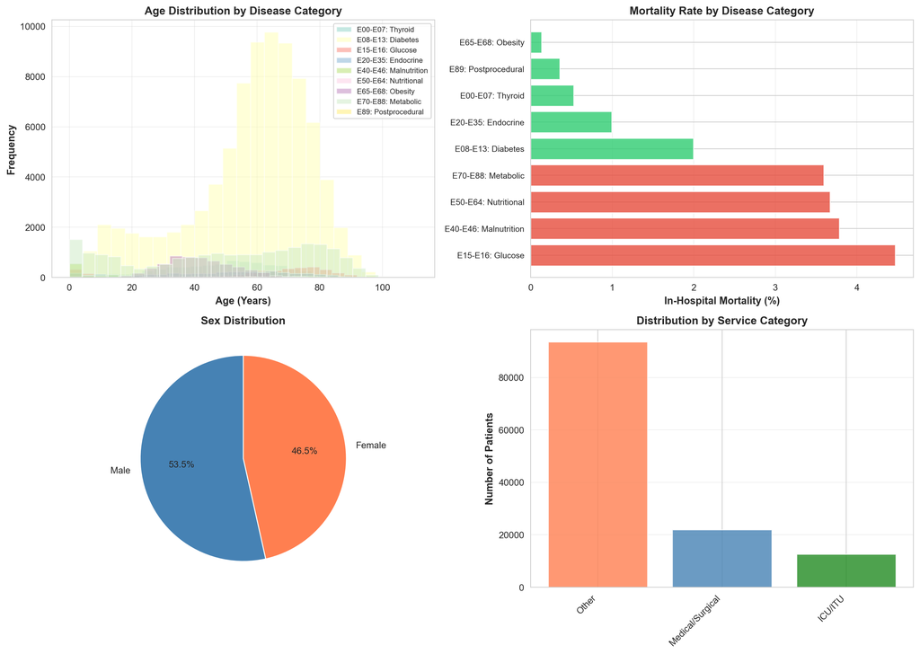

Figure 1: Demographic characteristics by endocrine disease category

```python
fig, axes = plt.subplots(2, 2, figsize=(14, 10))

# Age distribution by category - ALL categories shown
categories_list = sorted([c for c in df_endocrinas['endocrine_category'].unique() if pd.notna(c)])
colors_list = plt.cm.Set3(np.linspace(0, 1, len(categories_list)))
for i, category in enumerate(categories_list):
    data = df_endocrinas[df_endocrinas['endocrine_category'] == category]['age']
    axes[0, 0].hist(data, alpha=0.5, label=category, bins=25, color=colors_list[i])
axes[0, 0].set_xlabel('Age (Years)', fontweight='bold', fontsize=11)
axes[0, 0].set_ylabel('Frequency', fontweight='bold', fontsize=11)
axes[0, 0].set_title('Age Distribution by Disease Category', fontweight='bold', fontsize=12)
axes[0, 0].legend(fontsize=8, loc='upper right')
axes[0, 0].grid(True, alpha=0.3)

# Mortality by category
mortality_by_cat = df_endocrinas.groupby('endocrine_category')['mortality'].agg(['sum', 'count'])
mortality_by_cat['pct'] = 100 * mortality_by_cat['sum'] / mortality_by_cat['count']
mortality_by_cat = mortality_by_cat.sort_values('pct', ascending=False)
colors_mort = ['#e74c3c' if p > df_endocrinas['mortality'].mean()*100 else '#2ecc71' for p in mortality_by_cat['pct']]
axes[0, 1].barh(range(len(mortality_by_cat)), mortality_by_cat['pct'], color=colors_mort, alpha=0.8)
axes[0, 1].set_yticks(range(len(mortality_by_cat)))
axes[0, 1].set_yticklabels(mortality_by_cat.index, fontsize=9)
axes[0, 1].set_xlabel('In-Hospital Mortality (%)', fontweight='bold', fontsize=11)
axes[0, 1].set_title('Mortality Rate by Disease Category', fontweight='bold', fontsize=12)
axes[0, 1].grid(True, alpha=0.3, axis='x')

# Gender distribution
gender_counts = df_endocrinas['male'].map({1: 'Male', 0: 'Female'}).value_counts()
axes[1, 0].pie(gender_counts.values, labels=gender_counts.index, autopct='%1.1f%%',
               colors=['steelblue', 'coral'], startangle=90)
axes[1, 0].set_title('Sex Distribution', fontweight='bold', fontsize=12)

# Service category
service_counts = df_endocrinas['service_category'].value_counts()
service_labels = [format_name(f'service_{s.replace("/", "_").upper()}') if s != 'Other' else s for s in service_counts.index]
axes[1, 1].bar(range(len(service_counts)), service_counts.values, color=['coral', 'steelblue', 'forestgreen'][:len(service_counts)], alpha=0.8)
axes[1, 1].set_xticks(range(len(service_counts)))
axes[1, 1].set_xticklabels(service_counts.index, rotation=45, ha='right')
axes[1, 1].set_ylabel('Number of Patients', fontweight='bold', fontsize=11)
axes[1, 1].set_title('Distribution by Service Category', fontweight='bold', fontsize=12)
axes[1, 1].grid(True, alpha=0.3, axis='y')

plt.tight_layout()
plt.savefig('../data/output_files/endocrinas_parte2/fig_demographics.png', dpi=1200, bbox_inches='tight')
plt.show()
```

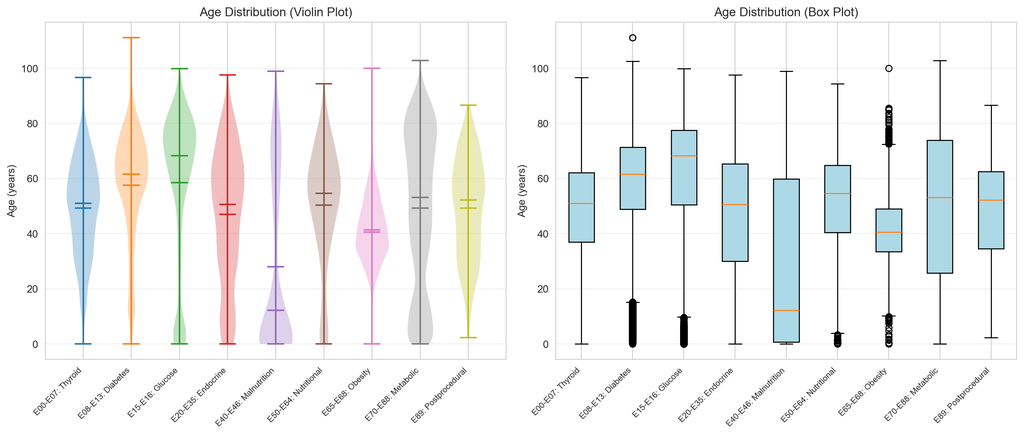

Figure 2: Figure 2. Age Distribution by Disease Category

```python
fig, axes = plt.subplots(1, 2, figsize=(14, 6))

categories_sorted = sorted(df_endocrinas['endocrine_category'].dropna().unique())

# Violin plot
ax = axes[0]
for i, cat in enumerate(categories_sorted):
    data = df_endocrinas[df_endocrinas['endocrine_category'] == cat]['age'].dropna()
    ax.violinplot([data], positions=[i], widths=0.7, showmeans=True, showmedians=True)
ax.set_xticks(range(len(categories_sorted)))
ax.set_xticklabels(categories_sorted, rotation=45, ha='right', fontsize=8)
ax.set_ylabel('Age (years)')
ax.set_title('Age Distribution (Violin Plot)')
ax.grid(True, alpha=0.3, axis='y')

# Box plot
ax = axes[1]
data_by_cat = [df_endocrinas[df_endocrinas['endocrine_category'] == cat]['age'].dropna().values
               for cat in categories_sorted]
bp = ax.boxplot(data_by_cat, labels=categories_sorted, patch_artist=True)
for patch in bp['boxes']:
    patch.set_facecolor('lightblue')
ax.set_ylabel('Age (years)')
ax.set_title('Age Distribution (Box Plot)')
ax.set_xticklabels(categories_sorted, rotation=45, ha='right', fontsize=8)
ax.grid(True, alpha=0.3, axis='y')

plt.tight_layout()
plt.savefig('../data/output_files/endocrinas_parte2/fig_age_by_category.png', dpi=1200, bbox_inches='tight')
plt.show()
```

```python
# Table 2: Yearly Trends by Disease Category
trend_data = []
for year in sorted(df_endocrinas['year'].unique()):
    for cat in sorted(df_endocrinas['endocrine_category'].dropna().unique()):
        subset = df_endocrinas[(df_endocrinas['year'] == year) & (df_endocrinas['endocrine_category'] == cat)]

        if len(subset) >= 5:
            trend_data.append({
                'Year': int(year),
                'Category': cat,
                'N': f"{len(subset):,}",
                'Mortality %': f"{100 * subset['mortality'].mean():.2f}",
                'Mean Age': f"{subset['age'].mean():.1f}",
                'Mean LOS': f"{subset['length_of_stay'].mean():.1f}",
                'Any Comorbidity %': f"{100 * (subset['total_comorbidities'] > 0).mean():.1f}"
            })

table2_df = pd.DataFrame(trend_data)
show_table(table2_df, "Table 2: Trends by Year and Category")
```

Table 2: Trends by Year and Category

| Year | Category | N | Mortality % | Mean Age | Mean LOS | Any Comorbidity % |
| --- | --- | --- | --- | --- | --- | --- |
| 2019 | E00-E07: Thyroid | 1,802 | 0.33 | 50.8 | 3.9 | 53.5 |
| 2019 | E08-E13: Diabetes | 14,631 | 2.05 | 57.9 | 10.6 | 75.5 |
| 2019 | E15-E16: Glucose | 999 | 4.60 | 62.0 | 5.4 | 87.7 |
| 2019 | E20-E35: Endocrine | 659 | 0.91 | 44.9 | 8.0 | 63.7 |
| 2019 | E40-E46: Malnutrition | 300 | 5.33 | 32.3 | 13.3 | 55.7 |
| 2019 | E50-E64: Nutritional | 85 | 3.53 | 48.7 | 10.0 | 82.4 |
| 2019 | E65-E68: Obesity | 1,723 | 0.06 | 40.9 | 3.1 | 67.2 |
| 2019 | E70-E88: Metabolic | 4,779 | 3.43 | 45.0 | 5.1 | 61.7 |
| 2019 | E89: Postprocedural | 51 | 1.96 | 50.0 | 8.6 | 62.7 |
| 2020 | E00-E07: Thyroid | 850 | 1.06 | 48.0 | 4.6 | 58.1 |
| 2020 | E08-E13: Diabetes | 11,562 | 2.47 | 57.1 | 10.2 | 78.8 |
| 2020 | E15-E16: Glucose | 558 | 5.56 | 61.8 | 6.2 | 87.6 |
| 2020 | E20-E35: Endocrine | 427 | 0.47 | 47.3 | 10.3 | 71.9 |
| 2020 | E40-E46: Malnutrition | 177 | 2.26 | 28.7 | 13.7 | 62.1 |
| 2020 | E50-E64: Nutritional | 76 | 1.32 | 48.8 | 30.2 | 92.1 |
| 2020 | E65-E68: Obesity | 777 | 0.00 | 39.5 | 3.0 | 75.7 |
| 2020 | E70-E88: Metabolic | 2,529 | 3.72 | 50.0 | 7.1 | 73.8 |
| 2020 | E89: Postprocedural | 37 | 0.00 | 48.0 | 7.2 | 45.9 |
| 2021 | E00-E07: Thyroid | 783 | 0.64 | 46.6 | 5.6 | 62.6 |
| 2021 | E08-E13: Diabetes | 12,626 | 2.30 | 55.8 | 10.1 | 78.6 |
| 2021 | E15-E16: Glucose | 449 | 4.68 | 57.5 | 7.0 | 86.6 |
| 2021 | E20-E35: Endocrine | 482 | 1.24 | 45.3 | 10.1 | 68.5 |
| 2021 | E40-E46: Malnutrition | 188 | 3.19 | 27.3 | 19.4 | 64.9 |
| 2021 | E50-E64: Nutritional | 78 | 3.85 | 45.7 | 17.5 | 89.7 |
| 2021 | E65-E68: Obesity | 517 | 0.39 | 40.7 | 3.4 | 74.7 |
| 2021 | E70-E88: Metabolic | 2,712 | 3.98 | 48.8 | 7.5 | 75.5 |
| 2021 | E89: Postprocedural | 45 | 0.00 | 47.8 | 5.7 | 71.1 |
| 2022 | E00-E07: Thyroid | 1,149 | 0.87 | 48.9 | 4.9 | 60.2 |
| 2022 | E08-E13: Diabetes | 13,941 | 2.15 | 57.5 | 10.7 | 79.9 |
| 2022 | E15-E16: Glucose | 570 | 3.68 | 55.1 | 6.7 | 83.0 |
| 2022 | E20-E35: Endocrine | 578 | 1.21 | 46.9 | 10.5 | 73.2 |
| 2022 | E40-E46: Malnutrition | 223 | 4.48 | 27.0 | 15.8 | 63.2 |
| 2022 | E50-E64: Nutritional | 86 | 6.98 | 53.3 | 14.0 | 91.9 |
| 2022 | E65-E68: Obesity | 823 | 0.24 | 41.6 | 2.6 | 70.0 |
| 2022 | E70-E88: Metabolic | 3,140 | 3.82 | 49.1 | 6.8 | 73.7 |
| 2022 | E89: Postprocedural | 41 | 0.00 | 48.8 | 4.8 | 63.4 |
| 2023 | E00-E07: Thyroid | 1,319 | 0.45 | 50.1 | 4.4 | 62.5 |
| 2023 | E08-E13: Diabetes | 14,729 | 1.72 | 58.1 | 10.8 | 81.8 |
| 2023 | E15-E16: Glucose | 519 | 3.47 | 56.1 | 6.2 | 85.9 |
| 2023 | E20-E35: Endocrine | 633 | 0.95 | 49.5 | 9.2 | 77.1 |
| 2023 | E40-E46: Malnutrition | 274 | 4.01 | 25.1 | 17.7 | 69.3 |
| 2023 | E50-E64: Nutritional | 71 | 2.82 | 52.9 | 13.7 | 93.0 |
| 2023 | E65-E68: Obesity | 972 | 0.10 | 43.1 | 2.7 | 76.1 |
| 2023 | E70-E88: Metabolic | 3,507 | 3.05 | 50.4 | 6.7 | 76.9 |
| 2023 | E89: Postprocedural | 57 | 0.00 | 52.1 | 6.6 | 63.2 |
| 2024 | E00-E07: Thyroid | 1,306 | 0.15 | 49.4 | 4.1 | 65.1 |
| 2024 | E08-E13: Diabetes | 16,007 | 1.48 | 58.3 | 10.0 | 82.0 |
| 2024 | E15-E16: Glucose | 551 | 4.72 | 55.6 | 6.2 | 86.2 |
| 2024 | E20-E35: Endocrine | 745 | 1.07 | 47.7 | 8.9 | 74.9 |
| 2024 | E40-E46: Malnutrition | 264 | 2.65 | 27.2 | 12.6 | 73.5 |
| 2024 | E50-E64: Nutritional | 94 | 3.19 | 52.1 | 14.9 | 90.4 |
| 2024 | E65-E68: Obesity | 1,168 | 0.17 | 42.3 | 2.7 | 80.1 |
| 2024 | E70-E88: Metabolic | 3,940 | 3.76 | 53.3 | 5.8 | 77.3 |
| 2024 | E89: Postprocedural | 49 | 0.00 | 48.0 | 6.9 | 65.3 |

```python
# Table 3: Discharge Status Summary
discharge_summary = []
for status_val, status_label in [(0, 'Discharged'), (1, 'Deceased')]:
    status_data = df_endocrinas[df_endocrinas['mortality'] == status_val]
    total_n = len(status_data)

    discharge_summary.append({
        'Status': status_label,
        'N': f"{total_n:,}",
        '%': f"{100 * total_n / len(df_endocrinas):.1f}",
        'Mean Age': f"{status_data['age'].mean():.1f}",
        'Female %': f"{100 * (1 - status_data['male']).mean():.1f}",
        'Mean LOS': f"{status_data['length_of_stay'].mean():.1f}",
        'Median LOS': f"{status_data['length_of_stay'].median():.1f}"
    })

table3_df = pd.DataFrame(discharge_summary)
show_table(table3_df, "Table 3: Summary by Discharge Status")
```

Table 3: Summary by Discharge Status

| Status | N | % | Mean Age | Female % | Mean LOS | Median LOS |
| --- | --- | --- | --- | --- | --- | --- |
| Discharged | 125,304 | 97.9 | 54.0 | 46.6 | 8.8 | 5.0 |
| Deceased | 2,748 | 2.1 | 70.3 | 42.6 | 15.1 | 6.0 |

```python
# Table 4: Length of Stay by Category and Discharge Status
los_by_status = []
for cat in sorted(df_endocrinas['endocrine_category'].dropna().unique()):
    for status_val, status_label in [(0, 'Discharged'), (1, 'Deceased')]:
        subset = df_endocrinas[(df_endocrinas['endocrine_category'] == cat) & (df_endocrinas['mortality'] == status_val)]

        if len(subset) >= 3:
            los_by_status.append({
                'Category': cat,
                'Status': status_label,
                'N': f"{len(subset):,}",
                'Mean LOS': f"{subset['length_of_stay'].mean():.1f}",
                'Median LOS': f"{subset['length_of_stay'].median():.1f}",
                'IQR': f"{subset['length_of_stay'].quantile(0.25):.1f}-{subset['length_of_stay'].quantile(0.75):.1f}"
            })

table4_df = pd.DataFrame(los_by_status)
show_table(table4_df, "Table 4: Length of Stay by Category and Discharge Status")
```

Table 4: Length of Stay by Category and Discharge Status

| Category | Status | N | Mean LOS | Median LOS | IQR |
| --- | --- | --- | --- | --- | --- |
| E00-E07: Thyroid | Discharged | 7,171 | 4.4 | 3.0 | 1.0-5.0 |
| E00-E07: Thyroid | Deceased | 38 | 10.4 | 7.5 | 2.0-15.2 |
| E08-E13: Diabetes | Discharged | 81,829 | 10.2 | 6.0 | 2.0-12.0 |
| E08-E13: Diabetes | Deceased | 1,667 | 18.6 | 9.0 | 2.0-24.0 |
| E15-E16: Glucose | Discharged | 3,483 | 5.9 | 3.0 | 2.0-6.0 |
| E15-E16: Glucose | Deceased | 163 | 10.8 | 3.0 | 1.0-9.5 |
| E20-E35: Endocrine | Discharged | 3,489 | 9.4 | 6.0 | 2.0-11.0 |
| E20-E35: Endocrine | Deceased | 35 | 13.0 | 9.0 | 2.5-15.0 |
| E40-E46: Malnutrition | Discharged | 1,372 | 15.2 | 8.0 | 4.0-16.0 |
| E40-E46: Malnutrition | Deceased | 54 | 15.5 | 6.5 | 1.0-12.0 |
| E50-E64: Nutritional | Discharged | 472 | 16.0 | 8.0 | 5.0-15.0 |
| E50-E64: Nutritional | Deceased | 18 | 28.9 | 21.0 | 5.5-35.8 |
| E65-E68: Obesity | Discharged | 5,972 | 2.9 | 2.0 | 1.0-3.0 |
| E65-E68: Obesity | Deceased | 8 | 6.8 | 6.0 | 3.8-7.8 |
| E70-E88: Metabolic | Discharged | 19,866 | 6.2 | 3.0 | 1.0-7.0 |
| E70-E88: Metabolic | Deceased | 741 | 8.7 | 3.0 | 1.0-9.0 |
| E89: Postprocedural | Discharged | 279 | 6.7 | 5.0 | 3.0-8.0 |

```python
# Table 5: Yearly Summary
yearly_summary = []
for year in sorted(df_endocrinas['year'].unique()):
    year_data = df_endocrinas[df_endocrinas['year'] == year]

    yearly_summary.append({
        'Year': int(year),
        'Total': f"{len(year_data):,}",
        'Discharged': f"{(year_data['mortality'] == 0).sum():,}",
        'Deceased': f"{(year_data['mortality'] == 1).sum():,}",
        'Mortality %': f"{100 * year_data['mortality'].mean():.2f}",
        'Mean LOS': f"{year_data['length_of_stay'].mean():.1f}"
    })

table5_df = pd.DataFrame(yearly_summary)
show_table(table5_df, "Table 5: Yearly Trends (Total, Discharged, Deceased, Mortality %, Mean LOS)")
```

Table 5: Yearly Trends (Total, Discharged, Deceased, Mortality %, Mean LOS)

| Year | Total | Discharged | Deceased | Mortality % | Mean LOS |
| --- | --- | --- | --- | --- | --- |
| 2019 | 25,279 | 24,729 | 550 | 2.18 | 8.3 |
| 2020 | 17,286 | 16,851 | 435 | 2.52 | 9.1 |
| 2021 | 18,073 | 17,629 | 444 | 2.46 | 9.3 |
| 2022 | 20,758 | 20,281 | 477 | 2.30 | 9.3 |
| 2023 | 22,312 | 21,905 | 407 | 1.82 | 9.3 |
| 2024 | 24,344 | 23,909 | 435 | 1.79 | 8.5 |

```python
# Table 6: Mean LOS by Category and Comorbidity
los_by_comorbidity = []
for cat in sorted(df_endocrinas['endocrine_category'].dropna().unique()):
    cat_data = df_endocrinas[df_endocrinas['endocrine_category'] == cat]

    row = {'Category': cat}
    for comor_col in sorted(comor_cols):
        comor_short = comor_col.replace('comor_', '').replace('_', ' ')
        with_comor = cat_data[cat_data[comor_col] == 1]['length_of_stay'].mean()
        row[comor_short] = f"{with_comor:.1f}" if pd.notna(with_comor) else "—"

    los_by_comorbidity.append(row)

table6_df = pd.DataFrame(los_by_comorbidity)
show_table(table6_df, "Table 6: Mean LOS by Category and Comorbidity")
```

Table 6: Mean LOS by Category and Comorbidity

| Category | alcohol related | cardiovascular | diabetes glucose | dyslipidemia metabolic | gastrointestinal | hypertension | liver disease nonalcoholic | mental health | musculoskeletal | nutritional deficiencies | obesity overweight | sleep disorders | substance use | tobacco related |
| --- | --- | --- | --- | --- | --- | --- | --- | --- | --- | --- | --- | --- | --- | --- |
| E00-E07: Thyroid | 8.0 | 11.3 | 4.8 | 4.5 | 10.0 | 4.8 | 12.3 | 6.2 | 6.0 | 13.4 | 5.1 | 7.2 | 10.0 | 5.9 |
| E08-E13: Diabetes | 13.1 | 16.6 | 14.3 | 11.9 | 16.3 | 11.8 | 12.9 | 13.9 | 13.6 | 18.3 | 11.6 | 16.3 | 9.0 | 11.8 |
| E15-E16: Glucose | 8.9 | 6.4 | 5.3 | 6.4 | 12.1 | 5.6 | 8.3 | 8.4 | 7.2 | 10.5 | 6.5 | 7.1 | 11.5 | 6.7 |
| E20-E35: Endocrine | 13.2 | 14.6 | 10.7 | 10.1 | 17.7 | 11.1 | 12.7 | 11.8 | 12.6 | 16.7 | 9.2 | 11.9 | 12.3 | 12.2 |
| E40-E46: Malnutrition | 19.5 | 15.4 | 12.4 | 19.4 | 22.1 | 16.5 | 22.7 | 17.8 | 41.4 | 22.8 | 14.8 | 18.1 | 19.5 | 21.2 |
| E50-E64: Nutritional | 21.2 | 13.5 | 12.4 | 19.9 | 21.2 | 13.8 | 18.0 | 14.2 | 10.0 | 20.6 | 11.6 | 15.9 | 49.6 | 16.4 |
| E65-E68: Obesity | 2.6 | 13.2 | 3.6 | 2.7 | 2.8 | 4.1 | 2.5 | 4.4 | 3.6 | 11.0 | 7.3 | 9.6 | 5.1 | 3.9 |
| E70-E88: Metabolic | 11.2 | 7.1 | 7.1 | 7.4 | 12.1 | 6.3 | 10.0 | 9.3 | 10.0 | 14.5 | 7.4 | 6.8 | 9.3 | 8.1 |
| E89: Postprocedural | 9.1 | 14.2 | 7.4 | 7.8 | 6.5 | 9.1 | 7.4 | 6.2 | 5.5 | 7.3 | 8.3 | 10.4 | 4.5 | 7.6 |

```python
# Table 7: Comorbidity Impact on LOS
comor_impact = []
for col in sorted(comor_cols):
    comor_display = format_name(col)
    los_with = df_endocrinas[df_endocrinas[col] == 1]['length_of_stay'].mean()
    los_without = df_endocrinas[df_endocrinas[col] == 0]['length_of_stay'].mean()
    difference = los_with - los_without

    comor_impact.append({
        'Comorbidity': comor_display,
        'N WITH': f"{(df_endocrinas[col] == 1).sum():,}",
        'Mean LOS WITH': f"{los_with:.1f}",
        'Mean LOS WITHOUT': f"{los_without:.1f}",
        'Difference': f"{difference:.1f}"
    })

table7_df = pd.DataFrame(comor_impact).sort_values('Difference', ascending=False, key=lambda x: pd.to_numeric(x.str.replace(',', ''), errors='coerce'))
show_table(table7_df, "Table 7: LOS Impact (Difference WITH - WITHOUT comorbidity)")
```

Table 7: LOS Impact (Difference WITH - WITHOUT comorbidity)

| Comorbidity | N WITH | Mean LOS WITH | Mean LOS WITHOUT | Difference |
| --- | --- | --- | --- | --- |
| Nutritional Deficiencies | 6,189 | 16.5 | 8.5 | 8.0 |
| Cardiovascular | 21,838 | 14.9 | 7.7 | 7.2 |
| Gastrointestinal | 5,571 | 13.7 | 8.7 | 5.0 |
| Alcohol Related | 7,689 | 12.0 | 8.7 | 3.3 |
| Hypertension | 67,781 | 10.4 | 7.3 | 3.1 |
| Mental Health | 6,203 | 11.8 | 8.8 | 3.1 |
| Musculoskeletal | 2,125 | 11.6 | 8.9 | 2.7 |
| Sleep Disorders | 1,239 | 11.1 | 8.9 | 2.2 |
| Diabetes | 25,437 | 10.4 | 8.6 | 1.8 |
| Tobacco Related | 17,558 | 10.3 | 8.7 | 1.7 |
| Dyslipidemia | 17,529 | 10.3 | 8.7 | 1.6 |
| Obesity/Overweight | 12,109 | 10.3 | 8.8 | 1.5 |
| Substance Use | 2,536 | 9.9 | 8.9 | 1.0 |
| Liver Disease | 4,760 | 9.1 | 8.9 | 0.2 |

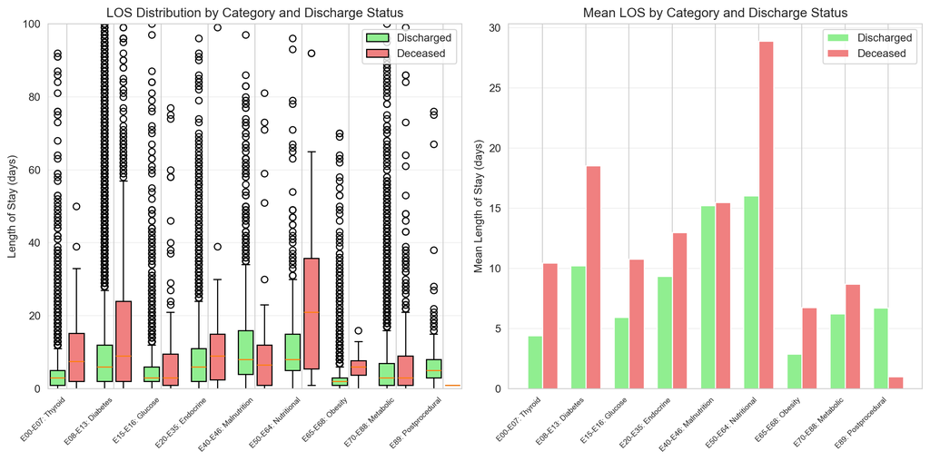

Figure 3: Figure 5. Length of Stay by Disease Category and Discharge Status

```python
fig, axes = plt.subplots(1, 2, figsize=(12, 6))
categories_sorted = sorted(df_endocrinas['endocrine_category'].dropna().unique())

# Box plot
ax = axes[0]
data_discharged = []
data_deceased = []
labels = []
for cat in categories_sorted:
    df_cat = df_endocrinas[df_endocrinas['endocrine_category'] == cat]
    data_discharged.append(df_cat[df_cat['mortality'] == 0]['length_of_stay'].values)
    data_deceased.append(df_cat[df_cat['mortality'] == 1]['length_of_stay'].values)
    labels.append(cat)

positions_dis = np.arange(len(labels)) * 2.5
positions_dec = positions_dis + 1
bp1 = ax.boxplot(data_discharged, positions=positions_dis, widths=0.8, patch_artist=True, label='Discharged')
bp2 = ax.boxplot(data_deceased, positions=positions_dec, widths=0.8, patch_artist=True, label='Deceased')
for patch in bp1['boxes']:
    patch.set_facecolor('lightgreen')
for patch in bp2['boxes']:
    patch.set_facecolor('lightcoral')
ax.set_xticks((positions_dis + positions_dec) / 2)
ax.set_xticklabels(labels, rotation=45, ha='right', fontsize=7)
ax.set_ylabel('Length of Stay (days)')
ax.set_title('LOS Distribution by Category and Discharge Status')
ax.set_ylim([0, 100])
ax.legend()
ax.grid(True, alpha=0.3, axis='y')

# Bar plot of means
ax = axes[1]
means_dis = [df_endocrinas[(df_endocrinas['endocrine_category'] == cat) & (df_endocrinas['mortality'] == 0)]['length_of_stay'].mean() for cat in categories_sorted]
means_dec = [df_endocrinas[(df_endocrinas['endocrine_category'] == cat) & (df_endocrinas['mortality'] == 1)]['length_of_stay'].mean() for cat in categories_sorted]
x = np.arange(len(labels))
width = 0.35
ax.bar(x - width/2, means_dis, width, label='Discharged', color='lightgreen')
ax.bar(x + width/2, means_dec, width, label='Deceased', color='lightcoral')
ax.set_ylabel('Mean Length of Stay (days)')
ax.set_title('Mean LOS by Category and Discharge Status')
ax.set_xticks(x)
ax.set_xticklabels(labels, rotation=45, ha='right', fontsize=7)
ax.legend()
ax.grid(True, alpha=0.3, axis='y')

plt.tight_layout()
plt.savefig('../data/output_files/endocrinas_parte2/fig_los_by_category.png', dpi=1200, bbox_inches='tight')
plt.show()
```

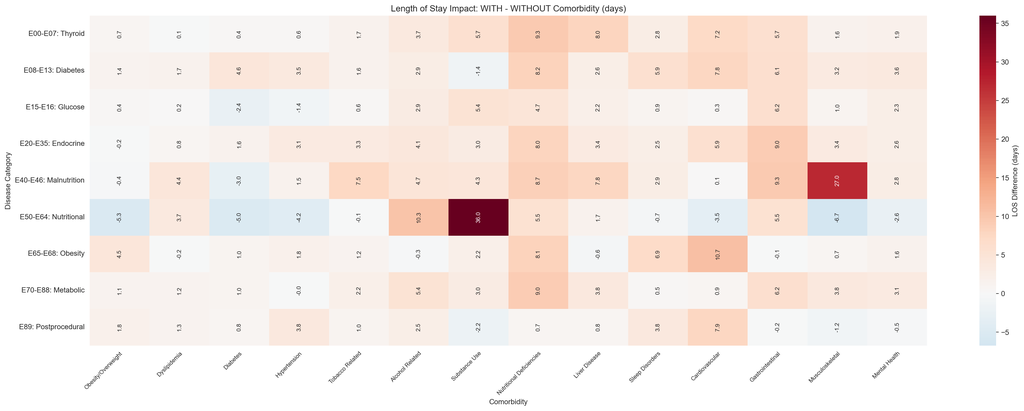

Figure 4: Figure 6. Heatmap: LOS Impact by Comorbidity and Disease Category

```python
heatmap_los_impact = []
for cat in categories_sorted:
    df_cat = df_endocrinas[df_endocrinas['endocrine_category'] == cat]
    row = []
    for col in comor_cols:
        df_with = df_cat[df_cat[col] == 1]
        df_without = df_cat[df_cat[col] == 0]
        los_with = df_with['length_of_stay'].mean() if len(df_with) > 0 else 0
        los_without = df_without['length_of_stay'].mean() if len(df_without) > 0 else 0
        row.append(los_with - los_without)
    heatmap_los_impact.append(row)

heatmap_los_impact_df = pd.DataFrame(heatmap_los_impact, index=categories_sorted,
                                      columns=[format_name(col) for col in comor_cols])

fig, ax = plt.subplots(figsize=(22, 8))
sns.heatmap(heatmap_los_impact_df, annot=True, fmt='.1f', cmap='RdBu_r', center=0,
            cbar_kws={'label': 'LOS Difference (days)'}, ax=ax,
            annot_kws={'rotation': 90, 'fontsize': 8})
ax.set_title('Length of Stay Impact: WITH - WITHOUT Comorbidity (days)')
ax.set_xlabel('Comorbidity')
ax.set_ylabel('Disease Category')
plt.setp(ax.get_xticklabels(), rotation=45, ha='right', rotation_mode='anchor', fontsize=8)
plt.setp(ax.get_yticklabels(), rotation=0)
plt.tight_layout()
plt.savefig('../data/output_files/endocrinas_parte2/fig_los_impact_heatmap.png', dpi=1200, bbox_inches='tight', facecolor='white')
plt.show()
```

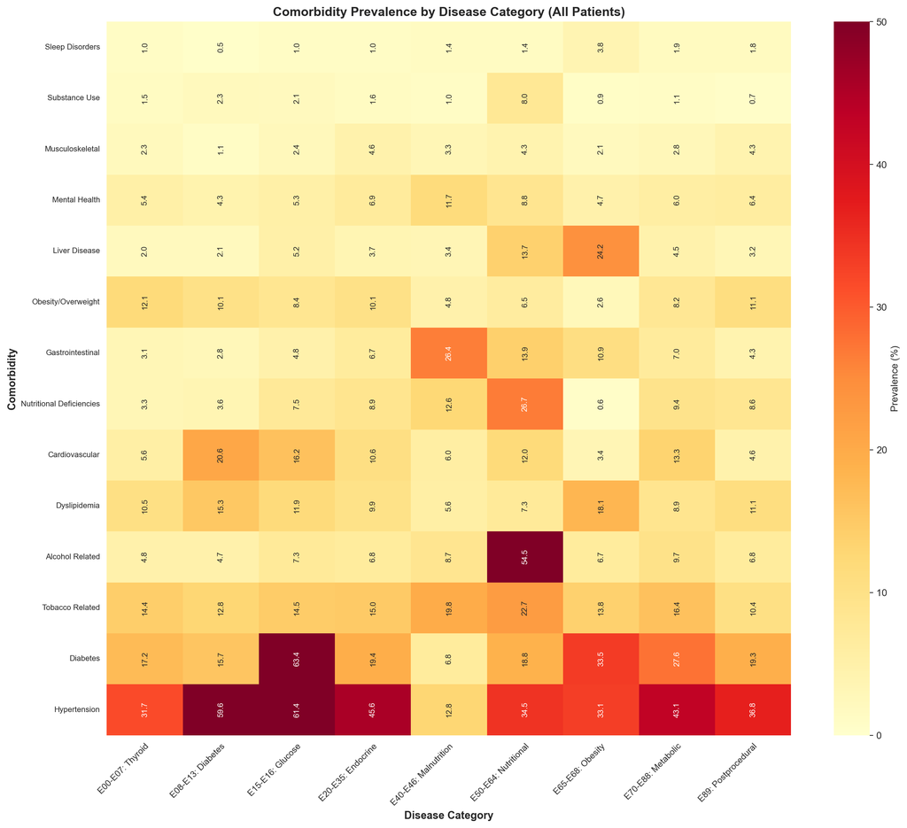

Figure 5: Comorbidity prevalence heatmap by endocrine disease category (all patients)

```python
fig, ax = plt.subplots(figsize=(14, 12))

# Build comorbidity matrix
categories_for_heatmap = [c for c in df_endocrinas['endocrine_category'].unique() if pd.notna(c) and df_endocrinas[df_endocrinas['endocrine_category'] == c].shape[0] >= 20]
comor_by_cat = pd.DataFrame()

for category in sorted(categories_for_heatmap):
    cat_data = df_endocrinas[df_endocrinas['endocrine_category'] == category][comor_cols].mean() * 100
    cat_data.index = [format_name(col) for col in comor_cols]
    comor_by_cat[category] = cat_data

comor_by_cat = comor_by_cat.loc[comor_by_cat.mean(axis=1).sort_values(ascending=True).index]

sns.heatmap(comor_by_cat, annot=True, fmt='.1f', cmap='YlOrRd',
            cbar_kws={'label': 'Prevalence (%)'}, ax=ax, vmin=0, vmax=50,
            annot_kws={'rotation': 90, 'fontsize': 8})
ax.set_title('Comorbidity Prevalence by Disease Category (All Patients)', fontweight='bold', fontsize=13)
ax.set_xlabel('Disease Category', fontweight='bold', fontsize=11)
ax.set_ylabel('Comorbidity', fontweight='bold', fontsize=11)
plt.setp(ax.get_xticklabels(), rotation=45, ha='right', rotation_mode='anchor', fontsize=9)
plt.setp(ax.get_yticklabels(), rotation=0, fontsize=8)

plt.tight_layout()
plt.savefig('../data/output_files/endocrinas_parte2/fig_comorbidity_heatmap.png', dpi=1200, bbox_inches='tight', facecolor='white')
plt.show()
```

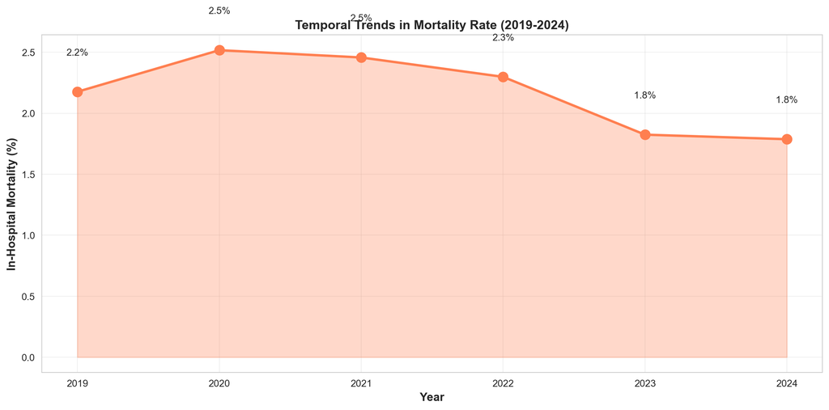

Figure 6: Temporal trends in in-hospital mortality rate (2019-2024)

```python
fig, ax = plt.subplots(figsize=(12, 6))

mortality_by_year = df_endocrinas.groupby('year')['mortality'].agg(['sum', 'count', 'mean'])
mortality_by_year['pct'] = mortality_by_year['mean'] * 100

ax.plot(mortality_by_year.index, mortality_by_year['pct'], marker='o', linewidth=2.5, markersize=10, color='coral')
ax.fill_between(mortality_by_year.index, mortality_by_year['pct'], alpha=0.3, color='coral')
ax.set_xlabel('Year', fontsize=12, fontweight='bold')
ax.set_ylabel('In-Hospital Mortality (%)', fontsize=12, fontweight='bold')
ax.set_title('Temporal Trends in Mortality Rate (2019-2024)', fontsize=13, fontweight='bold')
ax.grid(True, alpha=0.3)

for year, row in mortality_by_year.iterrows():
    ax.text(year, row['pct'] + 0.3, f"{row['pct']:.1f}%", ha='center', fontsize=10)

plt.tight_layout()
plt.savefig('../data/output_files/endocrinas_parte2/fig_mortality_trends.png', dpi=1200, bbox_inches='tight')
plt.show()
```

# 4 Bivariate Analysis

```python
# Table 8: Comorbidity Prevalence - All Patients
discharged = df_endocrinas[df_endocrinas['mortality'] == 0]
deceased = df_endocrinas[df_endocrinas['mortality'] == 1]

comor_prevalence_all = []
for col in sorted(comor_cols):
    total_with = (df_endocrinas[col] == 1).sum()
    pct = 100 * total_with / len(df_endocrinas)
    comor_prevalence_all.append({
        'Comorbidity': format_name(col),
        'N': f"{total_with:,}",
        'Prevalence %': f"{pct:.1f}"
    })

comor_prev_all_df = pd.DataFrame(comor_prevalence_all).sort_values('Prevalence %', ascending=False, key=lambda x: pd.to_numeric(x.str.rstrip('%'), errors='coerce'))
show_table(comor_prev_all_df, f"Table 8: Comorbidity Prevalence - All Patients (N={len(df_endocrinas):,})")
```

Table 8: Comorbidity Prevalence - All Patients (N=128,052)

| Comorbidity | N | Prevalence % |
| --- | --- | --- |
| Hypertension | 67,781 | 52.9 |
| Diabetes | 25,437 | 19.9 |
| Cardiovascular | 21,838 | 17.1 |
| Dyslipidemia | 17,529 | 13.7 |
| Tobacco Related | 17,558 | 13.7 |
| Obesity/Overweight | 12,109 | 9.5 |
| Alcohol Related | 7,689 | 6.0 |
| Mental Health | 6,203 | 4.8 |
| Nutritional Deficiencies | 6,189 | 4.8 |
| Gastrointestinal | 5,571 | 4.4 |
| Liver Disease | 4,760 | 3.7 |
| Substance Use | 2,536 | 2.0 |
| Musculoskeletal | 2,125 | 1.7 |
| Sleep Disorders | 1,239 | 1.0 |

```python
# Table 9: Comorbidity Prevalence - Discharged Patients
comor_prevalence_discharged = []
for col in sorted(comor_cols):
    total_with = (discharged[col] == 1).sum()
    pct = 100 * total_with / len(discharged) if len(discharged) > 0 else 0
    comor_prevalence_discharged.append({
        'Comorbidity': format_name(col),
        'N': f"{total_with:,}",
        'Prevalence %': f"{pct:.1f}"
    })

comor_prev_discharged_df = pd.DataFrame(comor_prevalence_discharged).sort_values('Prevalence %', ascending=False, key=lambda x: pd.to_numeric(x.str.rstrip('%'), errors='coerce'))
show_table(comor_prev_discharged_df, f"Table 9: Comorbidity Prevalence - Discharged (N={len(discharged):,})")
```

Table 9: Comorbidity Prevalence - Discharged (N=125,304)

| Comorbidity | N | Prevalence % |
| --- | --- | --- |
| Hypertension | 65,945 | 52.6 |
| Diabetes | 24,599 | 19.6 |
| Cardiovascular | 20,870 | 16.7 |
| Dyslipidemia | 17,204 | 13.7 |
| Tobacco Related | 17,069 | 13.6 |
| Obesity/Overweight | 11,882 | 9.5 |
| Alcohol Related | 7,443 | 5.9 |
| Mental Health | 6,110 | 4.9 |
| Nutritional Deficiencies | 5,906 | 4.7 |
| Gastrointestinal | 5,347 | 4.3 |
| Liver Disease | 4,549 | 3.6 |
| Substance Use | 2,478 | 2.0 |
| Musculoskeletal | 2,065 | 1.6 |
| Sleep Disorders | 1,206 | 1.0 |

```python
# Table 10: Comorbidity Prevalence - Deceased Patients
comor_prevalence_deceased = []
for col in sorted(comor_cols):
    total_with = (deceased[col] == 1).sum()
    pct = 100 * total_with / len(deceased) if len(deceased) > 0 else 0
    comor_prevalence_deceased.append({
        'Comorbidity': format_name(col),
        'N': f"{total_with:,}",
        'Prevalence %': f"{pct:.1f}"
    })

comor_prev_deceased_df = pd.DataFrame(comor_prevalence_deceased).sort_values('Prevalence %', ascending=False, key=lambda x: pd.to_numeric(x.str.rstrip('%'), errors='coerce'))
show_table(comor_prev_deceased_df, f"Table 10: Comorbidity Prevalence - Deceased (N={len(deceased):,})")
```

Table 10: Comorbidity Prevalence - Deceased (N=2,748)

| Comorbidity | N | Prevalence % |
| --- | --- | --- |
| Hypertension | 1,836 | 66.8 |
| Cardiovascular | 968 | 35.2 |
| Diabetes | 838 | 30.5 |
| Tobacco Related | 489 | 17.8 |
| Dyslipidemia | 325 | 11.8 |
| Nutritional Deficiencies | 283 | 10.3 |
| Alcohol Related | 246 | 9.0 |
| Obesity/Overweight | 227 | 8.3 |
| Gastrointestinal | 224 | 8.2 |
| Liver Disease | 211 | 7.7 |
| Mental Health | 93 | 3.4 |
| Musculoskeletal | 60 | 2.2 |
| Substance Use | 58 | 2.1 |
| Sleep Disorders | 33 | 1.2 |

```python
# Table 10B: Difference in Comorbidity Prevalence (Deceased - Discharged) with chi-square
comorb_diff = []
for cat in sorted(df_endocrinas['endocrine_category'].dropna().unique()):
    df_cat = df_endocrinas[df_endocrinas['endocrine_category'] == cat]
    row = {'Disease Category': cat}

    for col in comor_cols:
        df_dis = df_cat[df_cat['mortality'] == 0]
        df_dec = df_cat[df_cat['mortality'] == 1]

        prev_dis = (df_dis[col].mean() * 100) if len(df_dis) > 0 else 0
        prev_dec = (df_dec[col].mean() * 100) if len(df_dec) > 0 else 0
        diff = prev_dec - prev_dis

        try:
            contingency_table = pd.crosstab(df_cat['mortality'], df_cat[col])
            chi2, pval, dof, expected = chi2_contingency(contingency_table)
            sig_stars = '***' if pval < 0.001 else '**' if pval < 0.01 else '*' if pval < 0.05 else ''
        except:
            sig_stars = ''

        row[format_name(col)] = f'{diff:+.1f}%{sig_stars}'

    comorb_diff.append(row)

comorb_diff_df = pd.DataFrame(comorb_diff)
show_table(comorb_diff_df, "Table 10B: Difference in Comorbidity Prevalence (Deceased - Discharged, %)\n* p<0.05, ** p<0.01, *** p<0.001", index=False)
```

Table 10B: Difference in Comorbidity Prevalence (Deceased - Discharged, %) * p<0.05, ** p<0.01, *** p<0.001

| Disease Category | Obesity/Overweight | Dyslipidemia | Diabetes | Hypertension | Tobacco Related | Alcohol Related | Substance Use | Nutritional Deficiencies | Liver Disease | Sleep Disorders | Cardiovascular | Gastrointestinal | Musculoskeletal | Mental Health |
| --- | --- | --- | --- | --- | --- | --- | --- | --- | --- | --- | --- | --- | --- | --- |
| E00-E07: Thyroid | -1.6% | -2.6% | +11.8% | +10.5% | +9.3% | +8.4%* | -1.5% | +7.3%* | +16.5%*** | +1.6% | +31.4%*** | +4.8% | +0.3% | -2.7% |
| E08-E13: Diabetes | -1.0% | -2.5%** | +9.8%*** | +15.2%*** | +4.8%*** | +3.0%*** | -0.4% | +4.7%*** | +4.5%*** | +0.5%** | +24.8%*** | +4.2%*** | +1.3%*** | -1.0% |
| E15-E16: Glucose | -1.8% | -4.8% | -7.2% | +3.1% | +8.0%** | +5.2%* | +4.3%*** | +6.9%** | +4.2%* | +0.2% | +4.2% | +0.1% | -0.6% | +0.2% |
| E20-E35: Endocrine | +1.4% | -10.0% | +3.5% | +14.5% | +2.2% | +7.6% | -1.6% | +16.9%** | +4.9% | +1.9% | +26.8%*** | +7.7% | -4.6% | -1.2% |
| E40-E46: Malnutrition | +0.8% | +3.8% | +6.4% | +11.8%* | +6.4% | +4.4% | +4.8%** | +2.3% | +2.2% | +0.5% | +5.4% | -8.2% | +2.3% | -2.5% |
| E50-E64: Nutritional | -6.8% | +9.7% | -2.2% | -12.7% | -0.4% | +24.2% | -2.5% | +12.6% | +3.1% | -1.5% | -1.0% | +14.4% | -4.4% | +2.4% |
| E65-E68: Obesity | +9.9% | +6.9% | -8.5% | +54.5%** | +11.2% | -6.7% | -0.9% | +11.9%* | -11.7% | +8.7% | +71.7%*** | -10.9% | -2.1% | +7.8% |
| E70-E88: Metabolic | -1.8% | +2.6%* | +12.3%*** | +13.3%*** | +0.2% | -0.9% | +0.4% | +3.4%** | +5.0%*** | -0.6% | +5.8%*** | +3.3%*** | -1.0% | -3.8%*** |
| E89: Postprocedural | -11.1% | -11.1% | -19.4% | -36.9% | -10.4% | -6.8% | -0.7% | -8.6% | +97.1%** | -1.8% | -4.7% | +96.1%* | -4.3% | -6.5% |

```python
# Table 11: Bivariate Associations - Comorbidities and Mortality
comor_associations = []

for col in sorted(comor_cols):
    if df_endocrinas[col].sum() > 5:
        contingency = pd.crosstab(df_endocrinas[col], df_endocrinas['mortality'])

        try:
            expected_freq = pd.crosstab(df_endocrinas[col], df_endocrinas['mortality'], margins=True).iloc[:-1, :-1].values
            if (expected_freq >= 5).all():
                chi2, p, dof, _ = chi2_contingency(contingency)
            else:
                try:
                    _, p = fisher_exact([[contingency.iloc[0,0], contingency.iloc[0,1]],
                                         [contingency.iloc[1,0], contingency.iloc[1,1]]])
                except:
                    p = np.nan
        except:
            p = np.nan

        mortality_with = df_endocrinas[df_endocrinas[col] == 1]['mortality'].mean() * 100
        mortality_without = df_endocrinas[df_endocrinas[col] == 0]['mortality'].mean() * 100

        sig_star = ''
        if pd.notna(p):
            if p < 0.001:
                sig_star = '***'
            elif p < 0.01:
                sig_star = '**'
            elif p < 0.05:
                sig_star = '*'

        p_str = f"{p:.4f}" if pd.notna(p) else "—"

        comor_associations.append({
            'Comorbidity': format_name(col),
            'N WITH': f"{(df_endocrinas[col] == 1).sum():,}",
            'Mortality WITH %': f"{mortality_with:.1f}",
            'Mortality WITHOUT %': f"{mortality_without:.1f}",
            'p-value': p_str,
            'Sig': sig_star
        })

comor_assoc_df = pd.DataFrame(comor_associations)
show_table(comor_assoc_df, "Table 11: Bivariate Associations - Comorbidities and Mortality")

sig_comorbidities = [row['Comorbidity'] for _, row in comor_assoc_df.iterrows() if row['Sig'] != '']
```

Table 11: Bivariate Associations - Comorbidities and Mortality

| Comorbidity | N WITH | Mortality WITH % | Mortality WITHOUT % | p-value | Sig |
| --- | --- | --- | --- | --- | --- |
| Alcohol Related | 7,689 | 3.2 | 2.1 | 0.0000 | *** |
| Cardiovascular | 21,838 | 4.4 | 1.7 | 0.0000 | *** |
| Diabetes | 25,437 | 3.3 | 1.9 | 0.0000 | *** |
| Dyslipidemia | 17,529 | 1.9 | 2.2 | 0.0045 | ** |
| Gastrointestinal | 5,571 | 4.0 | 2.1 | 0.0000 | *** |
| Hypertension | 67,781 | 2.7 | 1.5 | 0.0000 | *** |
| Liver Disease | 4,760 | 4.4 | 2.1 | 0.0000 | *** |
| Mental Health | 6,203 | 1.5 | 2.2 | 0.0004 | *** |
| Musculoskeletal | 2,125 | 2.8 | 2.1 | 0.0359 | * |
| Nutritional Deficiencies | 6,189 | 4.6 | 2.0 | 0.0000 | *** |
| Obesity/Overweight | 12,109 | 1.9 | 2.2 | 0.0330 | * |
| Sleep Disorders | 1,239 | 2.7 | 2.1 | 0.2442 |  |
| Substance Use | 2,536 | 2.3 | 2.1 | 0.6702 |  |
| Tobacco Related | 17,558 | 2.8 | 2.0 | 0.0000 | *** |

[figure not shown]

Figure 7: P-values from bivariate tests of comorbidity-mortality associations

```python
fig, ax = plt.subplots(figsize=(12, 8))

comor_assoc_df_sorted = comor_assoc_df.copy()
comor_assoc_df_sorted['p_numeric'] = pd.to_numeric(comor_assoc_df_sorted['p-value'], errors='coerce')
comor_assoc_df_sorted = comor_assoc_df_sorted.dropna(subset=['p_numeric']).sort_values('p_numeric')
colors = ['coral' if p < 0.05 else '#95a5a6' for p in comor_assoc_df_sorted['p_numeric']]

ax.barh(range(len(comor_assoc_df_sorted)), -np.log10(comor_assoc_df_sorted['p_numeric']), color=colors, alpha=0.8)
ax.axvline(-np.log10(0.05), color='red', linestyle='--', linewidth=2, label='p=0.05 threshold')
ax.set_yticks(range(len(comor_assoc_df_sorted)))
ax.set_yticklabels(comor_assoc_df_sorted['Comorbidity'], fontsize=10)
ax.set_xlabel('-log10(p-value)', fontsize=11, fontweight='bold')
ax.set_title('Statistical Significance of Comorbidity-Mortality Associations', fontweight='bold', fontsize=12)
ax.legend(fontsize=10)
ax.grid(True, alpha=0.3, axis='x')

plt.tight_layout()
plt.savefig('../data/output_files/endocrinas_parte2/fig_bivariate_pvalues.png', dpi=1200, bbox_inches='tight')
plt.show()
```

# 5 5. Bivariate Analysis (Per Disease Category)

```python
from scipy.stats import chi2_contingency, ranksums

# Bivariate analysis: chi-square for mortality, Wilcoxon for LOS per disease category
all_categories = sorted(df_endocrinas['endocrine_category'].dropna().unique())
df_bivariate = []

for cat in all_categories:
    df_cat = df_endocrinas[df_endocrinas['endocrine_category'] == cat]

    if len(df_cat) < 30:
        continue

    for col in comor_cols:
        # Chi-square test for mortality association
        contingency = pd.crosstab(df_cat[col], df_cat['mortality'])
        try:
            chi2, pval_mort, dof, expected = chi2_contingency(contingency)
        except:
            pval_mort = np.nan

        # Wilcoxon rank-sum test for LOS difference
        group_with = df_cat[df_cat[col] == 1]['length_of_stay'].dropna()
        group_without = df_cat[df_cat[col] == 0]['length_of_stay'].dropna()
        try:
            if len(group_with) >= 5 and len(group_without) >= 5:
                stat, pval_los = ranksums(group_with, group_without)
            else:
                pval_los = np.nan
        except:
            pval_los = np.nan

        df_bivariate.append({
            'Disease Category': cat,
            'Comorbidity': format_name(col),
            'Chi-square p-value': pval_mort,
            'LOS p-value (Wilcoxon)': pval_los,
            'N with': len(group_with),
            'N without': len(group_without)
        })

df_bivariate = pd.DataFrame(df_bivariate)
show_table(df_bivariate, "Table 20: Bivariate Analysis by Disease Category", index=False)
```

Table 20: Bivariate Analysis by Disease Category

| Disease Category | Comorbidity | Chi-square p-value | LOS p-value (Wilcoxon) | N with | N without |
| --- | --- | --- | --- | --- | --- |
| E00-E07: Thyroid | Obesity/Overweight | 9.616182e-01 | 2.286992e-07 | 872 | 6337 |
| E00-E07: Thyroid | Dyslipidemia | 7.927259e-01 | 1.167726e-02 | 758 | 6451 |
| E00-E07: Thyroid | Diabetes | 8.915135e-02 | 5.370894e-05 | 1243 | 5966 |
| E00-E07: Thyroid | Hypertension | 2.248159e-01 | 2.334335e-08 | 2282 | 4927 |
| E00-E07: Thyroid | Tobacco Related | 1.623899e-01 | 2.435620e-06 | 1040 | 6169 |
| E00-E07: Thyroid | Alcohol Related | 4.309672e-02 | 1.744131e-05 | 348 | 6861 |
| E00-E07: Thyroid | Substance Use | 9.104909e-01 | 5.124204e-04 | 111 | 7098 |
| E00-E07: Thyroid | Nutritional Deficiencies | 3.920079e-02 | 1.291638e-51 | 236 | 6973 |
| E00-E07: Thyroid | Liver Disease | 2.491579e-11 | 5.069494e-22 | 144 | 7065 |
| E00-E07: Thyroid | Sleep Disorders | 8.667631e-01 | 8.123187e-02 | 75 | 7134 |
| E00-E07: Thyroid | Cardiovascular | 8.013966e-16 | 9.564535e-68 | 403 | 6806 |
| E00-E07: Thyroid | Gastrointestinal | 2.247473e-01 | 2.457357e-15 | 227 | 6982 |
| E00-E07: Thyroid | Musculoskeletal | 1.000000e+00 | 9.778642e-03 | 167 | 7042 |
| E00-E07: Thyroid | Mental Health | 6.992627e-01 | 4.878200e-04 | 386 | 6823 |
| E08-E13: Diabetes | Obesity/Overweight | 1.746257e-01 | 2.461406e-37 | 8468 | 75028 |
| E08-E13: Diabetes | Dyslipidemia | 4.765425e-03 | 1.357397e-23 | 12749 | 70747 |
| E08-E13: Diabetes | Diabetes | 2.814854e-27 | 6.581832e-280 | 13137 | 70359 |
| E08-E13: Diabetes | Hypertension | 9.710228e-36 | 9.685375e-206 | 49735 | 33761 |
| E08-E13: Diabetes | Tobacco Related | 6.285639e-09 | 4.958275e-28 | 10717 | 72779 |
| E08-E13: Diabetes | Alcohol Related | 1.779548e-08 | 4.851235e-45 | 3962 | 79534 |
| E08-E13: Diabetes | Substance Use | 3.176592e-01 | 6.500165e-04 | 1932 | 81564 |
| E08-E13: Diabetes | Nutritional Deficiencies | 3.654367e-24 | 9.625408e-206 | 3010 | 80486 |
| E08-E13: Diabetes | Liver Disease | 1.994049e-35 | 6.741689e-29 | 1766 | 81730 |
| E08-E13: Diabetes | Sleep Disorders | 7.676102e-03 | 2.465770e-16 | 437 | 83059 |
| E08-E13: Diabetes | Cardiovascular | 1.416137e-135 | 0.000000e+00 | 17235 | 66261 |
| E08-E13: Diabetes | Gastrointestinal | 3.060050e-24 | 3.658290e-86 | 2370 | 81126 |
| E08-E13: Diabetes | Musculoskeletal | 5.703440e-07 | 3.067874e-13 | 921 | 82575 |
| E08-E13: Diabetes | Mental Health | 6.021956e-02 | 1.487141e-45 | 3603 | 79893 |
| E15-E16: Glucose | Obesity/Overweight | 5.131026e-01 | 1.748354e-02 | 308 | 3338 |
| E15-E16: Glucose | Dyslipidemia | 8.760078e-02 | 3.549204e-03 | 434 | 3212 |

[output cut: 96 more lines]

```python
# Build dictionaries of significant comorbidities per category (p < 0.05)
display_to_col = {format_name(c): c for c in comor_cols}

sig_comorbidities_mortality = {}
sig_comorbidities_los = {}

for cat in all_categories:
    cat_biv = df_bivariate[df_bivariate['Disease Category'] == cat]
    sig_mort = []
    sig_los = []
    for _, row in cat_biv.iterrows():
        comorb_display = row['Comorbidity']
        col_name = display_to_col.get(comorb_display, None)
        if col_name is None:
            continue
        if not np.isnan(row['Chi-square p-value']) and row['Chi-square p-value'] < 0.05:
            sig_mort.append(col_name)
        if not np.isnan(row['LOS p-value (Wilcoxon)']) and row['LOS p-value (Wilcoxon)'] < 0.05:
            sig_los.append(col_name)
    sig_comorbidities_mortality[cat] = sig_mort
    sig_comorbidities_los[cat] = sig_los

sig_summary = []
for cat in all_categories:
    sig_summary.append({
        'Disease Category': cat,
        'Sig. Comorbidities (Mortality)': len(sig_comorbidities_mortality.get(cat, [])),
        'Sig. Comorbidities (LOS)': len(sig_comorbidities_los.get(cat, [])),
        'Mortality List': ', '.join([format_name(c) for c in sig_comorbidities_mortality.get(cat, [])]) or '—',
        'LOS List': ', '.join([format_name(c) for c in sig_comorbidities_los.get(cat, [])]) or '—'
    })

sig_summary_df = pd.DataFrame(sig_summary)
show_table(sig_summary_df, "Table 21: Significant Comorbidities by Disease Category (p < 0.05 in Bivariate Analysis)", index=False)
```

Table 21: Significant Comorbidities by Disease Category (p < 0.05 in Bivariate Analysis)

| Disease Category | Sig. Comorbidities (Mortality) | Sig. Comorbidities (LOS) | Mortality List | LOS List |
| --- | --- | --- | --- | --- |
| E00-E07: Thyroid | 4 | 13 | Alcohol Related, Nutritional Deficiencies, Liver Disease, Cardiovascular | Obesity/Overweight, Dyslipidemia, Diabetes, Hypertension, Tobacco Related, Alcohol Related, Substance Use, Nutritional Deficiencies, Liver Disease, Cardiovascular, Gastrointestinal, Musculoskeletal, M… |
| E08-E13: Diabetes | 11 | 14 | Dyslipidemia, Diabetes, Hypertension, Tobacco Related, Alcohol Related, Nutritional Deficiencies, Liver Disease, Sleep Disorders, Cardiovascular, Gastrointestinal, Musculoskeletal | Obesity/Overweight, Dyslipidemia, Diabetes, Hypertension, Tobacco Related, Alcohol Related, Substance Use, Nutritional Deficiencies, Liver Disease, Sleep Disorders, Cardiovascular, Gastrointestinal, M… |
| E15-E16: Glucose | 5 | 13 | Tobacco Related, Alcohol Related, Substance Use, Nutritional Deficiencies, Liver Disease | Obesity/Overweight, Dyslipidemia, Diabetes, Tobacco Related, Alcohol Related, Substance Use, Nutritional Deficiencies, Liver Disease, Sleep Disorders, Cardiovascular, Gastrointestinal, Musculoskeletal… |
| E20-E35: Endocrine | 2 | 11 | Nutritional Deficiencies, Cardiovascular | Dyslipidemia, Diabetes, Hypertension, Tobacco Related, Alcohol Related, Nutritional Deficiencies, Liver Disease, Cardiovascular, Gastrointestinal, Musculoskeletal, Mental Health |
| E40-E46: Malnutrition | 2 | 9 | Hypertension, Substance Use | Dyslipidemia, Tobacco Related, Alcohol Related, Nutritional Deficiencies, Liver Disease, Cardiovascular, Gastrointestinal, Musculoskeletal, Mental Health |
| E50-E64: Nutritional | 0 | 4 | — | Alcohol Related, Nutritional Deficiencies, Liver Disease, Gastrointestinal |
| E65-E68: Obesity | 3 | 11 | Hypertension, Nutritional Deficiencies, Cardiovascular | Obesity/Overweight, Diabetes, Hypertension, Tobacco Related, Alcohol Related, Nutritional Deficiencies, Liver Disease, Sleep Disorders, Cardiovascular, Musculoskeletal, Mental Health |
| E70-E88: Metabolic | 8 | 13 | Dyslipidemia, Diabetes, Hypertension, Nutritional Deficiencies, Liver Disease, Cardiovascular, Gastrointestinal, Mental Health | Obesity/Overweight, Dyslipidemia, Diabetes, Hypertension, Tobacco Related, Alcohol Related, Nutritional Deficiencies, Liver Disease, Sleep Disorders, Cardiovascular, Gastrointestinal, Musculoskeletal,… |
| E89: Postprocedural | 2 | 3 | Liver Disease, Gastrointestinal | Diabetes, Hypertension, Cardiovascular |

# 6 6. GEE Mixed-Effects Logistic Regression for Mortality (All Disease Categories)

```python
from statsmodels.genmod.generalized_estimating_equations import GEE
from statsmodels.genmod.families import Binomial, Poisson, NegativeBinomial
from statsmodels.genmod.cov_struct import Exchangeable, Independence
import statsmodels.api as sm

# Prepare hospital clustering variable
if 'COD_HOSPITAL' in df_endocrinas.columns:
    df_endocrinas['hospital_id'] = df_endocrinas['COD_HOSPITAL'].astype(str)
elif 'COD_HOSPITAL' in df_grd.columns:
    df_endocrinas['hospital_id'] = df_grd.loc[df_endocrinas.index, 'COD_HOSPITAL'].astype(str)
else:
    df_endocrinas['hospital_id'] = '1'

df_endocrinas['year_factor'] = df_endocrinas['year'].astype(str)

# Store GEE model results
gee_mortality_models = {}
gee_mortality_results = {}

def find_optimal_threshold(y_true, y_proba):
    """Find optimal classification threshold using Youden's J statistic"""
    fpr, tpr, thresholds = roc_curve(y_true, y_proba)
    j_scores = tpr - fpr
    best_idx = np.argmax(j_scores)
    return thresholds[best_idx]

def safe_fmt(val, fmt='.4f'):
    """Format a value safely, returning '—' for NaN/Inf"""
    if isinstance(val, float) and (np.isnan(val) or np.isinf(val)):
        return '—'
    try:
        return f'{val:{fmt}}'
    except:
        return '—'

def build_gee_mortality_model(df_cat, cat_name):
    """Build GEE logistic regression for mortality.
    Uses hospital_id as cluster group, year_factor as fixed effect,
    and only significant comorbidities from bivariate analysis."""
    df_model = df_cat.copy()

    # Create service dummies
    service_dummies = pd.get_dummies(df_model['service_category'], prefix='service', drop_first=True)
    for col in service_dummies.columns:
        df_model[col] = service_dummies[col]
    service_dummy_cols = list(service_dummies.columns)

    # Create year dummies (year_factor as fixed effect)
    year_dummies = pd.get_dummies(df_model['year_factor'], prefix='year', drop_first=True)
    for col in year_dummies.columns:
        df_model[col] = year_dummies[col]
    year_dummy_cols = list(year_dummies.columns)

    df_model['age'] = pd.to_numeric(df_model['age'], errors='coerce')

    # Base predictors
    predictor_cols = ['age', 'male'] + service_dummy_cols + year_dummy_cols

    # Add severity and mortality risk as categorical dummies
    for col in ['IR_29301_SEVERIDAD', 'IR_29301_MORTALIDAD']:
        if col in df_model.columns:
            df_model[col] = pd.to_numeric(df_model[col], errors='coerce')
            df_model[col] = df_model[col].fillna(1)
            df_model[col] = df_model[col].clip(lower=1).astype(int)
            prefix = 'severity' if 'SEVERIDAD' in col else 'mort_risk'
            col_dummies = pd.get_dummies(df_model[col], prefix=prefix, drop_first=True)
            for dc in col_dummies.columns:
                df_model[dc] = col_dummies[dc]
                predictor_cols.append(dc)

    # Add ONLY significant comorbidities from bivariate analysis
    sig_comorbs = sig_comorbidities_mortality.get(cat_name, [])
    used_comorbs = []
    for col in sig_comorbs:
        if col in df_model.columns:
            df_model[col] = pd.to_numeric(df_model[col], errors='coerce').fillna(0).astype(int)
            if df_model[col].sum() >= 3:
                predictor_cols.append(col)
                used_comorbs.append(col)

    df_model['_group'] = df_model['hospital_id']

    cols_for_model = ['mortality', '_group'] + predictor_cols
    df_gee = df_model[cols_for_model].dropna()

    n_clusters = df_gee['_group'].nunique()
    if len(df_gee) < 50 or n_clusters < 2:
        return None, None, [], []

    y = df_gee['mortality'].astype(float)
    X = df_gee[predictor_cols].astype(float)
    X = sm.add_constant(X)
    groups = df_gee['_group']

    try:
        gee_model = GEE(y, X, groups=groups, family=Binomial(), cov_struct=Exchangeable())
        gee_result = gee_model.fit(maxiter=200)
    except Exception:
        try:
            gee_model = GEE(y, X, groups=groups, family=Binomial(), cov_struct=Independence())
            gee_result = gee_model.fit(maxiter=200)
        except Exception:
            return None, None, [], []

    # Remove problematic variables
    max_retries = 5
    current_predictors = list(predictor_cols)
    for _ in range(max_retries):
        params = gee_result.params
        bad_vars = []
        for i, var in enumerate(current_predictors):
            idx = i + 1
            if idx < len(params) and (np.isinf(params.iloc[idx]) or abs(params.iloc[idx]) > 50):
                bad_vars.append(var)
        if not bad_vars:
            break
        current_predictors = [p for p in current_predictors if p not in bad_vars]
        if len(current_predictors) < 2:
            return None, None, [], []
        X = df_gee[current_predictors].astype(float)
        X = sm.add_constant(X)
        try:
            gee_model = GEE(y, X, groups=groups, family=Binomial(), cov_struct=Exchangeable())
            gee_result = gee_model.fit(maxiter=200)
        except:
            try:
                gee_model = GEE(y, X, groups=groups, family=Binomial(), cov_struct=Independence())
                gee_result = gee_model.fit(maxiter=200)
            except:
                return None, None, [], []

    return gee_result, df_gee, current_predictors, used_comorbs

def get_gee_fit_metrics(gee_result, y, family_type='binomial'):
    """Extract model fit metrics from a GEE result object."""
    metrics = {}
    metrics['N_obs'] = int(gee_result.nobs)
    metrics['N_clusters'] = int(len(set(gee_result.model.groups)))
    metrics['N_params'] = int(len(gee_result.params))

    try:
        qic, qicu = gee_result.qic()
        metrics['QIC'] = qic
        metrics['QICu'] = qicu
    except Exception:
        metrics['QIC'] = np.nan
        metrics['QICu'] = np.nan

    try:
        metrics['Scale'] = float(gee_result.scale)
    except Exception:
        metrics['Scale'] = np.nan

    try:
        y_pred = gee_result.fittedvalues
        if family_type == 'binomial':
            y_arr = np.asarray(y, dtype=float)
            p_hat = np.clip(np.asarray(y_pred, dtype=float), 1e-10, 1 - 1e-10)
            ll_model = np.sum(y_arr * np.log(p_hat) + (1 - y_arr) * np.log(1 - p_hat))
            p_null = np.mean(y_arr)
            ll_null = np.sum(y_arr * np.log(p_null) + (1 - y_arr) * np.log(1 - p_null))
            metrics['Log-Lik (model)'] = ll_model
            metrics['Log-Lik (null)'] = ll_null
            metrics['Pseudo R² (McFadden)'] = 1 - ll_model / ll_null if ll_null != 0 else np.nan
        else:
            y_arr = np.asarray(y, dtype=float)
            y_pred_arr = np.asarray(y_pred, dtype=float)
            ss_res = np.sum((y_arr - y_pred_arr) ** 2)
            ss_tot = np.sum((y_arr - np.mean(y_arr)) ** 2)
            metrics['Pseudo R²'] = 1 - ss_res / ss_tot if ss_tot > 0 else np.nan
    except Exception:
        if family_type == 'binomial':
            metrics['Log-Lik (model)'] = np.nan
            metrics['Log-Lik (null)'] = np.nan
            metrics['Pseudo R² (McFadden)'] = np.nan
        else:
            metrics['Pseudo R²'] = np.nan

    try:
        metrics['Correlation'] = gee_result.cov_struct.__class__.__name__
    except Exception:
        metrics['Correlation'] = '—'

    return metrics

# Fit GEE mortality models for EACH disease category
for cat in all_categories:
    df_cat = df_endocrinas[df_endocrinas['endocrine_category'] == cat].copy()

    n_events = df_cat['mortality'].sum()
    n_total = len(df_cat)
    if n_events < 10 or n_total < 50:
        continue

    gee_result, df_gee, used_cols, used_comorbs = build_gee_mortality_model(df_cat, cat)

    if gee_result is not None:
        gee_mortality_models[cat] = (gee_result, df_gee, used_cols)
        gee_mortality_results[cat] = gee_result
```

## 6.1 6.1 GEE Logistic Regression Results - OR [95% CI]

```python
# Table: GEE Logistic Regression - OR [95% CI] by Disease Category
gee_or_table = {}

for cat in all_categories:
    if cat not in gee_mortality_results:
        continue

    result = gee_mortality_results[cat]
    used_cols = gee_mortality_models[cat][2]

    params = result.params
    conf = result.conf_int()
    pvalues = result.pvalues

    col_data = {}
    for i, var in enumerate(used_cols):
        idx = i + 1  # skip constant
        if idx >= len(params):
            continue
        coef = params.iloc[idx]
        if np.isinf(coef) or abs(coef) > 50:
            continue
        or_val = np.exp(coef)
        ci_low = np.exp(conf.iloc[idx, 0])
        ci_high = np.exp(conf.iloc[idx, 1])
        pval = pvalues.iloc[idx]

        if np.isnan(or_val) or np.isnan(pval):
            continue

        sig = '***' if pval < 0.001 else '**' if pval < 0.01 else '*' if pval < 0.05 else ''
        col_data[format_name(var)] = f'{or_val:.3f} [{ci_low:.3f}, {ci_high:.3f}]{sig}'

    gee_or_table[cat] = col_data

if gee_or_table:
    all_vars = set()
    for col_data in gee_or_table.values():
        all_vars.update(col_data.keys())

    or_rows = []
    for var in sorted(all_vars):
        row = {'Variable': var}
        for cat in sorted(gee_or_table.keys()):
            row[cat] = gee_or_table[cat].get(var, '—')
        or_rows.append(row)

    gee_or_df = pd.DataFrame(or_rows).set_index('Variable')
    show_table(gee_or_df, "Table 9: GEE Mixed-Effects Logistic Regression - Odds Ratios [95% CI] for In-Hospital Mortality by Disease Category\n(Hospital as cluster, year as fixed effect, only significant comorbidities from bivariate analysis)\n* p<0.05, ** p<0.01, *** p<0.001", index=True)
```

Table 9: GEE Mixed-Effects Logistic Regression - Odds Ratios [95% CI] for In-Hospital Mortality by Disease Category (Hospital as cluster, year as fixed effect, only significant comorbidities from bivariate analysis) * p<0.05, ** p<0.01, *** p<0.001

| Variable | E00-E07: Thyroid | E08-E13: Diabetes | E15-E16: Glucose | E20-E35: Endocrine | E40-E46: Malnutrition | E50-E64: Nutritional | E70-E88: Metabolic |
| --- | --- | --- | --- | --- | --- | --- | --- |
| Age | 1.041 [1.014, 1.068]** | 1.057 [1.052, 1.062]*** | 1.018 [1.009, 1.028]*** | — | 1.059 [1.044, 1.074]*** | 1.006 [0.987, 1.026] | 1.034 [1.030, 1.039]*** |
| Alcohol Related | 1.038 [0.305, 3.530] | 1.057 [0.842, 1.326] | 1.004 [0.624, 1.615] | — | — | — | — |
| Cardiovascular | 1.431 [0.653, 3.136] | 1.681 [1.526, 1.852]*** | — | — | — | — | 0.723 [0.594, 0.879]** |
| Diabetes | — | 0.987 [0.882, 1.105] | — | — | — | — | 0.982 [0.837, 1.153] |
| Dyslipidemia | — | 0.714 [0.604, 0.843]*** | — | — | — | — | 1.001 [0.806, 1.242] |
| Gastrointestinal | — | 1.250 [1.016, 1.537]* | — | — | — | — | 1.213 [0.946, 1.555] |
| Hypertension | — | 0.873 [0.769, 0.990]* | — | — | 0.318 [0.164, 0.614]*** | — | 0.544 [0.457, 0.649]*** |
| Liver Disease | 2.123 [0.767, 5.881] | 1.682 [1.381, 2.048]*** | 1.117 [0.615, 2.027] | — | — | — | 1.738 [1.299, 2.326]*** |
| Mental Health | — | — | — | — | — | — | 0.427 [0.272, 0.672]*** |
| Mortality Risk: High | 17.503 [3.295, 92.986]*** | 15.234 [10.827, 21.433]*** | 17.534 [4.441, 69.235]*** | — | 1.821 [0.849, 3.907] | 11.610 [1.752, 76.942]* | 7.073 [4.266, 11.725]*** |
| Mortality Risk: Medium | 1.771 [0.281, 11.171] | 2.957 [2.092, 4.181]*** | 5.171 [1.425, 18.760]* | — | 1.303 [0.537, 3.165] | 3.512 [0.541, 22.789] | 2.748 [1.757, 4.297]*** |
| Musculoskeletal | — | 1.394 [1.006, 1.931]* | — | — | — | — | — |
| Nutritional Deficiencies | 0.792 [0.204, 3.084] | 1.006 [0.830, 1.218] | 1.446 [0.863, 2.421] | — | — | — | 1.029 [0.837, 1.266] |
| Service Medical/Surgical | 0.242 [0.110, 0.530]*** | 0.662 [0.541, 0.809]*** | 0.293 [0.162, 0.530]*** | — | 0.200 [0.061, 0.651]** | 0.319 [0.098, 1.032] | 0.579 [0.456, 0.735]*** |
| Service Other | 0.118 [0.043, 0.323]*** | 0.786 [0.640, 0.965]* | 0.306 [0.174, 0.539]*** | — | 0.167 [0.056, 0.499]** | 0.260 [0.090, 0.747]* | 0.586 [0.441, 0.779]*** |
| Severity: High | 1.924 [0.252, 14.708] | 2.959 [2.183, 4.012]*** | 3.013 [1.104, 8.223]* | — | 1.358 [0.399, 4.626] | 0.363 [0.055, 2.394] | 2.263 [1.523, 3.362]*** |
| Severity: Medium | 1.554 [0.238, 10.153] | 0.813 [0.639, 1.034] | 1.292 [0.445, 3.750] | — | 0.599 [0.179, 2.009] | 0.218 [0.030, 1.559] | 0.759 [0.530, 1.088] |
| Sex (Male) | 1.925 [0.988, 3.752] | 0.923 [0.838, 1.018] | 1.087 [0.727, 1.627] | — | 1.023 [0.494, 2.121] | 1.124 [0.494, 2.557] | 1.516 [1.309, 1.755]*** |
| Sleep Disorders | — | 1.049 [0.635, 1.734] | — | — | — | — | — |
| Substance Use | — | — | 3.274 [1.720, 6.232]*** | — | 5.955 [2.158, 16.435]*** | — | — |
| Tobacco Related | — | 1.105 [0.945, 1.292] | 1.439 [0.950, 2.179] | — | — | — | — |
| Year 2020 | 2.497 [0.757, 8.238] | 1.043 [0.845, 1.286] | 0.868 [0.516, 1.460] | — | 0.351 [0.095, 1.298] | 0.206 [0.016, 2.657] | 0.726 [0.545, 0.966]* |
| Year 2021 | 0.790 [0.217, 2.882] | 0.964 [0.792, 1.173] | 0.634 [0.340, 1.183] | — | 0.541 [0.189, 1.553] | 0.797 [0.125, 5.071] | 0.779 [0.625, 0.971]* |
| Year 2022 | 1.177 [0.339, 4.088] | 0.773 [0.630, 0.947]* | 0.456 [0.246, 0.845]* | — | 0.871 [0.331, 2.289] | 1.466 [0.303, 7.104] | 0.766 [0.596, 0.985]* |
| Year 2023 | 0.472 [0.133, 1.675] | 0.599 [0.498, 0.721]*** | 0.425 [0.244, 0.740]** | — | 0.809 [0.339, 1.928] | 0.461 [0.079, 2.683] | 0.552 [0.422, 0.721]*** |
| Year 2024 | 0.226 [0.038, 1.332] | 0.486 [0.379, 0.624]*** | 0.541 [0.302, 0.971]* | — | 0.547 [0.189, 1.579] | 0.572 [0.117, 2.795] | 0.654 [0.513, 0.835]*** |

**Forest plot — Odds Ratios (OR) [95% CI] for in-hospital mortality, by disease category.**

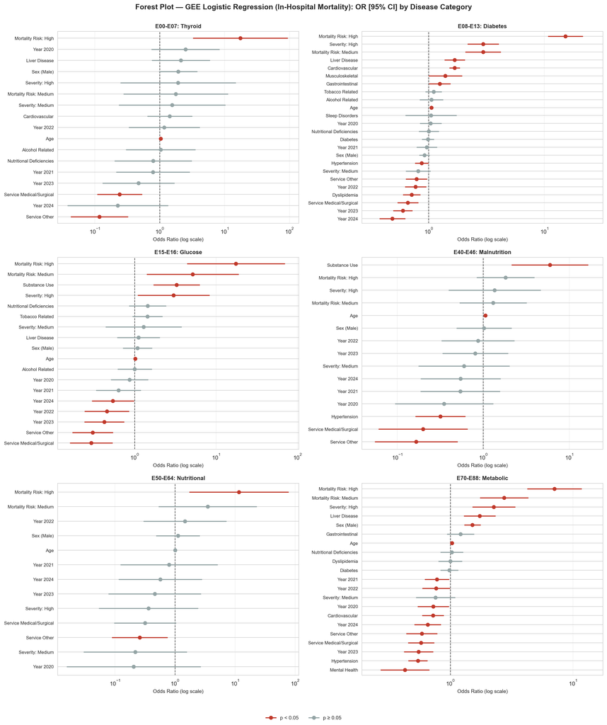

Figure 8: Figure 8a. Forest plot of Odds Ratios [95% CI] from GEE logistic regression for in-hospital mortality, one panel per disease category. Vertical reference line at OR = 1 (log scale); estimates with p < 0.05 are highlighted in red.

```python
from matplotlib.lines import Line2D

def plot_gee_forest(results_dict, ordered_keys, effect_label, sup_title, save_path,
                    sig_color='#c0392b', ns_color='#95a5a6'):
    """Forest plot of exp(coef) [95% CI] for each GEE model (one panel per group)."""
    panels = []
    for key in ordered_keys:
        res = results_dict.get(key)
        if res is None:
            continue
        params = res.params
        try:
            conf = res.conf_int()
        except Exception:
            continue
        pvals = res.pvalues
        lo_col, hi_col = conf.columns[0], conf.columns[1]
        rows = []
        for var in params.index:
            if str(var).lower() in ('const', 'intercept'):
                continue
            coef = params[var]
            if not np.isfinite(coef) or abs(coef) > 50:
                continue
            try:
                lo, hi = conf.loc[var, lo_col], conf.loc[var, hi_col]
            except Exception:
                continue
            if not (np.isfinite(lo) and np.isfinite(hi)):
                continue
            pval = float(pvals[var]) if var in pvals.index else np.nan
            rows.append((format_name(var), np.exp(coef), np.exp(lo), np.exp(hi), pval))
        if rows:
            rows.sort(key=lambda r: r[1])
            panels.append((key, rows))
    if not panels:
        print('No estimable models available to plot.')
        return
    n = len(panels)
    ncols = 2 if n > 1 else 1
    nrows = int(np.ceil(n / ncols))
    max_rows = max(len(r) for _, r in panels)
    fig_w = 7.5 * ncols
    fig_h = min(18, nrows * (0.30 * max_rows + 1.2))
    fig, axes = plt.subplots(nrows, ncols, figsize=(fig_w, fig_h), squeeze=False)
    axes_flat = axes.flatten()
    for ax_i, (key, rows) in enumerate(panels):
        ax = axes_flat[ax_i]
        labels = [r[0] for r in rows]
        ests = np.array([r[1] for r in rows])
        los = np.array([r[2] for r in rows])
        his = np.array([r[3] for r in rows])
        pvs = [r[4] for r in rows]
        for yi, (e, lo, hi, pv) in enumerate(zip(ests, los, his, pvs)):
            c = sig_color if (np.isfinite(pv) and pv < 0.05) else ns_color
            ax.plot([lo, hi], [yi, yi], color=c, lw=1.8, solid_capstyle='round', zorder=2)
            ax.plot([e], [yi], 'o', color=c, ms=6, zorder=3)
        ax.axvline(1.0, color='black', ls='--', lw=1.0, alpha=0.7, zorder=1)
        ax.set_yticks(range(len(rows)))
        ax.set_yticklabels(labels, fontsize=8)
        ax.set_ylim(-0.6, len(rows) - 0.4)
        ax.set_xscale('log')
        fin_lo = los[np.isfinite(los) & (los > 0)]
        fin_hi = his[np.isfinite(his) & (his > 0)]
        if len(fin_lo) and len(fin_hi):
            xlo, xhi = max(fin_lo.min() * 0.7, 1e-2), min(fin_hi.max() * 1.5, 1e3)
            if xlo < xhi:
                ax.set_xlim(xlo, xhi)
        ax.set_title(str(key), fontsize=10, fontweight='bold')
        ax.set_xlabel(effect_label, fontsize=9)
        ax.grid(True, axis='x', alpha=0.3)
    for j in range(len(panels), len(axes_flat)):
        axes_flat[j].axis('off')
    fig.suptitle(sup_title, fontsize=13, fontweight='bold')
    legend_elems = [Line2D([0], [0], marker='o', color=sig_color, lw=1.8, label='p < 0.05'),
                    Line2D([0], [0], marker='o', color=ns_color, lw=1.8, label='p ≥ 0.05')]
    fig.legend(handles=legend_elems, loc='lower center', ncol=2, fontsize=9, frameon=False)
    plt.tight_layout(rect=[0, 0.03, 1, 0.98])
    plt.savefig(save_path, dpi=1200, bbox_inches='tight')
    plt.show()

plot_gee_forest(gee_mortality_results, all_categories,
                'Odds Ratio (log scale)',
                'Forest Plot — GEE Logistic Regression (In-Hospital Mortality): OR [95% CI] by Disease Category',
                '../data/output_files/endocrinas_parte2/forest_gee_or_mortality.png')
```

```python
# Table 10: Performance & Fit Metrics - GEE Logistic Models
gee_perf = []
for cat in all_categories:
    if cat not in gee_mortality_results:
        continue

    result = gee_mortality_results[cat]
    df_gee = gee_mortality_models[cat][1]
    df_cat = df_endocrinas[df_endocrinas['endocrine_category'] == cat]
    n_total = len(df_cat)
    n_events = df_cat['mortality'].sum()
    event_rate = n_events / n_total * 100 if n_total > 0 else 0

    try:
        y_pred_proba = result.fittedvalues
        y_actual = df_gee['mortality'].values

        auc_val = roc_auc_score(y_actual, y_pred_proba) if len(np.unique(y_actual)) > 1 else np.nan
        brier = brier_score_loss(y_actual, y_pred_proba)

        opt_threshold = find_optimal_threshold(y_actual, y_pred_proba)
        y_pred = (y_pred_proba >= opt_threshold).astype(int)

        accuracy = accuracy_score(y_actual, y_pred)
        sensitivity = recall_score(y_actual, y_pred, zero_division=0)
        specificity = recall_score(y_actual, y_pred, pos_label=0, zero_division=0)
        ppv = precision_score(y_actual, y_pred, zero_division=0)
        tn = ((1 - y_actual) * (1 - y_pred)).sum()
        fn = (y_actual * (1 - y_pred)).sum()
        npv = tn / (tn + fn) if (tn + fn) > 0 else 0
        f1 = f1_score(y_actual, y_pred, zero_division=0)
        mcc = matthews_corrcoef(y_actual, y_pred)
        youdens_j = sensitivity + specificity - 1

    except Exception:
        accuracy = sensitivity = specificity = ppv = npv = f1 = mcc = brier = auc_val = np.nan
        opt_threshold = np.nan
        youdens_j = np.nan

    n_sig_comorbs = len(sig_comorbidities_mortality.get(cat, []))
    fit_metrics = get_gee_fit_metrics(result, df_gee['mortality'], family_type='binomial')

    gee_perf.append({
        'Disease Category': cat,
        'N obs': fit_metrics['N_obs'],
        'N clusters': fit_metrics['N_clusters'],
        'N params': fit_metrics['N_params'],
        'Events': f'{n_events} ({event_rate:.1f}%)',
        'Sig. Comorb.': n_sig_comorbs,
        'Correlation': fit_metrics['Correlation'],
        'QIC': safe_fmt(fit_metrics['QIC'], '.1f'),
        'QICu': safe_fmt(fit_metrics['QICu'], '.1f'),
        'Log-Lik': safe_fmt(fit_metrics['Log-Lik (model)'], '.1f'),
        'Pseudo R²': safe_fmt(fit_metrics['Pseudo R² (McFadden)']),
        'Scale': safe_fmt(fit_metrics['Scale']),
        'Threshold': safe_fmt(opt_threshold),
        'AUC': safe_fmt(auc_val),
        'Brier': safe_fmt(brier),
        'Sensitivity': safe_fmt(sensitivity),
        'Specificity': safe_fmt(specificity),
        'PPV': safe_fmt(ppv),
        'NPV': safe_fmt(npv),
        'Bal. Accuracy': safe_fmt((sensitivity + specificity) / 2 if not np.isnan(sensitivity) else np.nan),
        'F1': safe_fmt(f1),
        'MCC': safe_fmt(mcc),
        "Youden's J": safe_fmt(youdens_j),
    })

gee_perf_df = pd.DataFrame(gee_perf)
show_table(gee_perf_df, "Table 10: Performance & Fit Metrics - GEE Logistic Regression for Mortality\n(QIC = Quasi-Information Criterion, Pseudo R² = McFadden)", index=False)
```

Table 10: Performance & Fit Metrics - GEE Logistic Regression for Mortality (QIC = Quasi-Information Criterion, Pseudo R² = McFadden)

| Disease Category | N obs | N clusters | N params | Events | Sig. Comorb. | Correlation | QIC | QICu | Log-Lik | Pseudo R² | Scale | Threshold | AUC | Brier | Sensitivity | Specificity | PPV | NPV | Bal. Accuracy | F1 | MCC | Youden's J |
| --- | --- | --- | --- | --- | --- | --- | --- | --- | --- | --- | --- | --- | --- | --- | --- | --- | --- | --- | --- | --- | --- | --- |
| E00-E07: Thyroid | 7209 | 69 | 18 | 38 (0.5%) | 4 | Exchangeable | 284.3 | 317.5 | -139.8 | 0.4106 | 1.0000 | 0.0054 | 0.9546 | 0.0045 | 0.9211 | 0.9163 | 0.0551 | 0.9995 | 0.9187 | 0.1040 | 0.2139 | 0.8374 |
| E08-E13: Diabetes | 83496 | 70 | 25 | 1667 (2.0%) | 11 | Exchangeable | 11640.9 | 11685.0 | -5813.9 | 0.2888 | 1.0000 | 0.0204 | 0.9085 | 0.0174 | 0.8542 | 0.8250 | 0.0904 | 0.9964 | 0.8396 | 0.1636 | 0.2429 | 0.6792 |
| E15-E16: Glucose | 3646 | 69 | 19 | 163 (4.5%) | 5 | Exchangeable | 1027.2 | 1061.3 | -511.6 | 0.2317 | 1.0000 | 0.0627 | 0.8650 | 0.0379 | 0.8037 | 0.8010 | 0.1590 | 0.9887 | 0.8024 | 0.2655 | 0.2988 | 0.6047 |
| E20-E35: Endocrine | 3524 | 71 | 16 | 35 (1.0%) | 2 | Exchangeable | — | — | — | — | 1.0000 | — | — | — | — | — | — | — | — | — | — | — |
| E40-E46: Malnutrition | 1426 | 66 | 16 | 54 (3.8%) | 2 | Exchangeable | 319.5 | 347.8 | -157.9 | 0.3127 | 1.0000 | 0.0193 | 0.9026 | 0.0303 | 1.0000 | 0.6880 | 0.1120 | 1.0000 | 0.8440 | 0.2015 | 0.2776 | 0.6880 |
| E50-E64: Nutritional | 490 | 62 | 14 | 18 (3.7%) | 0 | Exchangeable | 135.3 | 161.7 | -66.9 | 0.1331 | 1.0000 | 0.0776 | 0.7671 | 0.0325 | 0.5556 | 0.8877 | 0.1587 | 0.9813 | 0.7216 | 0.2469 | 0.2491 | 0.4433 |
| E70-E88: Metabolic | 20607 | 72 | 22 | 741 (3.6%) | 8 | Exchangeable | 4982.7 | 5022.2 | -2489.0 | 0.2201 | 1.0000 | 0.0453 | 0.8644 | 0.0315 | 0.7868 | 0.7823 | 0.1188 | 0.9899 | 0.7846 | 0.2064 | 0.2488 | 0.5691 |

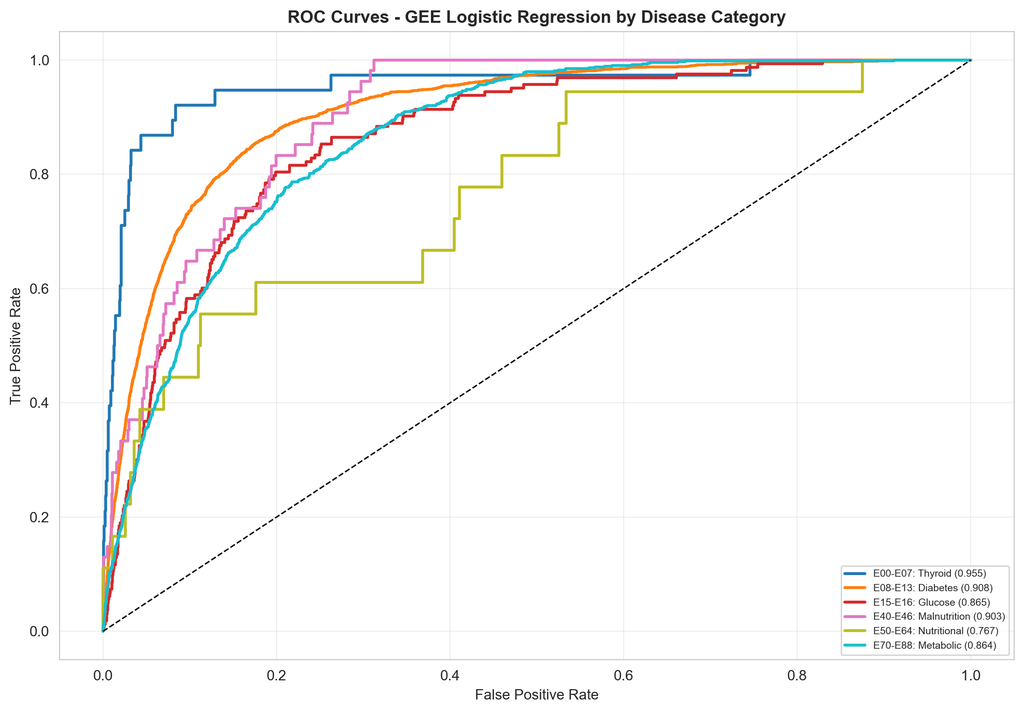

Figure 9: Figure 8. ROC Curves - GEE Logistic Regression Models by Disease Category

```python
fig, ax = plt.subplots(figsize=(10, 7))
colors_roc = plt.cm.tab10(np.linspace(0, 1, len(gee_mortality_results)))

for idx, (cat, result) in enumerate(gee_mortality_results.items()):
    try:
        y_pred_proba = result.fittedvalues
        df_gee = gee_mortality_models[cat][1]
        y_actual = df_gee['mortality'].values
        fpr, tpr, _ = roc_curve(y_actual, y_pred_proba)
        auc_val = roc_auc_score(y_actual, y_pred_proba)
        ax.plot(fpr, tpr, label=f'{cat} ({auc_val:.3f})', linewidth=2, color=colors_roc[idx])
    except:
        pass

ax.plot([0, 1], [0, 1], 'k--', linewidth=1)
ax.set_xlabel('False Positive Rate')
ax.set_ylabel('True Positive Rate')
ax.set_title('ROC Curves - GEE Logistic Regression by Disease Category', fontsize=12, fontweight='bold')
ax.legend(fontsize=7, loc='lower right')
ax.grid(True, alpha=0.3)

plt.tight_layout()
plt.savefig('../data/output_files/endocrinas_parte2/roc_gee_logistic_by_category.png', dpi=1200, bbox_inches='tight')
plt.show()
```

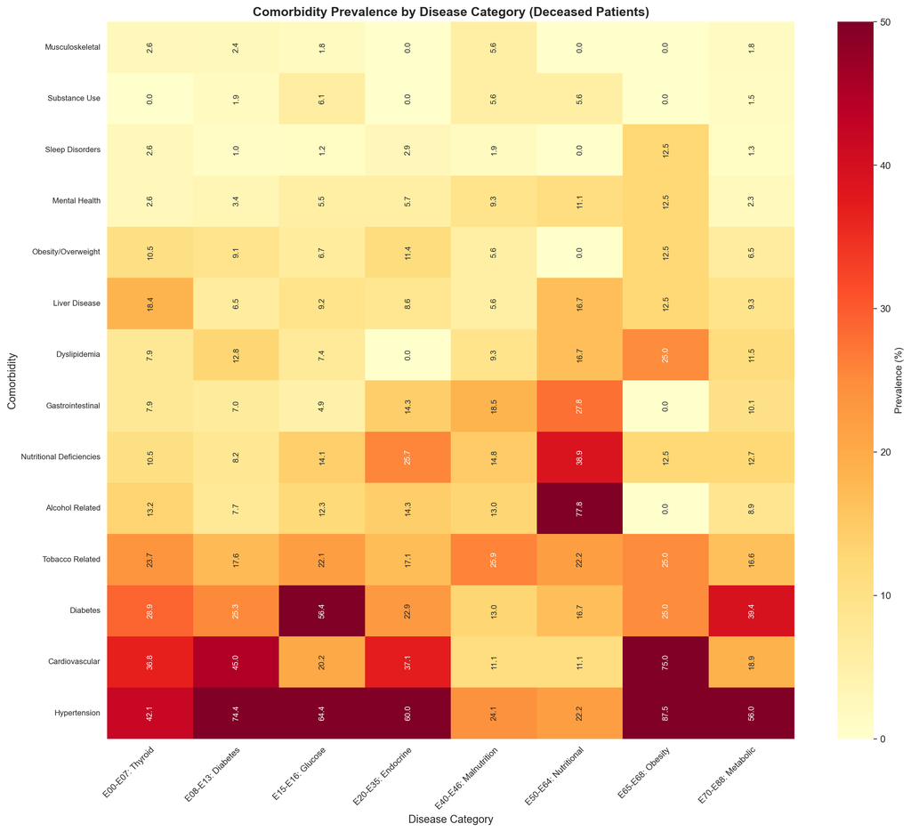

Figure 10: Heatmap of comorbidity prevalence in deceased patients

```python
fig, ax = plt.subplots(figsize=(14, 12))

categories_for_heatmap = [c for c in df_endocrinas['endocrine_category'].unique() if pd.notna(c) and (deceased[deceased['endocrine_category'] == c].shape[0] >= 5)]
comor_by_cat_deceased = pd.DataFrame()

for category in sorted(categories_for_heatmap):
    cat_data = deceased[deceased['endocrine_category'] == category][comor_cols].mean() * 100
    cat_data.index = [format_name(col) for col in comor_cols]
    comor_by_cat_deceased[category] = cat_data

comor_by_cat_deceased = comor_by_cat_deceased.loc[comor_by_cat_deceased.mean(axis=1).sort_values(ascending=True).index]

sns.heatmap(comor_by_cat_deceased, annot=True, fmt='.1f', cmap='YlOrRd',
            cbar_kws={'label': 'Prevalence (%)'}, ax=ax, vmin=0, vmax=50,
            annot_kws={'rotation': 90, 'fontsize': 8})
ax.set_title('Comorbidity Prevalence by Disease Category (Deceased Patients)', fontweight='bold', fontsize=13)
ax.set_xlabel('Disease Category', fontsize=11)
ax.set_ylabel('Comorbidity', fontsize=11)
plt.setp(ax.get_xticklabels(), rotation=45, ha='right', rotation_mode='anchor', fontsize=9)
plt.setp(ax.get_yticklabels(), rotation=0, fontsize=8)

plt.tight_layout()
plt.savefig('../data/output_files/endocrinas_parte2/fig_comorbidity_heatmap_deceased.png', dpi=1200, bbox_inches='tight', facecolor='white')
plt.show()
```

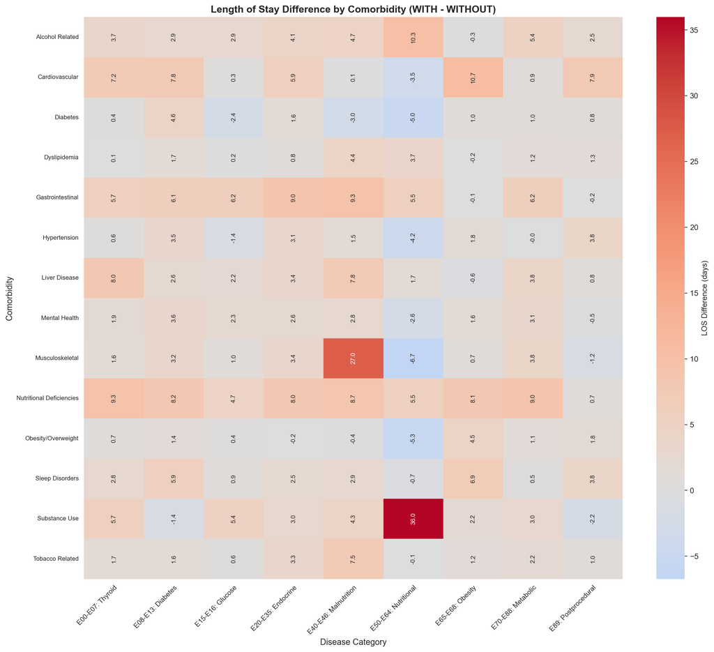

Figure 11: Heatmap of LOS difference by comorbidity presence

```python
fig, ax = plt.subplots(figsize=(14, 12))

categories_for_los_heatmap = [c for c in df_endocrinas['endocrine_category'].unique() if pd.notna(c) and (df_endocrinas[df_endocrinas['endocrine_category'] == c].shape[0] >= 20)]
los_diff_matrix = pd.DataFrame()

for category in sorted(categories_for_los_heatmap):
    cat_data = df_endocrinas[df_endocrinas['endocrine_category'] == category]
    col_data = []
    for col in sorted(comor_cols):
        los_with = cat_data[cat_data[col] == 1]['length_of_stay'].mean()
        los_without = cat_data[cat_data[col] == 0]['length_of_stay'].mean()
        diff = los_with - los_without if pd.notna(los_with) else 0
        col_data.append(diff)
    los_diff_matrix[category] = col_data

los_diff_matrix.index = [format_name(col) for col in sorted(comor_cols)]

sns.heatmap(los_diff_matrix, annot=True, fmt='.1f', cmap='coolwarm', center=0,
            cbar_kws={'label': 'LOS Difference (days)'}, ax=ax,
            annot_kws={'rotation': 90, 'fontsize': 8})
ax.set_title('Length of Stay Difference by Comorbidity (WITH - WITHOUT)', fontweight='bold', fontsize=13)
ax.set_xlabel('Disease Category', fontsize=11)
ax.set_ylabel('Comorbidity', fontsize=11)
plt.setp(ax.get_xticklabels(), rotation=45, ha='right', rotation_mode='anchor', fontsize=9)
plt.setp(ax.get_yticklabels(), rotation=0, fontsize=8)

plt.tight_layout()
plt.savefig('../data/output_files/endocrinas_parte2/fig_los_comorbidity_heatmap.png', dpi=1200, bbox_inches='tight', facecolor='white')
plt.show()
```

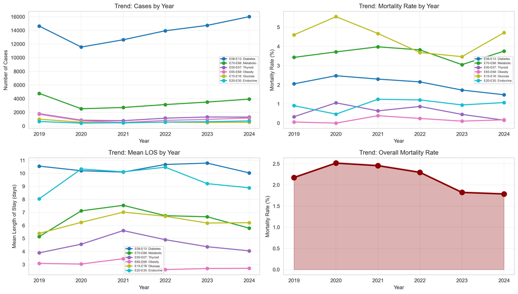

Figure 12: Figure 7. Temporal Trends: Cases and Mortality by Year and Disease Category

```python
fig, axes = plt.subplots(2, 2, figsize=(14, 8))

categories_top = df_endocrinas['endocrine_category'].value_counts().head(6).index.tolist()
colors = plt.cm.tab10(np.linspace(0, 1, len(categories_top)))

# Cases by year per category
ax = axes[0, 0]
for cat, color in zip(categories_top, colors):
    df_cat = df_endocrinas[df_endocrinas['endocrine_category'] == cat]
    cases_by_year = df_cat['year'].value_counts().sort_index()
    ax.plot(cases_by_year.index, cases_by_year.values, marker='o', linewidth=2, label=cat, color=color)
ax.set_xlabel('Year')
ax.set_ylabel('Number of Cases')
ax.set_title('Trend: Cases by Year')
ax.legend(fontsize=6)
ax.grid(True, alpha=0.3)

# Mortality rate by year per category
ax = axes[0, 1]
for cat, color in zip(categories_top, colors):
    df_cat = df_endocrinas[df_endocrinas['endocrine_category'] == cat]
    mortality_by_year = df_cat.groupby('year')['mortality'].mean() * 100
    ax.plot(mortality_by_year.index, mortality_by_year.values, marker='o', linewidth=2, label=cat, color=color)
ax.set_xlabel('Year')
ax.set_ylabel('Mortality Rate (%)')
ax.set_title('Trend: Mortality Rate by Year')
ax.legend(fontsize=6)
ax.grid(True, alpha=0.3)

# Mean LOS by year per category
ax = axes[1, 0]
for cat, color in zip(categories_top, colors):
    df_cat = df_endocrinas[df_endocrinas['endocrine_category'] == cat]
    los_by_year = df_cat.groupby('year')['length_of_stay'].mean()
    ax.plot(los_by_year.index, los_by_year.values, marker='o', linewidth=2, label=cat, color=color)
ax.set_xlabel('Year')
ax.set_ylabel('Mean Length of Stay (days)')
ax.set_title('Trend: Mean LOS by Year')
ax.legend(fontsize=6)
ax.grid(True, alpha=0.3)

# Overall mortality trend
ax = axes[1, 1]
overall_mortality = df_endocrinas.groupby('year')['mortality'].mean() * 100
ax.plot(overall_mortality.index, overall_mortality.values, marker='o', linewidth=3, markersize=10, color='darkred')
ax.fill_between(overall_mortality.index, overall_mortality.values, alpha=0.3, color='darkred')
ax.set_xlabel('Year')
ax.set_ylabel('Mortality Rate (%)')
ax.set_title('Trend: Overall Mortality Rate')
ax.grid(True, alpha=0.3)

plt.tight_layout()
plt.savefig('../data/output_files/endocrinas_parte2/fig_temporal_trends.png', dpi=1200, bbox_inches='tight')
plt.show()
```

# 7 7. GEE Mixed-Effects Regression for Length of Stay (All Disease Categories)

```python
# Store GEE LOS model results
gee_los_models = {}
gee_los_results = {}

def build_gee_los_model(df_cat, cat_name):
    """Build GEE Negative Binomial regression for LOS.
    Uses hospital_id as cluster group, year_factor as fixed effect."""
    df_model = df_cat[df_cat['length_of_stay'] > 0].copy()

    service_dummies = pd.get_dummies(df_model['service_category'], prefix='service', drop_first=True)
    for col in service_dummies.columns:
        df_model[col] = service_dummies[col]
    service_dummy_cols = list(service_dummies.columns)

    year_dummies = pd.get_dummies(df_model['year_factor'], prefix='year', drop_first=True)
    for col in year_dummies.columns:
        df_model[col] = year_dummies[col]
    year_dummy_cols = list(year_dummies.columns)

    df_model['age'] = pd.to_numeric(df_model['age'], errors='coerce')

    predictor_cols = ['age', 'male'] + service_dummy_cols + year_dummy_cols

    for col in ['IR_29301_SEVERIDAD', 'IR_29301_MORTALIDAD']:
        if col in df_model.columns:
            df_model[col] = pd.to_numeric(df_model[col], errors='coerce')
            df_model[col] = df_model[col].fillna(1).clip(lower=1).astype(int)
            prefix = 'severity' if 'SEVERIDAD' in col else 'mort_risk'
            col_dummies = pd.get_dummies(df_model[col], prefix=prefix, drop_first=True)
            for dc in col_dummies.columns:
                df_model[dc] = col_dummies[dc]
                predictor_cols.append(dc)

    sig_comorbs = sig_comorbidities_los.get(cat_name, [])
    used_comorbs = []
    for col in sig_comorbs:
        if col in df_model.columns:
            df_model[col] = pd.to_numeric(df_model[col], errors='coerce').fillna(0).astype(int)
            if df_model[col].sum() >= 3:
                predictor_cols.append(col)
                used_comorbs.append(col)

    df_model['_group'] = df_model['hospital_id']
    cols_for_model = ['length_of_stay', '_group'] + predictor_cols
    df_gee = df_model[cols_for_model].dropna()

    n_clusters = df_gee['_group'].nunique()
    if len(df_gee) < 50 or n_clusters < 2:
        return None, None, [], []

    y = df_gee['length_of_stay'].astype(float)
    X = df_gee[predictor_cols].astype(float)
    X = sm.add_constant(X)
    groups = df_gee['_group']

    try:
        gee_model = GEE(y, X, groups=groups, family=NegativeBinomial(alpha=1.0), cov_struct=Exchangeable())
        gee_result = gee_model.fit(maxiter=200)
    except Exception:
        try:
            gee_model = GEE(y, X, groups=groups, family=NegativeBinomial(alpha=1.0), cov_struct=Independence())
            gee_result = gee_model.fit(maxiter=200)
        except Exception:
            try:
                gee_model = GEE(y, X, groups=groups, family=Poisson(), cov_struct=Exchangeable())
                gee_result = gee_model.fit(maxiter=200)
            except Exception:
                return None, None, [], []

    max_retries = 5
    current_predictors = list(predictor_cols)
    for _ in range(max_retries):
        params = gee_result.params
        bad_vars = []
        for i, var in enumerate(current_predictors):
            idx = i + 1
            if idx < len(params) and (np.isinf(params.iloc[idx]) or abs(params.iloc[idx]) > 50):
                bad_vars.append(var)
        if not bad_vars:
            break
        current_predictors = [p for p in current_predictors if p not in bad_vars]
        if len(current_predictors) < 2:
            return None, None, [], []
        X = df_gee[current_predictors].astype(float)
        X = sm.add_constant(X)
        try:
            gee_model = GEE(y, X, groups=groups, family=NegativeBinomial(alpha=1.0), cov_struct=Exchangeable())
            gee_result = gee_model.fit(maxiter=200)
        except:
            try:
                gee_model = GEE(y, X, groups=groups, family=Poisson(), cov_struct=Exchangeable())
                gee_result = gee_model.fit(maxiter=200)
            except:
                return None, None, [], []

    return gee_result, df_gee, current_predictors, used_comorbs

# Fit GEE LOS models for EACH disease category
for cat in all_categories:
    df_cat = df_endocrinas[df_endocrinas['endocrine_category'] == cat].copy()
    if len(df_cat) < 50:
        continue
    gee_result, df_gee, used_cols, used_comorbs = build_gee_los_model(df_cat, cat)
    if gee_result is not None:
        gee_los_models[cat] = (gee_result, df_gee, used_cols)
        gee_los_results[cat] = gee_result
```

## 7.1 7.1 GEE Regression Results - IRR [95% CI]

```python
# Table 11: GEE Regression - IRR [95% CI] by Disease Category
gee_irr_table = {}

for cat in all_categories:
    if cat not in gee_los_results:
        continue

    result = gee_los_results[cat]
    used_cols = gee_los_models[cat][2]

    params = result.params
    conf = result.conf_int()
    pvalues = result.pvalues

    col_data = {}
    for i, var in enumerate(used_cols):
        idx = i + 1
        if idx >= len(params):
            continue
        coef = params.iloc[idx]
        if np.isinf(coef) or abs(coef) > 50:
            continue
        irr_val = np.exp(coef)
        ci_low = np.exp(conf.iloc[idx, 0])
        ci_high = np.exp(conf.iloc[idx, 1])
        pval = pvalues.iloc[idx]

        if np.isnan(irr_val) or np.isnan(pval):
            continue

        sig = '***' if pval < 0.001 else '**' if pval < 0.01 else '*' if pval < 0.05 else ''
        col_data[format_name(var)] = f'{irr_val:.3f} [{ci_low:.3f}, {ci_high:.3f}]{sig}'

    gee_irr_table[cat] = col_data

if gee_irr_table:
    all_vars = set()
    for col_data in gee_irr_table.values():
        all_vars.update(col_data.keys())

    irr_rows = []
    for var in sorted(all_vars):
        row = {'Variable': var}
        for cat in sorted(gee_irr_table.keys()):
            row[cat] = gee_irr_table[cat].get(var, '—')
        irr_rows.append(row)

    gee_irr_df = pd.DataFrame(irr_rows).set_index('Variable')
    show_table(gee_irr_df, "Table 11: GEE Mixed-Effects Regression - IRR [95% CI] for Length of Stay by Disease Category\n(Hospital as cluster, year as fixed effect, Negative Binomial family, only significant comorbidities)\n* p<0.05, ** p<0.01, *** p<0.001", index=True)
```

Table 11: GEE Mixed-Effects Regression - IRR [95% CI] for Length of Stay by Disease Category (Hospital as cluster, year as fixed effect, Negative Binomial family, only significant comorbidities) * p<0.05, ** p<0.01, *** p<0.001

| Variable | E00-E07: Thyroid | E08-E13: Diabetes | E15-E16: Glucose | E20-E35: Endocrine | E40-E46: Malnutrition | E50-E64: Nutritional | E65-E68: Obesity | E70-E88: Metabolic | E89: Postprocedural |
| --- | --- | --- | --- | --- | --- | --- | --- | --- | --- |
| Age | 0.999 [0.997, 1.001] | 1.003 [1.002, 1.005]*** | 0.996 [0.994, 0.999]** | 0.998 [0.995, 1.001] | 0.994 [0.991, 0.997]*** | 0.999 [0.992, 1.006] | 0.997 [0.994, 1.001] | 0.996 [0.994, 0.998]*** | 1.004 [0.995, 1.014] |
| Alcohol Related | 1.060 [0.965, 1.163] | 1.084 [1.044, 1.126]*** | 1.028 [0.886, 1.191] | 1.027 [0.868, 1.214] | 1.138 [0.857, 1.512] | 1.433 [1.089, 1.886]* | 1.020 [0.936, 1.111] | 1.315 [1.210, 1.430]*** | — |
| Cardiovascular | 1.144 [1.022, 1.280]* | 1.406 [1.353, 1.462]*** | 1.001 [0.906, 1.105] | 1.176 [1.044, 1.326]** | 0.926 [0.766, 1.118] | — | 1.242 [1.036, 1.488]* | 1.042 [0.971, 1.119] | 1.414 [0.882, 2.267] |
| Diabetes | 0.975 [0.926, 1.027] | 1.156 [1.124, 1.188]*** | 0.705 [0.610, 0.814]*** | 0.992 [0.906, 1.087] | — | — | 1.027 [0.969, 1.089] | 1.007 [0.959, 1.057] | 0.884 [0.706, 1.107] |
| Dyslipidemia | 0.904 [0.846, 0.967]** | 1.022 [0.990, 1.055] | 1.087 [0.959, 1.231] | 0.952 [0.860, 1.054] | 1.084 [0.775, 1.517] | — | — | 1.097 [1.025, 1.175]** | — |
| Gastrointestinal | 1.324 [1.147, 1.529]*** | 1.261 [1.192, 1.334]*** | 1.521 [1.270, 1.822]*** | 1.518 [1.177, 1.957]** | 1.339 [1.109, 1.617]** | 1.354 [1.009, 1.816]* | — | 1.349 [1.191, 1.529]*** | — |
| Hypertension | 1.023 [0.969, 1.080] | 1.103 [1.072, 1.134]*** | — | 1.188 [1.099, 1.283]*** | — | — | 1.139 [1.063, 1.219]*** | 1.023 [0.973, 1.075] | 1.296 [1.000, 1.681] |
| Liver Disease | 1.264 [0.974, 1.640] | 0.989 [0.934, 1.047] | 1.082 [0.929, 1.259] | 1.046 [0.870, 1.258] | 1.114 [0.847, 1.466] | 1.105 [0.834, 1.464] | 0.814 [0.727, 0.912]*** | 1.051 [0.961, 1.149] | — |
| Mental Health | 1.136 [1.012, 1.275]* | 1.264 [1.195, 1.338]*** | 1.140 [0.955, 1.361] | 1.111 [0.947, 1.304] | 1.195 [0.973, 1.467] | — | 1.121 [1.023, 1.227]* | 1.225 [1.108, 1.354]*** | — |
| Mortality Risk: High | 1.514 [1.259, 1.822]*** | 1.125 [1.058, 1.196]*** | 1.344 [1.097, 1.646]** | 1.511 [1.302, 1.755]*** | 1.611 [1.168, 2.222]** | 1.250 [0.767, 2.035] | 1.774 [1.323, 2.378]*** | 1.298 [1.200, 1.405]*** | 1.388 [1.052, 1.832]* |
| Mortality Risk: Medium | 1.191 [1.081, 1.313]*** | 1.016 [0.980, 1.053] | 0.988 [0.878, 1.113] | 1.377 [1.220, 1.554]*** | 1.344 [1.089, 1.659]** | 1.136 [0.892, 1.446] | 1.255 [1.105, 1.426]*** | 1.265 [1.173, 1.365]*** | 1.405 [1.108, 1.782]** |
| Musculoskeletal | 1.037 [0.891, 1.205] | 1.091 [0.991, 1.202] | 0.967 [0.817, 1.145] | 1.167 [0.962, 1.415] | 1.804 [1.017, 3.200]* | — | 1.044 [0.883, 1.236] | 1.229 [1.009, 1.496]* | — |
| Nutritional Deficiencies | 1.450 [1.274, 1.649]*** | 1.311 [1.248, 1.376]*** | 1.182 [1.002, 1.395]* | 1.309 [1.132, 1.514]*** | 1.329 [1.130, 1.565]*** | 1.414 [1.096, 1.824]** | 1.414 [0.809, 2.471] | 1.463 [1.306, 1.638]*** | — |
| Obesity/Overweight | 1.040 [0.941, 1.150] | 1.120 [1.083, 1.158]*** | 0.943 [0.837, 1.062] | — | — | — | 1.236 [0.994, 1.538] | 1.072 [0.972, 1.182] | — |
| Service Medical/Surgical | 0.854 [0.759, 0.960]** | 0.986 [0.879, 1.106] | 0.560 [0.459, 0.682]*** | 1.006 [0.820, 1.235] | 1.191 [0.868, 1.635] | 0.300 [0.118, 0.762]* | 0.827 [0.641, 1.066] | 0.847 [0.767, 0.935]** | 0.728 [0.574, 0.923]** |
| Service Other | 0.579 [0.514, 0.651]*** | 1.451 [1.319, 1.595]*** | 0.473 [0.399, 0.561]*** | 0.844 [0.683, 1.042] | 0.875 [0.675, 1.135] | 0.320 [0.129, 0.796]* | 0.594 [0.485, 0.729]*** | 0.760 [0.674, 0.858]*** | 0.669 [0.548, 0.818]*** |
| Severity: High | 2.271 [1.955, 2.637]*** | 1.581 [1.473, 1.695]*** | 2.151 [1.756, 2.636]*** | 2.314 [1.856, 2.883]*** | 1.676 [1.323, 2.124]*** | 1.610 [1.100, 2.357]* | 1.980 [1.528, 2.565]*** | 1.919 [1.718, 2.144]*** | 1.831 [1.327, 2.526]*** |
| Severity: Medium | 1.359 [1.229, 1.503]*** | 1.198 [1.157, 1.239]*** | 1.403 [1.213, 1.622]*** | 1.603 [1.357, 1.895]*** | 1.282 [1.061, 1.549]** | 1.116 [0.893, 1.396] | 1.124 [1.032, 1.223]** | 1.335 [1.227, 1.454]*** | 1.071 [0.854, 1.341] |
| Sex (Male) | 1.070 [1.006, 1.137]* | 1.133 [1.106, 1.161]*** | 0.968 [0.887, 1.057] | 1.157 [1.076, 1.244]*** | 0.959 [0.842, 1.091] | 0.984 [0.752, 1.286] | 1.022 [0.966, 1.080] | 1.080 [1.017, 1.146]* | 1.114 [0.944, 1.315] |
| Sleep Disorders | — | 1.217 [1.050, 1.410]** | 0.975 [0.730, 1.304] | — | — | — | 1.605 [1.318, 1.953]*** | 1.185 [1.019, 1.379]* | — |
| Substance Use | 1.285 [1.047, 1.577]* | 0.955 [0.898, 1.015] | 1.217 [0.950, 1.560] | — | — | — | — | — | — |
| Tobacco Related | 1.008 [0.924, 1.100] | 1.049 [1.014, 1.085]** | 0.919 [0.823, 1.026] | 1.214 [1.095, 1.347]*** | 1.201 [0.973, 1.482] | — | 1.042 [0.990, 1.096] | 1.100 [1.045, 1.157]*** | — |
| Year 2020 | 0.997 [0.916, 1.085] | 0.913 [0.877, 0.951]*** | 1.083 [0.939, 1.249] | 1.101 [0.974, 1.245] | 0.924 [0.725, 1.178] | 1.385 [0.869, 2.208] | 0.847 [0.772, 0.929]*** | 1.050 [0.949, 1.162] | 0.878 [0.599, 1.286] |
| Year 2021 | 1.239 [0.985, 1.558] | 0.931 [0.886, 0.979]** | 1.094 [0.951, 1.259] | 1.041 [0.900, 1.204] | 1.027 [0.834, 1.265] | 1.365 [0.952, 1.958] | 0.851 [0.707, 1.025] | 1.063 [0.988, 1.145] | 0.798 [0.586, 1.086] |
| Year 2022 | 1.020 [0.930, 1.119] | 0.946 [0.902, 0.993]* | 0.959 [0.810, 1.136] | 1.021 [0.884, 1.179] | 0.941 [0.748, 1.184] | 0.976 [0.728, 1.309] | 0.708 [0.651, 0.769]*** | 0.953 [0.858, 1.058] | 0.688 [0.532, 0.889]** |
| Year 2023 | 0.904 [0.811, 1.007] | 0.939 [0.876, 1.007] | 0.890 [0.752, 1.052] | 0.927 [0.799, 1.076] | 1.093 [0.894, 1.337] | 0.951 [0.749, 1.207] | 0.698 [0.631, 0.773]*** | 0.909 [0.828, 0.998]* | 0.831 [0.686, 1.008] |
| Year 2024 | 0.876 [0.800, 0.959]** | 0.850 [0.803, 0.901]*** | 0.862 [0.730, 1.019] | 0.859 [0.767, 0.962]** | 0.811 [0.647, 1.017] | 1.076 [0.808, 1.433] | 0.651 [0.589, 0.720]*** | 0.810 [0.731, 0.898]*** | 0.735 [0.591, 0.914]** |

**Forest plot — Incidence Rate Ratios (IRR) [95% CI] for length of stay, by disease category.**

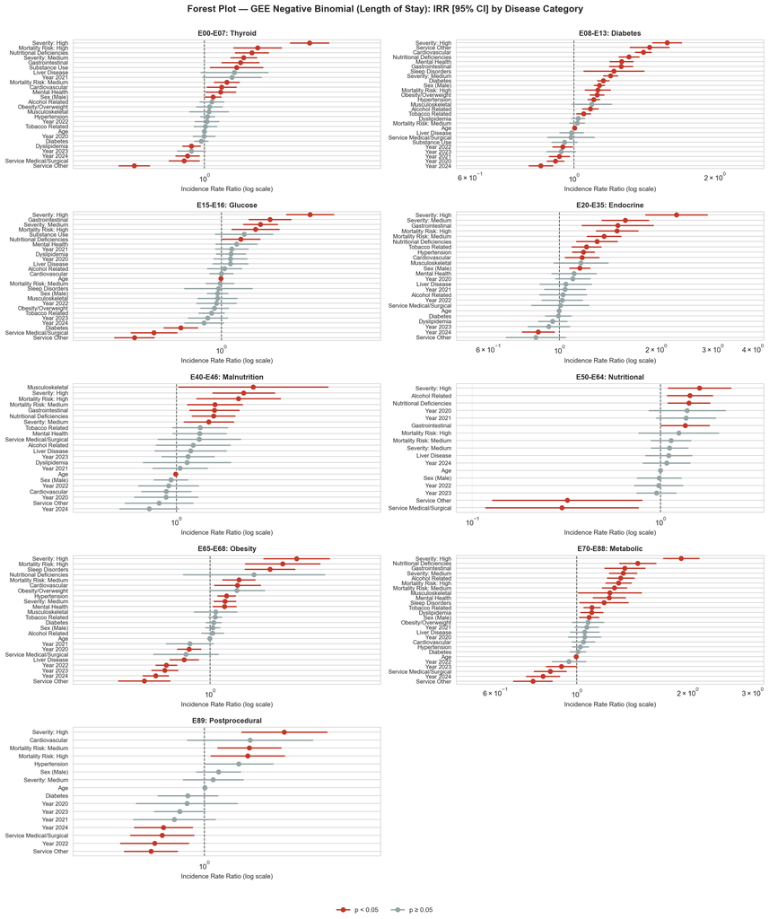

Figure 13: Figure. Forest plot of Incidence Rate Ratios [95% CI] from GEE Negative Binomial regression for length of stay, one panel per disease category. Vertical reference line at IRR = 1 (log scale); estimates with p < 0.05 are highlighted in red.

```python
plot_gee_forest(gee_los_results, all_categories,
                'Incidence Rate Ratio (log scale)',
                'Forest Plot — GEE Negative Binomial (Length of Stay): IRR [95% CI] by Disease Category',
                '../data/output_files/endocrinas_parte2/forest_gee_irr_los.png')
```

```python
# Table 12: Performance & Fit Metrics - GEE LOS Models
gee_los_perf = []
for cat in all_categories:
    if cat not in gee_los_results:
        continue

    result = gee_los_results[cat]
    df_gee = gee_los_models[cat][1]
    df_cat = df_endocrinas[df_endocrinas['endocrine_category'] == cat]
    n_total = len(df_cat)

    try:
        y_pred = result.fittedvalues
        y_actual = df_gee['length_of_stay'].values

        rmse = np.sqrt(np.mean((y_actual - y_pred) ** 2))
        mae = np.mean(np.abs(y_actual - y_pred))
        ss_res = np.sum((y_actual - y_pred) ** 2)
        ss_tot = np.sum((y_actual - np.mean(y_actual)) ** 2)
        pseudo_r2 = 1 - ss_res / ss_tot if ss_tot > 0 else np.nan
    except Exception:
        rmse = mae = pseudo_r2 = np.nan

    n_sig_comorbs = len(sig_comorbidities_los.get(cat, []))
    fit_metrics = get_gee_fit_metrics(result, df_gee['length_of_stay'], family_type='count')

    gee_los_perf.append({
        'Disease Category': cat,
        'N obs': fit_metrics['N_obs'],
        'N clusters': fit_metrics['N_clusters'],
        'N params': fit_metrics['N_params'],
        'Mean LOS': f'{df_cat["length_of_stay"].mean():.1f}',
        'Median LOS': f'{df_cat["length_of_stay"].median():.0f}',
        'Sig. Comorb.': n_sig_comorbs,
        'Correlation': fit_metrics['Correlation'],
        'QIC': safe_fmt(fit_metrics['QIC'], '.1f'),
        'QICu': safe_fmt(fit_metrics['QICu'], '.1f'),
        'Pseudo R²': safe_fmt(fit_metrics['Pseudo R²']),
        'Scale': safe_fmt(fit_metrics['Scale']),
        'RMSE': f'{rmse:.2f}' if not np.isnan(rmse) else '—',
        'MAE': f'{mae:.2f}' if not np.isnan(mae) else '—',
    })

gee_los_perf_df = pd.DataFrame(gee_los_perf)
show_table(gee_los_perf_df, "Table 12: Performance & Fit Metrics - GEE Regression Models for LOS\n(QIC = Quasi-Information Criterion, Negative Binomial/Poisson family)", index=False)
```

Table 12: Performance & Fit Metrics - GEE Regression Models for LOS (QIC = Quasi-Information Criterion, Negative Binomial/Poisson family)

| Disease Category | N obs | N clusters | N params | Mean LOS | Median LOS | Sig. Comorb. | Correlation | QIC | QICu | Pseudo R² | Scale | RMSE | MAE |
| --- | --- | --- | --- | --- | --- | --- | --- | --- | --- | --- | --- | --- | --- |
| E00-E07: Thyroid | 6787 | 69 | 27 | 4.4 | 3 | 13 | Exchangeable | 11531.4 | 3257.6 | 0.2032 | 1.0000 | 7.60 | 3.04 |
| E08-E13: Diabetes | 74717 | 70 | 28 | 10.4 | 6 | 14 | Exchangeable | 137942.2 | 58598.8 | 0.1090 | 1.0000 | 14.61 | 8.43 |
| E15-E16: Glucose | 3438 | 69 | 27 | 6.2 | 3 | 13 | Exchangeable | 10284.1 | 2399.5 | 0.1015 | 1.0000 | 13.30 | 4.97 |
| E20-E35: Endocrine | 3379 | 71 | 25 | 9.4 | 6 | 11 | Exchangeable | 16912.3 | 2368.3 | 0.0994 | 1.0000 | 15.77 | 6.90 |
| E40-E46: Malnutrition | 1374 | 66 | 23 | 15.2 | 8 | 9 | Exchangeable | 41061.4 | 1290.8 | 0.1221 | 1.0000 | 29.05 | 12.52 |
| E50-E64: Nutritional | 476 | 62 | 18 | 16.5 | 8 | 4 | Exchangeable | 86978.7 | 397.8 | 0.0741 | 1.0000 | 58.84 | 13.80 |
| E65-E68: Obesity | 5737 | 65 | 25 | 2.9 | 2 | 11 | Exchangeable | 9299.5 | 1764.2 | 0.2573 | 1.0000 | 4.90 | 1.93 |
| E70-E88: Metabolic | 18069 | 71 | 27 | 6.3 | 3 | 13 | Exchangeable | 31403.2 | 12859.4 | 0.0898 | 1.0000 | 14.63 | 5.31 |
| E89: Postprocedural | 276 | 48 | 17 | 6.7 | 5 | 3 | Exchangeable | 1641.2 | 154.3 | 0.2306 | 1.0000 | 7.53 | 4.09 |

# 8 8. Machine Learning Models for Mortality Prediction (Per Disease Category, Multiple Class Balancing)

```python
from sklearn.ensemble import RandomForestClassifier, GradientBoostingClassifier
from sklearn.svm import SVC
from sklearn.neural_network import MLPClassifier
from sklearn.linear_model import LogisticRegression as LR_sklearn
from sklearn.model_selection import train_test_split
from sklearn.preprocessing import StandardScaler
from sklearn.metrics import (
    roc_auc_score, roc_curve, confusion_matrix as cm_func,
    accuracy_score, f1_score, precision_score, recall_score,
    brier_score_loss, matthews_corrcoef
)

# Import multiple class balancing techniques
from collections import OrderedDict
try:
    from imblearn.over_sampling import SMOTE, ADASYN, RandomOverSampler
    from imblearn.under_sampling import RandomUnderSampler
    from imblearn.combine import SMOTETomek
    IMBLEARN_AVAILABLE = True
except ImportError:
    IMBLEARN_AVAILABLE = False

# Feature columns
ml_comorbidity_cols = [c for c in df_endocrinas.columns if c.startswith('comor_')]

ALL_BALANCING_NAMES = ['None (Original)', 'SMOTE', 'ADASYN', 'SMOTETomek',
                       'Random Oversampling', 'Random Undersampling']

def get_balancing_methods(y_train):
    """Return ALL class balancing methods, adapting k_neighbors to minority class size."""
    methods = OrderedDict()
    methods['None (Original)'] = None

    if not IMBLEARN_AVAILABLE:
        for name in ALL_BALANCING_NAMES[1:]:
            methods[name] = 'imblearn not installed'
        return methods

    n_minority = int(y_train.sum())
    k = min(5, n_minority - 1) if n_minority > 1 else 0

    if k >= 1:
        methods['SMOTE'] = SMOTE(random_state=42, k_neighbors=k)
        methods['ADASYN'] = ADASYN(random_state=42, n_neighbors=min(k, n_minority - 1))
        methods['SMOTETomek'] = SMOTETomek(random_state=42, smote=SMOTE(random_state=42, k_neighbors=k))
    else:
        methods['SMOTE'] = f'Insufficient minority samples (n={n_minority}, need k>=1)'
        methods['ADASYN'] = f'Insufficient minority samples (n={n_minority}, need k>=1)'
        methods['SMOTETomek'] = f'Insufficient minority samples (n={n_minority}, need k>=1)'
    methods['Random Oversampling'] = RandomOverSampler(random_state=42)
    methods['Random Undersampling'] = RandomUnderSampler(random_state=42)

    return methods

def _failed_balancing_entry(reason):
    """Return a placeholder result dict for a failed balancing technique."""
    return {
        'model': None, 'y_pred': None, 'y_proba': None, 'y_test': None,
        'opt_threshold': np.nan, 'cm': None, 'failed': True, 'fail_reason': reason,
        'metrics': {
            'AUC': np.nan, 'Bal. Accuracy': np.nan, 'Sensitivity': np.nan,
            'Specificity': np.nan, 'PPV': np.nan, 'NPV': np.nan,
            'F1': np.nan, 'MCC': np.nan, 'Brier': np.nan,
            "Youden's J": np.nan, 'Threshold': np.nan,
            'Train Size': '—', 'Minority %': '—'
        }
    }

def run_ml_mortality_multi_balancing(df_cat, cat_name):
    """Train ML classifiers with multiple class balancing techniques + optimal threshold"""
    df_ml = df_cat.copy()
    df_ml['age'] = pd.to_numeric(df_ml['age'], errors='coerce')

    svc_dummies = pd.get_dummies(df_ml['service_category'], prefix='service', drop_first=True)
    for c in svc_dummies.columns:
        df_ml[c] = svc_dummies[c]

    feature_names = ['age', 'male'] + list(svc_dummies.columns) + ml_comorbidity_cols
    target = 'mortality'

    df_ml = df_ml[feature_names + [target]].dropna()

    n_pos = int(df_ml[target].sum())
    n_neg = int((df_ml[target] == 0).sum())

    if len(df_ml) < 30 or n_pos < 5 or n_neg < 5:
        return None, None, None

    X = df_ml[feature_names].values
    y = df_ml[target].values

    scaler = StandardScaler()
    X_scaled = scaler.fit_transform(X)

    try:
        X_train, X_test, y_train, y_test = train_test_split(
            X_scaled, y, test_size=0.2, random_state=42, stratify=y
        )
    except ValueError:
        X_train, X_test, y_train, y_test = train_test_split(
            X_scaled, y, test_size=0.2, random_state=42
        )

    balancing_methods = get_balancing_methods(y_train)

    base_model_class = GradientBoostingClassifier
    base_model_params = {'n_estimators': 150, 'random_state': 42, 'max_depth': 4}

    balancing_results = OrderedDict()

    for bal_name, balancer in balancing_methods.items():
        if isinstance(balancer, str):
            balancing_results[bal_name] = _failed_balancing_entry(balancer)
            continue

        try:
            if balancer is not None:
                X_res, y_res = balancer.fit_resample(X_train, y_train)
            else:
                X_res, y_res = X_train, y_train

            model = base_model_class(**base_model_params)
            model.fit(X_res, y_res)
            y_proba = model.predict_proba(X_test)[:, 1]

            fpr_t, tpr_t, thresholds_t = roc_curve(y_test, y_proba)
            j_scores = tpr_t - fpr_t
            best_idx = np.argmax(j_scores)
            opt_threshold = thresholds_t[best_idx]
            y_pred = (y_proba >= opt_threshold).astype(int)

            tn, fp, fn, tp = cm_func(y_test, y_pred).ravel()
            sens = tp / (tp + fn) if (tp + fn) > 0 else 0
            spec = tn / (tn + fp) if (tn + fp) > 0 else 0
            ppv_val = tp / (tp + fp) if (tp + fp) > 0 else 0
            npv_val = tn / (tn + fn) if (tn + fn) > 0 else 0

            balancing_results[bal_name] = {
                'model': model, 'y_pred': y_pred, 'y_proba': y_proba,
                'y_test': y_test, 'opt_threshold': opt_threshold,
                'cm': cm_func(y_test, y_pred), 'failed': False,
                'metrics': {
                    'AUC': roc_auc_score(y_test, y_proba) if len(np.unique(y_test)) > 1 else 0,
                    'Bal. Accuracy': (sens + spec) / 2,
                    'Sensitivity': sens, 'Specificity': spec,
                    'PPV': ppv_val, 'NPV': npv_val,
                    'F1': f1_score(y_test, y_pred, zero_division=0),
                    'MCC': matthews_corrcoef(y_test, y_pred),
                    'Brier': brier_score_loss(y_test, y_proba),
                    "Youden's J": sens + spec - 1,
                    'Threshold': opt_threshold,
                    'Train Size': len(y_res),
                    'Minority %': f'{y_res.sum()/len(y_res)*100:.1f}'
                }
            }
        except Exception as e:
            balancing_results[bal_name] = _failed_balancing_entry(str(e))

    # Run multiple model types with the BEST balancing technique
    successful_results = {k: v for k, v in balancing_results.items() if not v.get('failed', False)}
    if not successful_results:
        return balancing_results, None, None

    best_balancing = max(successful_results, key=lambda k: successful_results[k]['metrics']['AUC'])
    best_balancer = balancing_methods.get(best_balancing)

    if best_balancer is not None:
        try:
            X_best, y_best = best_balancer.fit_resample(X_train, y_train)
        except:
            X_best, y_best = X_train, y_train
    else:
        X_best, y_best = X_train, y_train

    all_models = {
        'Logistic Regression': LR_sklearn(max_iter=1000, random_state=42, class_weight='balanced'),
        'Random Forest': RandomForestClassifier(n_estimators=200, random_state=42, n_jobs=-1, class_weight='balanced'),
        'Gradient Boosting': GradientBoostingClassifier(n_estimators=150, random_state=42, max_depth=4),
        'SVM': SVC(kernel='rbf', probability=True, random_state=42, class_weight='balanced'),
        'MLP': MLPClassifier(hidden_layer_sizes=(64, 32), max_iter=1000, random_state=42)
    }

    model_results = {}
    for name, model in all_models.items():
        try:
            model.fit(X_best, y_best)
            y_proba = model.predict_proba(X_test)[:, 1]

            fpr_t, tpr_t, thresholds_t = roc_curve(y_test, y_proba)
            j_scores = tpr_t - fpr_t
            best_idx = np.argmax(j_scores)
            opt_threshold = thresholds_t[best_idx]
            y_pred = (y_proba >= opt_threshold).astype(int)

            tn, fp, fn, tp = cm_func(y_test, y_pred).ravel()
            sens = tp / (tp + fn) if (tp + fn) > 0 else 0
            spec = tn / (tn + fp) if (tn + fp) > 0 else 0
            ppv_val = tp / (tp + fp) if (tp + fp) > 0 else 0
            npv_val = tn / (tn + fn) if (tn + fn) > 0 else 0

            model_results[name] = {
                'model': model, 'y_pred': y_pred, 'y_proba': y_proba,
                'y_test': y_test, 'opt_threshold': opt_threshold,
                'cm': cm_func(y_test, y_pred),
                'metrics': {
                    'AUC': roc_auc_score(y_test, y_proba) if len(np.unique(y_test)) > 1 else 0,
                    'Bal. Accuracy': (sens + spec) / 2,
                    'Sensitivity': sens, 'Specificity': spec,
                    'PPV': ppv_val, 'NPV': npv_val,
                    'F1': f1_score(y_test, y_pred, zero_division=0),
                    'MCC': matthews_corrcoef(y_test, y_pred),
                    'Brier': brier_score_loss(y_test, y_proba),
                    "Youden's J": sens + spec - 1,
                    'Threshold': opt_threshold
                }
            }
        except:
            pass

    return balancing_results, model_results, (feature_names, X_test, y_test, best_balancing)

# Run ML mortality models for EACH disease category
ml_balancing_by_cat = {}
ml_models_by_cat = {}
ml_meta_by_cat = {}

for cat in all_categories:
    df_cat = df_endocrinas[df_endocrinas['endocrine_category'] == cat].copy()
    bal_results, model_results, meta = run_ml_mortality_multi_balancing(df_cat, cat)
    if bal_results is not None and len(bal_results) > 0:
        ml_balancing_by_cat[cat] = bal_results
        if model_results is not None:
            ml_models_by_cat[cat] = model_results
        if meta is not None:
            ml_meta_by_cat[cat] = meta
```

## 8.1 8.1 Class Balancing Technique Comparison by Disease Category

```python
# Table: Class balancing technique comparison for each category (Gradient Boosting as base model)
for cat in all_categories:
    if cat not in ml_balancing_by_cat:
        continue

    results = ml_balancing_by_cat[cat]
    df_cat = df_endocrinas[df_endocrinas['endocrine_category'] == cat]
    n_total = len(df_cat)
    n_events = df_cat['mortality'].sum()

    metrics_df = pd.DataFrame({name: d['metrics'] for name, d in results.items()}).T
    metrics_df.index.name = 'Balancing'

    status_col = []
    for name in metrics_df.index:
        entry = results[name]
        if entry.get('failed', False):
            reason = entry.get('fail_reason', 'Error')
            status_col.append(reason[:40])
        else:
            status_col.append('OK')
    metrics_df.insert(0, 'Status', status_col)

    for col in metrics_df.columns:
        if col in ['Train Size', 'Minority %', 'Status']:
            metrics_df[col] = metrics_df[col].apply(lambda x: '—' if (isinstance(x, float) and np.isnan(x)) else x)
        else:
            metrics_df[col] = metrics_df[col].apply(lambda x: '—' if (isinstance(x, float) and (np.isnan(x) or np.isinf(x))) else f'{x:.4f}')

    show_table(metrics_df,
               f"Class Balancing Comparison (Gradient Boosting): {cat} (N={n_total:,}, Events={n_events}, {n_events/n_total*100:.1f}%)",
               index=True)
```

Class Balancing Comparison (Gradient Boosting): E00-E07: Thyroid (N=7,209, Events=38, 0.5%)

| Balancing | Status | AUC | Bal. Accuracy | Sensitivity | Specificity | PPV | NPV | F1 | MCC | Brier | Youden's J | Threshold | Train Size | Minority % |
| --- | --- | --- | --- | --- | --- | --- | --- | --- | --- | --- | --- | --- | --- | --- |
| None (Original) | OK | 0.8377 | 0.8311 | 0.7500 | 0.9121 | 0.0455 | 0.9985 | 0.0857 | 0.1705 | 0.0078 | 0.6621 | 0.0002 | 5767 | 0.5 |
| SMOTE | OK | 0.6505 | 0.6673 | 0.3750 | 0.9596 | 0.0492 | 0.9964 | 0.0870 | 0.1235 | 0.0085 | 0.3346 | 0.0917 | 11474 | 50.0 |
| ADASYN | OK | 0.6591 | 0.6540 | 0.3750 | 0.9331 | 0.0303 | 0.9963 | 0.0561 | 0.0905 | 0.0078 | 0.3081 | 0.0531 | 11477 | 50.0 |
| SMOTETomek | OK | 0.6003 | 0.6680 | 0.3750 | 0.9609 | 0.0508 | 0.9964 | 0.0896 | 0.1260 | 0.0082 | 0.3359 | 0.0765 | 11360 | 50.0 |
| Random Oversampling | OK | 0.7450 | 0.8454 | 0.7500 | 0.9407 | 0.0659 | 0.9985 | 0.1212 | 0.2110 | 0.0100 | 0.6907 | 0.0520 | 11474 | 50.0 |
| Random Undersampling | OK | 0.7404 | 0.7646 | 0.8750 | 0.6541 | 0.0139 | 0.9989 | 0.0274 | 0.0825 | 0.2625 | 0.5291 | 0.2345 | 60 | 50.0 |

Class Balancing Comparison (Gradient Boosting): E08-E13: Diabetes (N=83,496, Events=1667, 2.0%)

| Balancing | Status | AUC | Bal. Accuracy | Sensitivity | Specificity | PPV | NPV | F1 | MCC | Brier | Youden's J | Threshold | Train Size | Minority % |
| --- | --- | --- | --- | --- | --- | --- | --- | --- | --- | --- | --- | --- | --- | --- |
| None (Original) | OK | 0.7919 | 0.7285 | 0.7688 | 0.6882 | 0.0478 | 0.9932 | 0.0899 | 0.1368 | 0.0197 | 0.4569 | 0.0171 | 66796 | 2.0 |
| SMOTE | OK | 0.7367 | 0.6896 | 0.6426 | 0.7365 | 0.0473 | 0.9902 | 0.0881 | 0.1192 | 0.1338 | 0.3791 | 0.4122 | 130924 | 50.0 |
| ADASYN | OK | 0.7375 | 0.6880 | 0.7297 | 0.6462 | 0.0403 | 0.9916 | 0.0763 | 0.1094 | 0.1347 | 0.3760 | 0.3219 | 130745 | 49.9 |
| SMOTETomek | OK | 0.7423 | 0.6889 | 0.6366 | 0.7411 | 0.0477 | 0.9901 | 0.0887 | 0.1195 | 0.1352 | 0.3778 | 0.4057 | 114630 | 50.0 |
| Random Oversampling | OK | 0.7767 | 0.7230 | 0.7778 | 0.6682 | 0.0455 | 0.9933 | 0.0860 | 0.1316 | 0.1631 | 0.4460 | 0.4103 | 130924 | 50.0 |
| Random Undersampling | OK | 0.7875 | 0.7253 | 0.7898 | 0.6607 | 0.0452 | 0.9936 | 0.0855 | 0.1322 | 0.1934 | 0.4505 | 0.4452 | 2668 | 50.0 |

Class Balancing Comparison (Gradient Boosting): E15-E16: Glucose (N=3,646, Events=163, 4.5%)

| Balancing | Status | AUC | Bal. Accuracy | Sensitivity | Specificity | PPV | NPV | F1 | MCC | Brier | Youden's J | Threshold | Train Size | Minority % |
| --- | --- | --- | --- | --- | --- | --- | --- | --- | --- | --- | --- | --- | --- | --- |
| None (Original) | OK | 0.6430 | 0.6586 | 0.5152 | 0.8020 | 0.1097 | 0.9722 | 0.1809 | 0.1611 | 0.0481 | 0.3172 | 0.0389 | 2916 | 4.5 |
| SMOTE | OK | 0.5721 | 0.6263 | 0.7576 | 0.4950 | 0.0663 | 0.9773 | 0.1220 | 0.1050 | 0.0867 | 0.2526 | 0.0673 | 5572 | 50.0 |
| ADASYN | OK | 0.5630 | 0.5989 | 0.7273 | 0.4706 | 0.0611 | 0.9733 | 0.1127 | 0.0825 | 0.0871 | 0.1979 | 0.0643 | 5562 | 49.9 |
| SMOTETomek | OK | 0.5711 | 0.6197 | 0.7273 | 0.5122 | 0.0659 | 0.9754 | 0.1209 | 0.0995 | 0.0845 | 0.2395 | 0.0655 | 5274 | 50.0 |
| Random Oversampling | OK | 0.6680 | 0.6423 | 0.6061 | 0.6786 | 0.0820 | 0.9733 | 0.1444 | 0.1254 | 0.1015 | 0.2847 | 0.2289 | 5572 | 50.0 |
| Random Undersampling | OK | 0.6366 | 0.6240 | 0.6970 | 0.5509 | 0.0685 | 0.9746 | 0.1247 | 0.1033 | 0.2600 | 0.2479 | 0.3252 | 260 | 50.0 |

Class Balancing Comparison (Gradient Boosting): E20-E35: Endocrine (N=3,524, Events=35, 1.0%)

| Balancing | Status | AUC | Bal. Accuracy | Sensitivity | Specificity | PPV | NPV | F1 | MCC | Brier | Youden's J | Threshold | Train Size | Minority % |
| --- | --- | --- | --- | --- | --- | --- | --- | --- | --- | --- | --- | --- | --- | --- |
| None (Original) | OK | 0.6348 | 0.6974 | 0.7143 | 0.6805 | 0.0219 | 0.9958 | 0.0426 | 0.0837 | 0.0135 | 0.3948 | 0.0002 | 2819 | 1.0 |
| SMOTE | OK | 0.5440 | 0.6635 | 0.8571 | 0.4699 | 0.0160 | 0.9970 | 0.0313 | 0.0650 | 0.0231 | 0.3271 | 0.0035 | 5582 | 50.0 |
| ADASYN | OK | 0.5584 | 0.6635 | 0.8571 | 0.4699 | 0.0160 | 0.9970 | 0.0313 | 0.0650 | 0.0218 | 0.3271 | 0.0036 | 5579 | 50.0 |
| SMOTETomek | OK | 0.5696 | 0.6456 | 0.8571 | 0.4341 | 0.0150 | 0.9967 | 0.0294 | 0.0583 | 0.0224 | 0.2912 | 0.0034 | 5506 | 50.0 |
| Random Oversampling | OK | 0.5472 | 0.6270 | 0.8571 | 0.3968 | 0.0141 | 0.9964 | 0.0276 | 0.0515 | 0.0246 | 0.2540 | 0.0065 | 5582 | 50.0 |
| Random Undersampling | OK | 0.7019 | 0.7008 | 0.8571 | 0.5444 | 0.0185 | 0.9974 | 0.0363 | 0.0799 | 0.2633 | 0.4016 | 0.1220 | 56 | 50.0 |

Class Balancing Comparison (Gradient Boosting): E40-E46: Malnutrition (N=1,426, Events=54, 3.8%)

| Balancing | Status | AUC | Bal. Accuracy | Sensitivity | Specificity | PPV | NPV | F1 | MCC | Brier | Youden's J | Threshold | Train Size | Minority % |
| --- | --- | --- | --- | --- | --- | --- | --- | --- | --- | --- | --- | --- | --- | --- |
| None (Original) | OK | 0.8502 | 0.8473 | 1.0000 | 0.6945 | 0.1158 | 1.0000 | 0.2075 | 0.2836 | 0.0309 | 0.6945 | 0.0022 | 1140 | 3.8 |
| SMOTE | OK | 0.8506 | 0.8309 | 1.0000 | 0.6618 | 0.1058 | 1.0000 | 0.1913 | 0.2646 | 0.0517 | 0.6618 | 0.0040 | 2194 | 50.0 |
| ADASYN | OK | 0.8145 | 0.8255 | 0.9091 | 0.7418 | 0.1235 | 0.9951 | 0.2174 | 0.2778 | 0.0474 | 0.6509 | 0.0118 | 2205 | 50.2 |
| SMOTETomek | OK | 0.8185 | 0.8255 | 0.9091 | 0.7418 | 0.1235 | 0.9951 | 0.2174 | 0.2778 | 0.0533 | 0.6509 | 0.0100 | 2178 | 50.0 |
| Random Oversampling | OK | 0.8549 | 0.8364 | 1.0000 | 0.6727 | 0.1089 | 1.0000 | 0.1964 | 0.2707 | 0.0465 | 0.6727 | 0.0040 | 2194 | 50.0 |
| Random Undersampling | OK | 0.8430 | 0.8345 | 1.0000 | 0.6691 | 0.1078 | 1.0000 | 0.1947 | 0.2686 | 0.2357 | 0.6691 | 0.0005 | 86 | 50.0 |

Class Balancing Comparison (Gradient Boosting): E50-E64: Nutritional (N=490, Events=18, 3.7%)

| Balancing | Status | AUC | Bal. Accuracy | Sensitivity | Specificity | PPV | NPV | F1 | MCC | Brier | Youden's J | Threshold | Train Size | Minority % |
| --- | --- | --- | --- | --- | --- | --- | --- | --- | --- | --- | --- | --- | --- | --- |
| None (Original) | OK | 0.5997 | 0.6915 | 1.0000 | 0.3830 | 0.0645 | 1.0000 | 0.1212 | 0.1572 | 0.0308 | 0.3830 | 0.0002 | 392 | 3.6 |
| SMOTE | OK | 0.6396 | 0.6729 | 0.7500 | 0.5957 | 0.0732 | 0.9825 | 0.1333 | 0.1387 | 0.0410 | 0.3457 | 0.0019 | 756 | 50.0 |
| ADASYN | OK | 0.6170 | 0.6303 | 0.7500 | 0.5106 | 0.0612 | 0.9796 | 0.1132 | 0.1031 | 0.0435 | 0.2606 | 0.0011 | 755 | 49.9 |
| SMOTETomek | OK | 0.6024 | 0.6489 | 0.5000 | 0.7979 | 0.0952 | 0.9740 | 0.1600 | 0.1436 | 0.0409 | 0.2979 | 0.0092 | 754 | 50.0 |
| Random Oversampling | OK | 0.5199 | 0.6250 | 0.2500 | 1.0000 | 1.0000 | 0.9691 | 0.4000 | 0.4922 | 0.0475 | 0.2500 | 0.9820 | 756 | 50.0 |
| Random Undersampling | OK | 0.4162 | 0.5532 | 0.5000 | 0.6064 | 0.0513 | 0.9661 | 0.0930 | 0.0430 | 0.5408 | 0.1064 | 1.0000 | 28 | 50.0 |

Class Balancing Comparison (Gradient Boosting): E65-E68: Obesity (N=5,980, Events=8, 0.1%)

| Balancing | Status | AUC | Bal. Accuracy | Sensitivity | Specificity | PPV | NPV | F1 | MCC | Brier | Youden's J | Threshold | Train Size | Minority % |
| --- | --- | --- | --- | --- | --- | --- | --- | --- | --- | --- | --- | --- | --- | --- |
| None (Original) | OK | 0.0115 | 0.5029 | 1.0000 | 0.0059 | 0.0017 | 1.0000 | 0.0034 | 0.0031 | 0.0025 | 0.0059 | 0.0000 | 4784 | 0.1 |
| SMOTE | OK | 0.2502 | 0.5272 | 1.0000 | 0.0544 | 0.0018 | 1.0000 | 0.0035 | 0.0098 | 0.0033 | 0.0544 | 0.0000 | 9556 | 50.0 |
| ADASYN | OK | 0.3951 | 0.6018 | 0.5000 | 0.7035 | 0.0028 | 0.9988 | 0.0056 | 0.0182 | 0.0032 | 0.2035 | 0.0000 | 9557 | 50.0 |
| SMOTETomek | OK | 0.2502 | 0.5272 | 1.0000 | 0.0544 | 0.0018 | 1.0000 | 0.0035 | 0.0098 | 0.0033 | 0.0544 | 0.0000 | 9556 | 50.0 |
| Random Oversampling | OK | 0.4596 | 0.6554 | 0.5000 | 0.8107 | 0.0044 | 0.9990 | 0.0087 | 0.0324 | 0.0025 | 0.3107 | 0.0000 | 9556 | 50.0 |
| Random Undersampling | OK | 0.9070 | 0.9070 | 1.0000 | 0.8141 | 0.0089 | 1.0000 | 0.0177 | 0.0853 | 0.2482 | 0.8141 | 1.0000 | 12 | 50.0 |

Class Balancing Comparison (Gradient Boosting): E70-E88: Metabolic (N=20,607, Events=741, 3.6%)

| Balancing | Status | AUC | Bal. Accuracy | Sensitivity | Specificity | PPV | NPV | F1 | MCC | Brier | Youden's J | Threshold | Train Size | Minority % |
| --- | --- | --- | --- | --- | --- | --- | --- | --- | --- | --- | --- | --- | --- | --- |
| None (Original) | OK | 0.7805 | 0.7253 | 0.7905 | 0.6600 | 0.0797 | 0.9883 | 0.1448 | 0.1751 | 0.0358 | 0.4506 | 0.0321 | 16485 | 3.6 |
| SMOTE | OK | 0.7545 | 0.7173 | 0.7095 | 0.7252 | 0.0877 | 0.9853 | 0.1561 | 0.1782 | 0.1107 | 0.4347 | 0.2973 | 31784 | 50.0 |
| ADASYN | OK | 0.7501 | 0.7061 | 0.6892 | 0.7229 | 0.0848 | 0.9842 | 0.1510 | 0.1687 | 0.1101 | 0.4121 | 0.3012 | 31818 | 50.1 |
| SMOTETomek | OK | 0.7624 | 0.7098 | 0.6486 | 0.7710 | 0.0954 | 0.9833 | 0.1664 | 0.1818 | 0.1147 | 0.4197 | 0.3682 | 29000 | 50.0 |
| Random Oversampling | OK | 0.7688 | 0.7149 | 0.7703 | 0.6595 | 0.0777 | 0.9872 | 0.1412 | 0.1670 | 0.1550 | 0.4298 | 0.4244 | 31784 | 50.0 |
| Random Undersampling | OK | 0.7386 | 0.6944 | 0.8649 | 0.5239 | 0.0634 | 0.9905 | 0.1181 | 0.1447 | 0.2158 | 0.3888 | 0.3478 | 1186 | 50.0 |

## 8.2 8.2 ML Model Comparison (Best Balancing per Category)

```python
# Table: ML model comparison with best balancing for each category
for cat in all_categories:
    if cat not in ml_models_by_cat or not ml_models_by_cat[cat]:
        continue

    results = ml_models_by_cat[cat]
    meta = ml_meta_by_cat.get(cat)
    best_balancing = meta[3] if meta else 'Unknown'
    df_cat = df_endocrinas[df_endocrinas['endocrine_category'] == cat]
    n_total = len(df_cat)
    n_events = df_cat['mortality'].sum()

    metrics_df = pd.DataFrame({name: d['metrics'] for name, d in results.items()}).T
    metrics_df.index.name = 'Model'

    for col in metrics_df.columns:
        metrics_df[col] = metrics_df[col].apply(lambda x: '—' if (isinstance(x, float) and (np.isnan(x) or np.isinf(x))) else f'{x:.4f}')

    show_table(metrics_df,
               f"ML Models: {cat} (N={n_total:,}, Events={n_events}, Best balancing: {best_balancing})",
               index=True)
```

ML Models: E00-E07: Thyroid (N=7,209, Events=38, Best balancing: None (Original))

| Model | AUC | Bal. Accuracy | Sensitivity | Specificity | PPV | NPV | F1 | MCC | Brier | Youden's J | Threshold |
| --- | --- | --- | --- | --- | --- | --- | --- | --- | --- | --- | --- |
| Logistic Regression | 0.8135 | 0.8214 | 0.8750 | 0.7678 | 0.0206 | 0.9991 | 0.0402 | 0.1125 | 0.1118 | 0.6428 | 0.3267 |
| Random Forest | 0.8345 | 0.8147 | 0.7500 | 0.8794 | 0.0335 | 0.9984 | 0.0642 | 0.1418 | 0.0053 | 0.6294 | 0.0050 |
| Gradient Boosting | 0.8377 | 0.8311 | 0.7500 | 0.9121 | 0.0455 | 0.9985 | 0.0857 | 0.1705 | 0.0078 | 0.6621 | 0.0002 |
| SVM | 0.7581 | 0.7548 | 0.8750 | 0.6346 | 0.0132 | 0.9989 | 0.0260 | 0.0785 | 0.0055 | 0.5096 | 0.0054 |
| MLP | 0.6376 | 0.6977 | 0.5000 | 0.8954 | 0.0260 | 0.9969 | 0.0494 | 0.0951 | 0.0066 | 0.3954 | 0.0024 |

ML Models: E08-E13: Diabetes (N=83,496, Events=1667, Best balancing: None (Original))

| Model | AUC | Bal. Accuracy | Sensitivity | Specificity | PPV | NPV | F1 | MCC | Brier | Youden's J | Threshold |
| --- | --- | --- | --- | --- | --- | --- | --- | --- | --- | --- | --- |
| Logistic Regression | 0.7995 | 0.7358 | 0.7808 | 0.6909 | 0.0489 | 0.9936 | 0.0920 | 0.1415 | 0.1854 | 0.4717 | 0.4742 |
| Random Forest | 0.6727 | 0.6597 | 0.5375 | 0.7819 | 0.0477 | 0.9881 | 0.0877 | 0.1070 | 0.0247 | 0.3194 | 0.0050 |
| Gradient Boosting | 0.7919 | 0.7285 | 0.7688 | 0.6882 | 0.0478 | 0.9932 | 0.0899 | 0.1368 | 0.0197 | 0.4569 | 0.0171 |
| SVM | 0.7433 | 0.6948 | 0.7598 | 0.6298 | 0.0401 | 0.9923 | 0.0761 | 0.1123 | 0.0192 | 0.3896 | 0.0156 |
| MLP | 0.7408 | 0.6892 | 0.6156 | 0.7628 | 0.0502 | 0.9899 | 0.0928 | 0.1231 | 0.0199 | 0.3784 | 0.0173 |

ML Models: E15-E16: Glucose (N=3,646, Events=163, Best balancing: Random Oversampling)

| Model | AUC | Bal. Accuracy | Sensitivity | Specificity | PPV | NPV | F1 | MCC | Brier | Youden's J | Threshold |
| --- | --- | --- | --- | --- | --- | --- | --- | --- | --- | --- | --- |
| Logistic Regression | 0.7552 | 0.7240 | 0.8182 | 0.6298 | 0.0947 | 0.9865 | 0.1698 | 0.1908 | 0.1953 | 0.4480 | 0.4321 |
| Random Forest | 0.7068 | 0.6716 | 0.7879 | 0.5552 | 0.0774 | 0.9822 | 0.1409 | 0.1430 | 0.0568 | 0.3431 | 0.0100 |
| Gradient Boosting | 0.6680 | 0.6423 | 0.6061 | 0.6786 | 0.0820 | 0.9733 | 0.1444 | 0.1254 | 0.1015 | 0.2847 | 0.2289 |
| SVM | 0.6659 | 0.6513 | 0.7273 | 0.5753 | 0.0750 | 0.9780 | 0.1360 | 0.1267 | 0.1625 | 0.3026 | 0.1813 |
| MLP | 0.5828 | 0.5905 | 0.7879 | 0.3931 | 0.0579 | 0.9751 | 0.1079 | 0.0773 | 0.1155 | 0.1810 | 0.0000 |

ML Models: E20-E35: Endocrine (N=3,524, Events=35, Best balancing: Random Undersampling)

| Model | AUC | Bal. Accuracy | Sensitivity | Specificity | PPV | NPV | F1 | MCC | Brier | Youden's J | Threshold |
| --- | --- | --- | --- | --- | --- | --- | --- | --- | --- | --- | --- |
| Logistic Regression | 0.6729 | 0.7477 | 0.5714 | 0.9241 | 0.0702 | 0.9954 | 0.1250 | 0.1802 | 0.1948 | 0.4955 | 0.8793 |
| Random Forest | 0.7328 | 0.7067 | 0.7143 | 0.6991 | 0.0233 | 0.9959 | 0.0450 | 0.0890 | 0.2016 | 0.4134 | 0.5000 |
| Gradient Boosting | 0.7019 | 0.7008 | 0.8571 | 0.5444 | 0.0185 | 0.9974 | 0.0363 | 0.0799 | 0.2633 | 0.4016 | 0.1220 |
| SVM | 0.7723 | 0.7708 | 1.0000 | 0.5415 | 0.0214 | 1.0000 | 0.0419 | 0.1077 | 0.2397 | 0.5415 | 0.4902 |
| MLP | 0.6510 | 0.7339 | 0.7143 | 0.7536 | 0.0282 | 0.9962 | 0.0543 | 0.1070 | 0.2474 | 0.4679 | 0.7029 |

ML Models: E40-E46: Malnutrition (N=1,426, Events=54, Best balancing: Random Oversampling)

| Model | AUC | Bal. Accuracy | Sensitivity | Specificity | PPV | NPV | F1 | MCC | Brier | Youden's J | Threshold |
| --- | --- | --- | --- | --- | --- | --- | --- | --- | --- | --- | --- |
| Logistic Regression | 0.8473 | 0.8364 | 1.0000 | 0.6727 | 0.1089 | 1.0000 | 0.1964 | 0.2707 | 0.1520 | 0.6727 | 0.2572 |
| Random Forest | 0.8387 | 0.8382 | 1.0000 | 0.6764 | 0.1100 | 1.0000 | 0.1982 | 0.2728 | 0.0470 | 0.6764 | 0.0050 |
| Gradient Boosting | 0.8549 | 0.8364 | 1.0000 | 0.6727 | 0.1089 | 1.0000 | 0.1964 | 0.2707 | 0.0465 | 0.6727 | 0.0040 |
| SVM | 0.8129 | 0.8055 | 0.9091 | 0.7018 | 0.1087 | 0.9948 | 0.1942 | 0.2515 | 0.0925 | 0.6109 | 0.0005 |
| MLP | 0.8218 | 0.7982 | 1.0000 | 0.5964 | 0.0902 | 1.0000 | 0.1654 | 0.2319 | 0.0650 | 0.5964 | 0.0000 |

ML Models: E50-E64: Nutritional (N=490, Events=18, Best balancing: SMOTE)

| Model | AUC | Bal. Accuracy | Sensitivity | Specificity | PPV | NPV | F1 | MCC | Brier | Youden's J | Threshold |
| --- | --- | --- | --- | --- | --- | --- | --- | --- | --- | --- | --- |
| Logistic Regression | 0.7606 | 0.8005 | 0.7500 | 0.8511 | 0.1765 | 0.9877 | 0.2857 | 0.3141 | 0.2313 | 0.6011 | 0.7479 |
| Random Forest | 0.5731 | 0.6862 | 1.0000 | 0.3723 | 0.0635 | 1.0000 | 0.1194 | 0.1538 | 0.0584 | 0.3723 | 0.0100 |
| Gradient Boosting | 0.6396 | 0.6729 | 0.7500 | 0.5957 | 0.0732 | 0.9825 | 0.1333 | 0.1387 | 0.0410 | 0.3457 | 0.0019 |
| SVM | 0.6569 | 0.7261 | 0.7500 | 0.7021 | 0.0968 | 0.9851 | 0.1714 | 0.1924 | 0.0890 | 0.4521 | 0.0000 |
| MLP | 0.6862 | 0.6809 | 1.0000 | 0.3617 | 0.0625 | 1.0000 | 0.1176 | 0.1504 | 0.0635 | 0.3617 | 0.0000 |

ML Models: E65-E68: Obesity (N=5,980, Events=8, Best balancing: Random Undersampling)

| Model | AUC | Bal. Accuracy | Sensitivity | Specificity | PPV | NPV | F1 | MCC | Brier | Youden's J | Threshold |
| --- | --- | --- | --- | --- | --- | --- | --- | --- | --- | --- | --- |
| Logistic Regression | 0.9820 | 0.9908 | 1.0000 | 0.9816 | 0.0833 | 1.0000 | 0.1538 | 0.2860 | 0.1709 | 0.9816 | 0.9610 |
| Random Forest | 0.8046 | 0.8874 | 1.0000 | 0.7747 | 0.0074 | 1.0000 | 0.0147 | 0.0756 | 0.1297 | 0.7747 | 0.4350 |
| Gradient Boosting | 0.9070 | 0.9070 | 1.0000 | 0.8141 | 0.0089 | 1.0000 | 0.0177 | 0.0853 | 0.2482 | 0.8141 | 1.0000 |
| SVM | 0.9703 | 0.9824 | 1.0000 | 0.9648 | 0.0455 | 1.0000 | 0.0870 | 0.2094 | 0.2087 | 0.9648 | 0.5784 |
| MLP | 0.9657 | 0.9816 | 1.0000 | 0.9631 | 0.0435 | 1.0000 | 0.0833 | 0.2046 | 0.2263 | 0.9631 | 0.9954 |

ML Models: E70-E88: Metabolic (N=20,607, Events=741, Best balancing: None (Original))

| Model | AUC | Bal. Accuracy | Sensitivity | Specificity | PPV | NPV | F1 | MCC | Brier | Youden's J | Threshold |
| --- | --- | --- | --- | --- | --- | --- | --- | --- | --- | --- | --- |
| Logistic Regression | 0.7792 | 0.7371 | 0.7635 | 0.7106 | 0.0895 | 0.9878 | 0.1602 | 0.1914 | 0.1962 | 0.4741 | 0.5417 |
| Random Forest | 0.6433 | 0.6314 | 0.6622 | 0.6007 | 0.0582 | 0.9795 | 0.1069 | 0.0995 | 0.0420 | 0.2628 | 0.0050 |
| Gradient Boosting | 0.7805 | 0.7253 | 0.7905 | 0.6600 | 0.0797 | 0.9883 | 0.1448 | 0.1751 | 0.0358 | 0.4506 | 0.0321 |
| SVM | 0.7466 | 0.6986 | 0.7365 | 0.6608 | 0.0748 | 0.9854 | 0.1358 | 0.1546 | 0.0335 | 0.3973 | 0.0325 |
| MLP | 0.7030 | 0.6937 | 0.7095 | 0.6779 | 0.0758 | 0.9843 | 0.1370 | 0.1526 | 0.0392 | 0.3874 | 0.0137 |

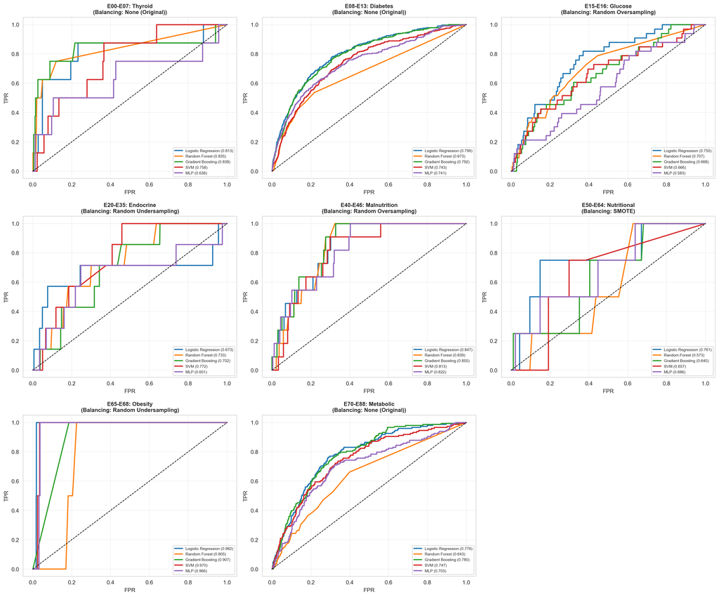

Figure 14: Figure 9. ROC Curves - ML Mortality Models by Disease Category (Best Class Balancing)

```python
n_cats_ml = len(ml_models_by_cat)
if n_cats_ml > 0:
    ncols = min(3, n_cats_ml)
    nrows = (n_cats_ml + ncols - 1) // ncols
    fig, axes = plt.subplots(nrows, ncols, figsize=(6 * ncols, 5 * nrows))
    if n_cats_ml == 1:
        axes = np.array([axes])
    axes = axes.flatten() if hasattr(axes, 'flatten') else [axes]

    for idx, (cat, results) in enumerate(ml_models_by_cat.items()):
        if not results:
            continue
        ax = axes[idx]
        best_balancing = ml_meta_by_cat[cat][3] if ml_meta_by_cat.get(cat) else ''
        for name, data in results.items():
            y_test = data['y_test']
            y_proba = data['y_proba']
            fpr, tpr, _ = roc_curve(y_test, y_proba)
            auc_val = data['metrics']['AUC']
            ax.plot(fpr, tpr, label=f'{name} ({auc_val:.3f})', linewidth=2)

        ax.plot([0, 1], [0, 1], 'k--', linewidth=1)
        ax.set_xlabel('FPR')
        ax.set_ylabel('TPR')
        ax.set_title(f'{cat}\n(Balancing: {best_balancing})', fontweight='bold', fontsize=10)
        ax.legend(fontsize=7, loc='lower right')
        ax.grid(True, alpha=0.3)

    for idx in range(len(ml_models_by_cat), len(axes)):
        axes[idx].set_visible(False)

    plt.tight_layout()
    plt.savefig('../data/output_files/endocrinas_parte2/roc_ml_mortality_by_category.png', dpi=1200, bbox_inches='tight')
    plt.show()
```

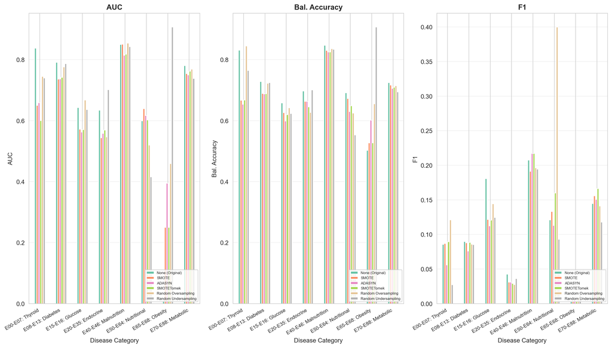

Figure 15: Figure 10. Class Balancing Technique AUC Comparison by Disease Category

```python
if len(ml_balancing_by_cat) > 0:
    comparison_data = []
    for cat, results in ml_balancing_by_cat.items():
        for bal_name, data in results.items():
            failed = data.get('failed', False)
            comparison_data.append({
                'Disease Category': cat,
                'Balancing': bal_name,
                'AUC': 0.0 if failed else data['metrics']['AUC'],
                'Bal. Accuracy': 0.0 if failed else data['metrics']['Bal. Accuracy'],
                'F1': 0.0 if failed else data['metrics']['F1'],
                'Failed': failed
            })

    comp_df = pd.DataFrame(comparison_data)
    bal_order = [b for b in ALL_BALANCING_NAMES if b in comp_df['Balancing'].unique()]
    comp_df['Balancing'] = pd.Categorical(comp_df['Balancing'], categories=bal_order, ordered=True)

    fig, axes = plt.subplots(1, 3, figsize=(14, 8))
    metrics_to_plot = ['AUC', 'Bal. Accuracy', 'F1']
    colors_resamp = plt.cm.Set2(np.linspace(0, 1, len(bal_order)))

    for ax_idx, metric in enumerate(metrics_to_plot):
        ax = axes[ax_idx]
        pivot = comp_df.pivot(index='Disease Category', columns='Balancing', values=metric)
        pivot = pivot[[c for c in bal_order if c in pivot.columns]]
        pivot.fillna(0).plot(kind='bar', ax=ax, color=colors_resamp[:len(pivot.columns)])
        ax.set_title(metric, fontweight='bold')
        ax.set_ylabel(metric)
        ax.legend(fontsize=6, loc='lower right')
        ax.grid(True, alpha=0.3, axis='y')
        plt.setp(ax.get_xticklabels(), rotation=30, ha='right', fontsize=8)

    plt.tight_layout()
    plt.savefig('../data/output_files/endocrinas_parte2/balancing_comparison_by_category.png', dpi=1200, bbox_inches='tight', facecolor='white')
    plt.show()
```

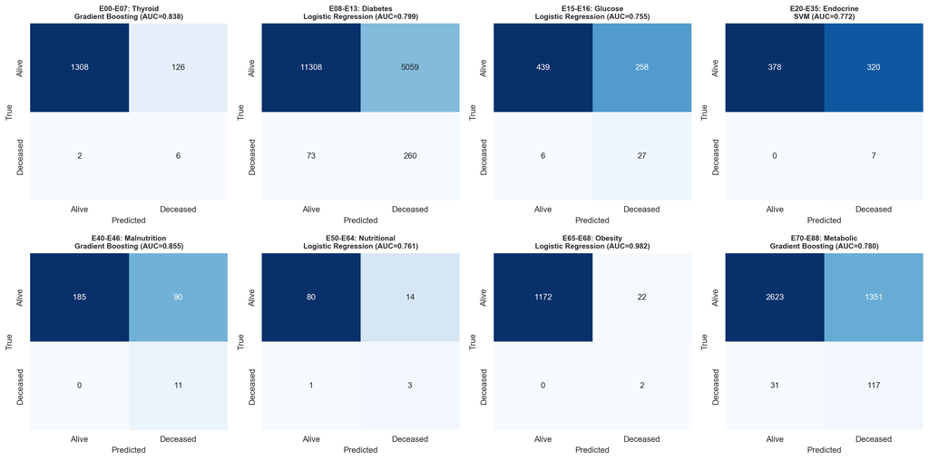

Figure 16: Figure 11. Confusion Matrices - Best ML Mortality Model per Category

```python
n_cats_ml = len(ml_models_by_cat)
if n_cats_ml > 0:
    ncols = min(4, n_cats_ml)
    nrows = (n_cats_ml + ncols - 1) // ncols
    fig, axes = plt.subplots(nrows, ncols, figsize=(4 * ncols, 4 * nrows))
    if n_cats_ml == 1:
        axes = np.array([axes])
    axes = axes.flatten() if hasattr(axes, 'flatten') else [axes]

    for idx, (cat, results) in enumerate(ml_models_by_cat.items()):
        if not results:
            continue
        best_name = max(results, key=lambda k: results[k]['metrics']['AUC'])
        best = results[best_name]
        cm = best['cm']

        ax = axes[idx]
        sns.heatmap(cm, annot=True, fmt='d', cmap='Blues', ax=ax, cbar=False,
                    xticklabels=['Alive', 'Deceased'], yticklabels=['Alive', 'Deceased'])
        ax.set_title(f'{cat}\n{best_name} (AUC={best["metrics"]["AUC"]:.3f})',
                     fontweight='bold', fontsize=9)
        ax.set_ylabel('True')
        ax.set_xlabel('Predicted')

    for idx in range(n_cats_ml, len(axes)):
        axes[idx].set_visible(False)

    plt.tight_layout()
    plt.savefig('../data/output_files/endocrinas_parte2/confusion_matrices_by_category.png', dpi=1200, bbox_inches='tight')
    plt.show()
```

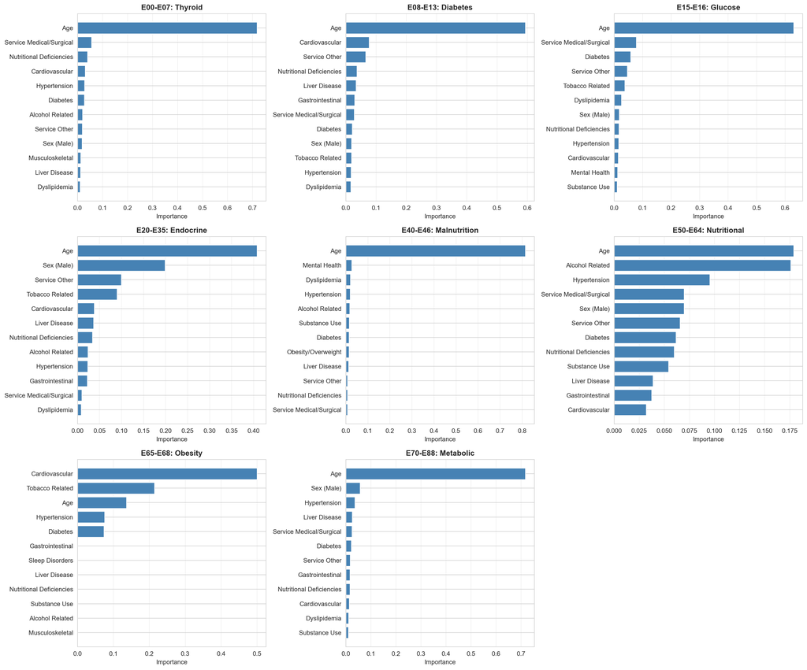

Figure 17: Figure 11B. Feature Importance - Gradient Boosting Mortality by Disease Category (Best Class Balancing)

```python
cats_with_gb = [c for c in ml_models_by_cat if ml_models_by_cat[c] and 'Gradient Boosting' in ml_models_by_cat[c]]
n_gb = len(cats_with_gb)

if n_gb > 0:
    ncols = min(3, n_gb)
    nrows = (n_gb + ncols - 1) // ncols
    fig, axes = plt.subplots(nrows, ncols, figsize=(6 * ncols, 5 * nrows))
    if n_gb == 1:
        axes = np.array([axes])
    axes = axes.flatten() if hasattr(axes, 'flatten') else [axes]

    for idx, cat in enumerate(cats_with_gb):
        model = ml_models_by_cat[cat]['Gradient Boosting']['model']
        feat_names = ml_meta_by_cat[cat][0]
        importances = model.feature_importances_
        formatted = [format_name(f) for f in feat_names]

        imp_df = pd.DataFrame({'Feature': formatted, 'Importance': importances})
        imp_df = imp_df.sort_values('Importance', ascending=True).tail(12)

        ax = axes[idx]
        ax.barh(imp_df['Feature'], imp_df['Importance'], color='steelblue')
        ax.set_xlabel('Importance')
        ax.set_title(f'{cat}', fontweight='bold')
        ax.grid(True, alpha=0.3, axis='x')

    for idx in range(n_gb, len(axes)):
        axes[idx].set_visible(False)

    plt.tight_layout()
    plt.savefig('../data/output_files/endocrinas_parte2/feat_importance_mortality_by_category.png', dpi=1200, bbox_inches='tight')
    plt.show()
```

# 9 9. Machine Learning Models for Length of Stay Prediction (Per Disease Category)

```python
from sklearn.ensemble import RandomForestRegressor, GradientBoostingRegressor
from sklearn.linear_model import LinearRegression, Ridge, Lasso
from sklearn.metrics import mean_squared_error, mean_absolute_error, r2_score

def run_ml_los_for_cat(df_cat, cat_name):
    """Train 5 ML regressors for LOS on a single disease category"""
    df_ml = df_cat[df_cat['length_of_stay'] > 0].copy()
    df_ml['age'] = pd.to_numeric(df_ml['age'], errors='coerce')

    svc_dummies = pd.get_dummies(df_ml['service_category'], prefix='service', drop_first=True)
    for c in svc_dummies.columns:
        df_ml[c] = svc_dummies[c]

    feature_names = ['age', 'male'] + list(svc_dummies.columns) + ml_comorbidity_cols
    target = 'length_of_stay'

    df_ml = df_ml[feature_names + [target]].dropna()

    if len(df_ml) < 80:
        return None, None

    X = df_ml[feature_names].values
    y = df_ml[target].values

    scaler = StandardScaler()
    X_scaled = scaler.fit_transform(X)

    X_train, X_test, y_train, y_test = train_test_split(
        X_scaled, y, test_size=0.2, random_state=42
    )

    models = {
        'Linear Regression': LinearRegression(),
        'Ridge': Ridge(alpha=1.0),
        'Lasso': Lasso(alpha=0.1, max_iter=5000),
        'Random Forest': RandomForestRegressor(n_estimators=100, random_state=42, n_jobs=-1),
        'Gradient Boosting': GradientBoostingRegressor(n_estimators=100, random_state=42)
    }

    results = {}
    for name, model in models.items():
        try:
            model.fit(X_train, y_train)
            y_pred = model.predict(X_test)

            results[name] = {
                'model': model, 'y_pred': y_pred, 'y_test': y_test,
                'metrics': {
                    'RMSE': np.sqrt(mean_squared_error(y_test, y_pred)),
                    'MAE': mean_absolute_error(y_test, y_pred),
                    'R2': r2_score(y_test, y_pred),
                    'MSE': mean_squared_error(y_test, y_pred)
                }
            }
        except:
            pass

    return results, feature_names

# Run ML LOS models for EACH disease category
ml_los_by_cat = {}
ml_los_features_by_cat = {}

for cat in all_categories:
    df_cat = df_endocrinas[df_endocrinas['endocrine_category'] == cat].copy()
    results, feat_names = run_ml_los_for_cat(df_cat, cat)
    if results and len(results) > 0:
        ml_los_by_cat[cat] = results
        ml_los_features_by_cat[cat] = feat_names
```

## 9.1 9.1 ML LOS Results by Disease Category

```python
# Table: ML LOS Performance by Category
for cat in all_categories:
    if cat not in ml_los_by_cat:
        continue

    results = ml_los_by_cat[cat]
    df_cat = df_endocrinas[df_endocrinas['endocrine_category'] == cat]
    n_total = len(df_cat)
    mean_los = df_cat['length_of_stay'].mean()

    metrics_df = pd.DataFrame({name: d['metrics'] for name, d in results.items()}).T
    metrics_df.index.name = 'Model'

    for col in metrics_df.columns:
        metrics_df[col] = metrics_df[col].apply(lambda x: '—' if (isinstance(x, float) and (np.isnan(x) or np.isinf(x))) else f'{x:.4f}')

    show_table(metrics_df,
               f"ML LOS Performance: {cat} (N={n_total:,}, Mean LOS={mean_los:.1f} days)",
               index=True)
```

ML LOS Performance: E00-E07: Thyroid (N=7,209, Mean LOS=4.4 days)

| Model | RMSE | MAE | R2 | MSE |
| --- | --- | --- | --- | --- |
| Linear Regression | 7.6945 | 3.2893 | 0.1686 | 59.2054 |
| Ridge | 7.6946 | 3.2893 | 0.1685 | 59.2062 |
| Lasso | 7.7393 | 3.2880 | 0.1588 | 59.8967 |
| Random Forest | 8.3267 | 3.7040 | 0.0263 | 69.3345 |
| Gradient Boosting | 7.7257 | 3.2389 | 0.1618 | 59.6868 |

ML LOS Performance: E08-E13: Diabetes (N=83,496, Mean LOS=10.4 days)

| Model | RMSE | MAE | R2 | MSE |
| --- | --- | --- | --- | --- |
| Linear Regression | 14.2334 | 8.5259 | 0.0682 | 202.5907 |
| Ridge | 14.2334 | 8.5259 | 0.0682 | 202.5907 |
| Lasso | 14.2307 | 8.5184 | 0.0686 | 202.5115 |
| Random Forest | 16.0735 | 9.4948 | -0.1882 | 258.3578 |
| Gradient Boosting | 14.1542 | 8.4270 | 0.0786 | 200.3406 |

ML LOS Performance: E15-E16: Glucose (N=3,646, Mean LOS=6.2 days)

| Model | RMSE | MAE | R2 | MSE |
| --- | --- | --- | --- | --- |
| Linear Regression | 10.7902 | 5.3715 | 0.0904 | 116.4278 |
| Ridge | 10.7903 | 5.3713 | 0.0904 | 116.4307 |
| Lasso | 10.7951 | 5.3569 | 0.0896 | 116.5333 |
| Random Forest | 11.4960 | 5.6608 | -0.0325 | 132.1578 |
| Gradient Boosting | 10.5153 | 5.1183 | 0.1361 | 110.5725 |

ML LOS Performance: E20-E35: Endocrine (N=3,524, Mean LOS=9.4 days)

| Model | RMSE | MAE | R2 | MSE |
| --- | --- | --- | --- | --- |
| Linear Regression | 10.1559 | 6.6502 | 0.0487 | 103.1432 |
| Ridge | 10.1557 | 6.6501 | 0.0487 | 103.1378 |
| Lasso | 10.1028 | 6.6252 | 0.0586 | 102.0674 |
| Random Forest | 11.7803 | 7.3891 | -0.2800 | 138.7750 |
| Gradient Boosting | 12.2387 | 6.7186 | -0.3816 | 149.7852 |

ML LOS Performance: E40-E46: Malnutrition (N=1,426, Mean LOS=15.2 days)

| Model | RMSE | MAE | R2 | MSE |
| --- | --- | --- | --- | --- |
| Linear Regression | 20.1877 | 12.5445 | 0.0071 | 407.5450 |
| Ridge | 20.1858 | 12.5428 | 0.0073 | 407.4669 |
| Lasso | 20.1277 | 12.4457 | 0.0130 | 405.1258 |
| Random Forest | 21.6564 | 12.7246 | -0.1426 | 469.0008 |
| Gradient Boosting | 20.3880 | 12.0511 | -0.0127 | 415.6706 |

ML LOS Performance: E50-E64: Nutritional (N=490, Mean LOS=16.5 days)

| Model | RMSE | MAE | R2 | MSE |
| --- | --- | --- | --- | --- |
| Linear Regression | 19.7149 | 13.3785 | -0.2196 | 388.6783 |
| Ridge | 19.6239 | 13.3267 | -0.2084 | 385.0994 |
| Lasso | 19.5324 | 13.1860 | -0.1972 | 381.5134 |
| Random Forest | 99.7919 | 23.9311 | -30.2486 | 9958.4140 |
| Gradient Boosting | 171.9154 | 35.1634 | -91.7405 | 29554.9148 |

ML LOS Performance: E65-E68: Obesity (N=5,980, Mean LOS=2.9 days)

| Model | RMSE | MAE | R2 | MSE |
| --- | --- | --- | --- | --- |
| Linear Regression | 4.5447 | 1.7063 | 0.1834 | 20.6546 |
| Ridge | 4.5447 | 1.7063 | 0.1835 | 20.6543 |
| Lasso | 4.5343 | 1.6618 | 0.1872 | 20.5601 |
| Random Forest | 5.0472 | 1.8645 | -0.0071 | 25.4744 |
| Gradient Boosting | 4.9698 | 1.7546 | 0.0236 | 24.6989 |

ML LOS Performance: E70-E88: Metabolic (N=20,607, Mean LOS=6.3 days)

| Model | RMSE | MAE | R2 | MSE |
| --- | --- | --- | --- | --- |
| Linear Regression | 11.6292 | 5.5056 | 0.0764 | 135.2376 |
| Ridge | 11.6292 | 5.5056 | 0.0764 | 135.2374 |
| Lasso | 11.6252 | 5.4862 | 0.0770 | 135.1453 |
| Random Forest | 14.8492 | 5.8441 | -0.5059 | 220.4973 |
| Gradient Boosting | 11.8562 | 5.2440 | 0.0400 | 140.5700 |

ML LOS Performance: E89: Postprocedural (N=280, Mean LOS=6.7 days)

| Model | RMSE | MAE | R2 | MSE |
| --- | --- | --- | --- | --- |
| Linear Regression | 6.2897 | 5.0511 | -0.4187 | 39.5604 |
| Ridge | 6.2755 | 5.0417 | -0.4123 | 39.3814 |
| Lasso | 6.0272 | 4.8760 | -0.3028 | 36.3274 |
| Random Forest | 6.6140 | 4.5889 | -0.5688 | 43.7452 |
| Gradient Boosting | 7.0493 | 4.7110 | -0.7821 | 49.6927 |

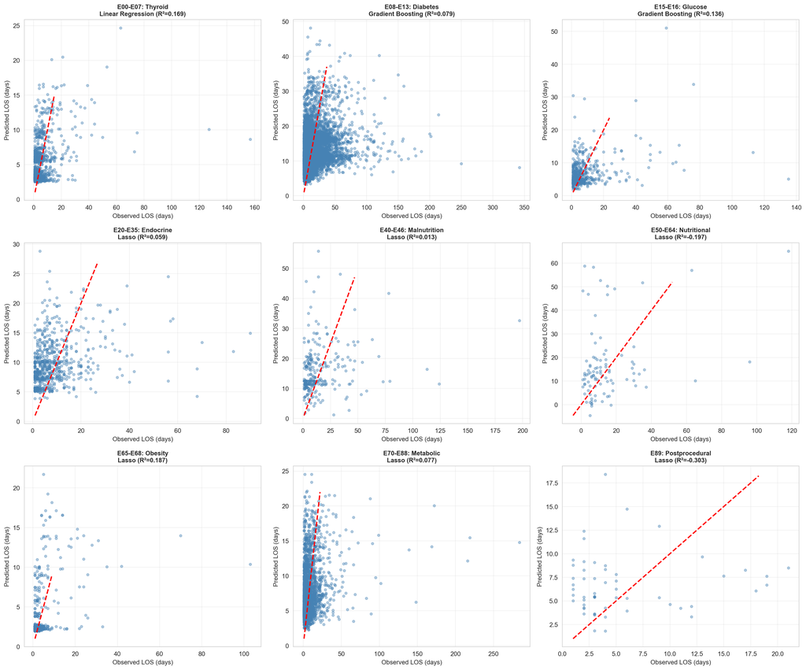

Figure 18: Figure 12. Predicted vs Observed LOS - Best ML Model per Category

```python
n_cats_los = len(ml_los_by_cat)
if n_cats_los > 0:
    ncols = min(3, n_cats_los)
    nrows = (n_cats_los + ncols - 1) // ncols
    fig, axes = plt.subplots(nrows, ncols, figsize=(6 * ncols, 5 * nrows))
    if n_cats_los == 1:
        axes = np.array([axes])
    axes = axes.flatten() if hasattr(axes, 'flatten') else [axes]

    for idx, (cat, results) in enumerate(ml_los_by_cat.items()):
        best_name = max(results, key=lambda k: results[k]['metrics']['R2'])
        best = results[best_name]
        y_test = best['y_test']
        y_pred = best['y_pred']
        r2 = best['metrics']['R2']

        ax = axes[idx]
        ax.scatter(y_test, y_pred, alpha=0.4, s=15, color='steelblue')
        lims = [min(y_test.min(), y_pred.min()), max(np.percentile(y_test, 95), np.percentile(y_pred, 95))]
        ax.plot(lims, lims, 'r--', lw=2)
        ax.set_xlabel('Observed LOS (days)')
        ax.set_ylabel('Predicted LOS (days)')
        ax.set_title(f'{cat}\n{best_name} (R²={r2:.3f})', fontweight='bold', fontsize=10)
        ax.grid(True, alpha=0.3)

    for idx in range(n_cats_los, len(axes)):
        axes[idx].set_visible(False)

    plt.tight_layout()
    plt.savefig('../data/output_files/endocrinas_parte2/pred_vs_obs_los_by_category.png', dpi=1200, bbox_inches='tight')
    plt.show()
```

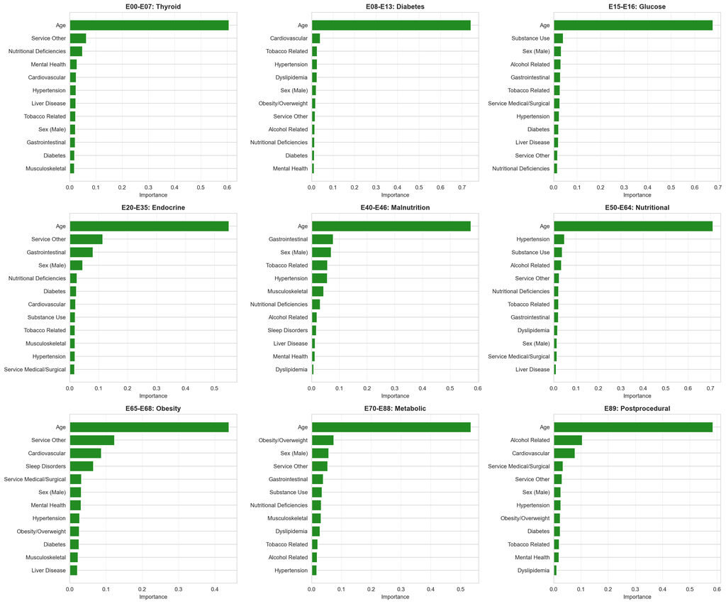

Figure 19: Figure 13. Feature Importance - Random Forest LOS by Disease Category

```python
cats_with_rf_los = [c for c in ml_los_by_cat if 'Random Forest' in ml_los_by_cat[c]]
n_rf_los = len(cats_with_rf_los)

if n_rf_los > 0:
    ncols = min(3, n_rf_los)
    nrows = (n_rf_los + ncols - 1) // ncols
    fig, axes = plt.subplots(nrows, ncols, figsize=(6 * ncols, 5 * nrows))
    if n_rf_los == 1:
        axes = np.array([axes])
    axes = axes.flatten() if hasattr(axes, 'flatten') else [axes]

    for idx, cat in enumerate(cats_with_rf_los):
        model = ml_los_by_cat[cat]['Random Forest']['model']
        feat_names = ml_los_features_by_cat[cat]
        importances = model.feature_importances_
        formatted = [format_name(f) for f in feat_names]

        imp_df = pd.DataFrame({'Feature': formatted, 'Importance': importances})
        imp_df = imp_df.sort_values('Importance', ascending=True).tail(12)

        ax = axes[idx]
        ax.barh(imp_df['Feature'], imp_df['Importance'], color='forestgreen')
        ax.set_xlabel('Importance')
        ax.set_title(f'{cat}', fontweight='bold')
        ax.grid(True, alpha=0.3, axis='x')

    for idx in range(n_rf_los, len(axes)):
        axes[idx].set_visible(False)

    plt.tight_layout()
    plt.savefig('../data/output_files/endocrinas_parte2/feat_importance_los_by_category.png', dpi=1200, bbox_inches='tight')
    plt.show()
```

# 10 10. Summary Comparison Table

```python
# Combined summary: best model per category for mortality and LOS
summary_rows = []
for cat in all_categories:
    row = {'Disease Category': cat}
    df_cat = df_endocrinas[df_endocrinas['endocrine_category'] == cat]
    row['N'] = f'{len(df_cat):,}'
    row['Mortality %'] = f'{df_cat["mortality"].mean()*100:.1f}'
    row['Mean LOS'] = f'{df_cat["length_of_stay"].mean():.1f}'

    # GEE Logistic regression AUC
    if cat in gee_mortality_results:
        try:
            result = gee_mortality_results[cat]
            df_gee = gee_mortality_models[cat][1]
            y_proba = result.fittedvalues
            y_actual = df_gee['mortality'].values
            row['GEE Mortality AUC'] = f'{roc_auc_score(y_actual, y_proba):.3f}'
        except:
            row['GEE Mortality AUC'] = '—'
    else:
        row['GEE Mortality AUC'] = '—'

    # Best ML mortality AUC
    if cat in ml_models_by_cat and ml_models_by_cat[cat]:
        best_name = max(ml_models_by_cat[cat], key=lambda k: ml_models_by_cat[cat][k]['metrics']['AUC'])
        best_auc = ml_models_by_cat[cat][best_name]['metrics']['AUC']
        best_balancing = ml_meta_by_cat[cat][3] if ml_meta_by_cat.get(cat) else 'Unknown'
        row['Best ML Mortality AUC'] = f'{best_auc:.3f} ({best_name}, {best_balancing})'
    else:
        row['Best ML Mortality AUC'] = '—'

    # GEE LOS RMSE
    if cat in gee_los_results:
        try:
            result = gee_los_results[cat]
            df_gee = gee_los_models[cat][1]
            y_pred = result.fittedvalues
            y_actual = df_gee['length_of_stay'].values
            rmse = np.sqrt(np.mean((y_actual - y_pred) ** 2))
            row['GEE LOS RMSE'] = f'{rmse:.2f}'
        except:
            row['GEE LOS RMSE'] = '—'
    else:
        row['GEE LOS RMSE'] = '—'

    # Best ML LOS R²
    if cat in ml_los_by_cat:
        best_name = max(ml_los_by_cat[cat], key=lambda k: ml_los_by_cat[cat][k]['metrics']['R2'])
        best_r2 = ml_los_by_cat[cat][best_name]['metrics']['R2']
        row['Best ML R² (LOS)'] = f'{best_r2:.3f} ({best_name})'
    else:
        row['Best ML R² (LOS)'] = '—'

    summary_rows.append(row)

summary_df = pd.DataFrame(summary_rows)
show_table(summary_df, "Table 13: Summary - GEE & ML Model Performance Across All Disease Categories\n(GEE: Mixed-Effects with hospital clustering; ML: Multiple Class Balancing Techniques)", index=False)
```

Table 13: Summary - GEE & ML Model Performance Across All Disease Categories (GEE: Mixed-Effects with hospital clustering; ML: Multiple Class Balancing Techniques)

| Disease Category | N | Mortality % | Mean LOS | GEE Mortality AUC | Best ML Mortality AUC | GEE LOS RMSE | Best ML R² (LOS) |
| --- | --- | --- | --- | --- | --- | --- | --- |
| E00-E07: Thyroid | 7,209 | 0.5 | 4.4 | 0.955 | 0.838 (Gradient Boosting, None (Original)) | 7.60 | 0.169 (Linear Regression) |
| E08-E13: Diabetes | 83,496 | 2.0 | 10.4 | 0.908 | 0.799 (Logistic Regression, None (Original)) | 14.61 | 0.079 (Gradient Boosting) |
| E15-E16: Glucose | 3,646 | 4.5 | 6.2 | 0.865 | 0.755 (Logistic Regression, Random Oversampling) | 13.30 | 0.136 (Gradient Boosting) |
| E20-E35: Endocrine | 3,524 | 1.0 | 9.4 | — | 0.772 (SVM, Random Undersampling) | 15.77 | 0.059 (Lasso) |
| E40-E46: Malnutrition | 1,426 | 3.8 | 15.2 | 0.903 | 0.855 (Gradient Boosting, Random Oversampling) | 29.05 | 0.013 (Lasso) |
| E50-E64: Nutritional | 490 | 3.7 | 16.5 | 0.767 | 0.761 (Logistic Regression, SMOTE) | 58.84 | -0.197 (Lasso) |
| E65-E68: Obesity | 5,980 | 0.1 | 2.9 | — | 0.982 (Logistic Regression, Random Undersampling) | 4.90 | 0.187 (Lasso) |
| E70-E88: Metabolic | 20,607 | 3.6 | 6.3 | 0.864 | 0.780 (Gradient Boosting, None (Original)) | 14.63 | 0.077 (Lasso) |
| E89: Postprocedural | 280 | 0.4 | 6.7 | — | — | 7.53 | -0.303 (Lasso) |

# 11 11. Discussion

## 11.1 11.1 Key Findings

This analysis of endocrine, nutritional and metabolic diseases in Chile (2019-2024) provides independent regression and machine learning models for each disease category, enabling category-specific risk assessment for both in-hospital mortality and length of stay.

## 11.2 11.2 Regression Model Approach

Mixed-effects models were fit using Generalized Estimating Equations (GEE) to account for the hierarchical structure of observations within hospitals and years. For mortality, GEE logistic regression was used with Binomial family and exchangeable correlation structure. For length of stay, GEE negative binomial regression was used to account for overdispersion in count data, with Poisson as fallback. All models include age, sex, service category, severity/mortality indices, and only significant comorbidities from bivariate analysis (p < 0.05), improving parsimony and interpretability. Hospital was specified as the grouping variable to capture clustering effects.

## 11.3 11.3 Machine Learning Approach

To address class imbalance and improve generalization, multiple class balancing techniques were evaluated: SMOTE, ADASYN, SMOTETomek, random oversampling, random undersampling, and no balancing (original). For each disease category, gradient boosting was used as the base model to identify the best-performing balancing method by AUC. Subsequently, five classifiers (Logistic Regression, Random Forest, Gradient Boosting, SVM, MLP) were trained using the optimal balancing strategy. All models used optimal decision thresholds derived from Youden’s J statistic rather than default 0.5 cutoff, improving balanced accuracy and clinical utility.

# 12 12. Conclusion

This analysis provides a comprehensive epidemiological profile of endocrine, nutritional and metabolic diseases in Chilean public hospitals. The results highlight the importance of comorbidity screening, the differential impact of lifestyle-related factors by disease category, and temporal patterns that may inform resource allocation and clinical practice.

**Analysis of endocrine, nutritional and metabolic diseases in Chile using GRD public hospital discharge records (2019-2024). This document provides a comprehensive statistical analysis following mixed-effects modeling methodology with machine learning validation.**

# 13 References

Breiman, Leo. 2001. “Random Forests.” *Machine Learning* 45 (1): 5–32. https://doi.org/10.1023/A:1010933404324.

Charlson, Mary E., Peter Pompei, Kathy L. Ales, and C. Ronald MacKenzie. 1987. “A New Method of Classifying Prognostic Comorbidity in Longitudinal Studies: Development and Validation.” *Journal of Chronic Diseases* 40 (5): 373–83. https://doi.org/10.1016/0021-9681(87)90171-8.

Chawla, Nitesh V., Kevin W. Bowyer, Lawrence O. Hall, and W. Philip Kegelmeyer. 2002. “SMOTE: Synthetic Minority Over-Sampling Technique.” *Journal of Artificial Intelligence Research* 16: 321–57. https://doi.org/10.1613/jair.953.

Departamento de Estadı́sticas e Información de Salud (DEIS). 2024. *Bases de Datos de Grupos Relacionados de Diagnóstico (GRD), 2019–2024*. [Https://deis.minsal.cl/](https://deis.minsal.cl/).

Friedman, Jerome H. 2001. “Greedy Function Approximation: A Gradient Boosting Machine.” *Annals of Statistics* 29 (5): 1189–232.

Hosmer, David W., Stanley Lemeshow, and Rodney X. Sturdivant. 2013. “Applied Logistic Regression.” *Wiley Series in Probability and Statistics*, ahead of print, 3rd ed. https://doi.org/10.1002/9781118548387.

Hubbard, Alan E., Jennifer Ahern, Nancy L. Fleischer, et al. 2010. “To GEE or Not to GEE: Comparing Population Average and Mixed Models for Estimating the Associations Between Neighborhood Risk Factors and Health.” *Epidemiology* 21 (4): 467–74. https://doi.org/10.1097/EDE.0b013e3181caeb90.

Hunter, John D. 2007. “Matplotlib: A 2D Graphics Environment.” *Computing in Science & Engineering* 9 (3): 90–95. https://doi.org/10.1109/MCSE.2007.55.

Khan, Muhammad A. B., Muhammad J. Hashim, Jeffrey K. King, Romona D. Govender, Halla Mustafa, and Juma Al Kaabi. 2020. “Epidemiology of Type 2 Diabetes—Global Burden of Disease and Forecasted Trends.” *Journal of Epidemiology and Global Health* 10 (1): 107–11. https://doi.org/10.2991/jegh.k.191028.001.

Liang, Kung-Yee, and Scott L. Zeger. 1986. “Longitudinal Data Analysis Using Generalized Linear Models.” *Biometrika* 73 (1): 13–22. https://doi.org/10.1093/biomet/73.1.13.

McKinney, Wes. 2010. “Data Structures for Statistical Computing in Python.” *Proceedings of the 9th Python in Science Conference*, 56–61.

Organización Mundial de la Salud. 2019. *Clasificación Estadı́stica Internacional de Enfermedades y Problemas Relacionados Con La Salud, décima Revisión (CIE-10)*. OMS.

Pedregosa, Fabian, Gaël Varoquaux, Alexandre Gramfort, et al. 2011. “Scikit-Learn: Machine Learning in Python.” *Journal of Machine Learning Research* 12: 2825–30.

Pigeyre, Marie, Fereshteh T. Yazdi, Yuvreet Kaur, and David Meyre. 2016. “Recent Progress in Genetics, Epigenetics and Metagenomics Unveils the Pathophysiology of Human Obesity.” *Clinical Science* 130 (12): 943–86. https://doi.org/10.1042/CS20160136.

Saeedi, Pouya, Inga Petersohn, Paraskevi Salpea, et al. 2019. “Global and Regional Diabetes Prevalence Estimates for 2019 and Projections for 2030 and 2045: Results from the IDF Diabetes Atlas, 9th Edition.” *Diabetes Research and Clinical Practice* 157: 107843. https://doi.org/10.1016/j.diabres.2019.107843.

Sapunar, Jorge, Nicolás Aguilar-Farias, Gonzalo Navarro, et al. 2018. “High Prevalence of Overweight and Obesity in Chilean Adults with Type 2 Diabetes.” *Revista Médica de Chile* 146 (3): 279–86. https://doi.org/10.4067/s0034-98872018000300279.

Seabold, Skipper, and Josef Perktold. 2010. “Statsmodels: Econometric and Statistical Modeling with Python.” *Proceedings of the 9th Python in Science Conference*, 92–96.

Taylor, Peter N., Diana Albrecht, Anna Scholz, et al. 2018. “Global Epidemiology of Hyperthyroidism and Hypothyroidism.” *Nature Reviews Endocrinology* 14 (5): 301–16. https://doi.org/10.1038/nrendo.2018.18.

Valderas, José M., Barbara Starfield, Bonnie Sibbald, Chris Salisbury, and Martin Roland. 2009. “Defining Comorbidity: Implications for Understanding Health and Health Services.” *Annals of Family Medicine* 7 (4): 357–63. https://doi.org/10.1370/afm.983.

Youden, William J. 1950. “Index for Rating Diagnostic Tests.” *Cancer* 3 (1): 32–35. https://doi.org/10.1002/1097-0142(1950)3:1<32::AID-CNCR2820030106>3.0.CO;2-3.

Zeger, Scott L., and Kung-Yee Liang. 1986. “Longitudinal Data Analysis for Discrete and Continuous Outcomes.” *Biometrics* 42 (1): 121–30. https://doi.org/10.2307/2531248.

# 14 Composite Figure — Publication Summary

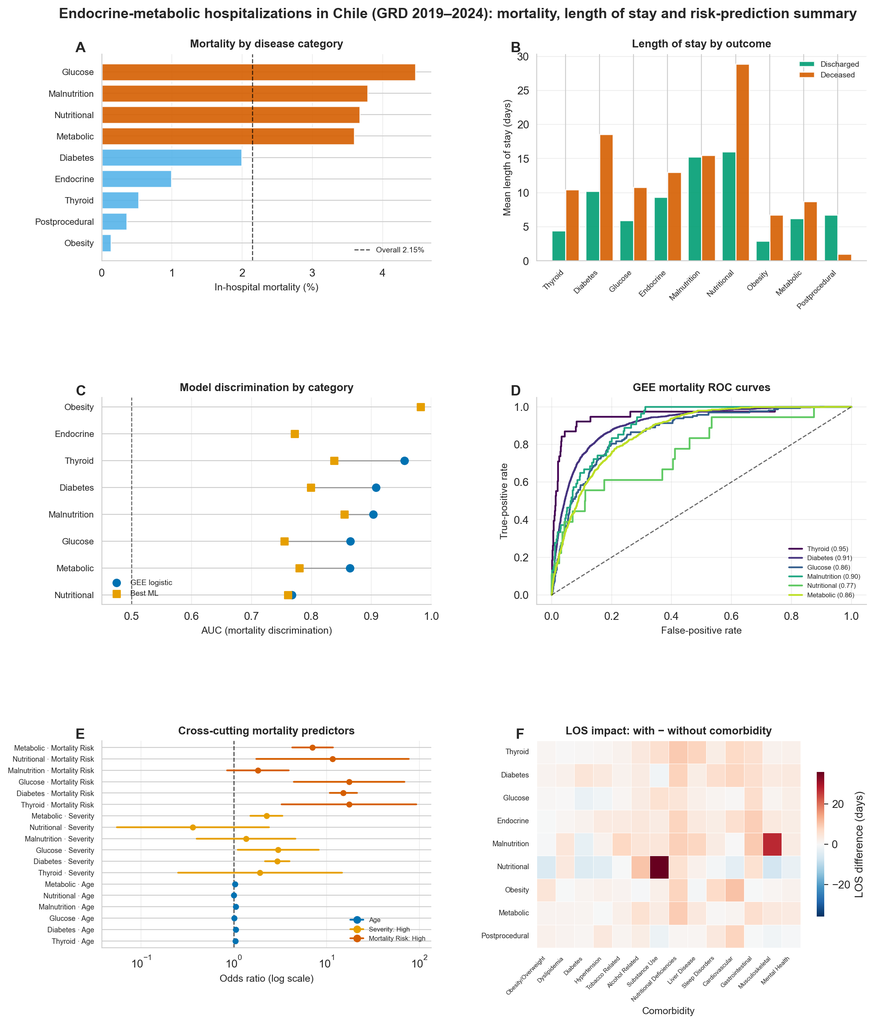

Figure 20: Composite summary of the most relevant results. (A) In-hospital mortality rate by endocrine disease category; (B) mean length of stay by category for discharged vs deceased patients; (C) model discrimination (AUC) comparing GEE logistic regression with the best machine-learning classifier per category; (D) ROC curves of the GEE mortality models; (E) cross-cutting GEE odds ratios for age, severity and mortality-risk predictors; (F) length-of-stay impact (days, WITH minus WITHOUT comorbidity) across categories.

```python
import re as _re

# Colorblind-safe Okabe-Ito palette
_okabe = ['#E69F00', '#56B4E9', '#009E73', '#F0E442', '#0072B2', '#D55E00', '#CC79A7', '#000000']

def _short_cat(c):
    """Drop the 'Exx-Exx: ' code prefix for compact axis labels."""
    s = str(c)
    return s.split(':', 1)[1].strip() if ':' in s else s

def _parse_lead(txt):
    """Extract the leading numeric estimate from an 'OR [lo, hi]sig' string."""
    m = _re.match(r'\s*([0-9]*\.?[0-9]+)', str(txt))
    return float(m.group(1)) if m else np.nan

def _parse_ci(txt):
    """Extract (est, lo, hi) from an 'est [lo, hi]sig' string."""
    est = _parse_lead(txt)
    m = _re.search(r'\[\s*([0-9]*\.?[0-9]+)\s*,\s*([0-9]*\.?[0-9]+)\s*\]', str(txt))
    if m:
        return est, float(m.group(1)), float(m.group(2))
    return est, np.nan, np.nan

panel_labels = ['A', 'B', 'C', 'D', 'E', 'F']
fig = plt.figure(figsize=(11, 13))
gs = fig.add_gridspec(3, 2, hspace=0.66, wspace=0.32,
                      left=0.09, right=0.97, top=0.93, bottom=0.06)
axes = [fig.add_subplot(gs[r, c]) for r in range(3) for c in range(2)]
for ax, lab in zip(axes, panel_labels):
    ax.text(-0.08, 1.06, lab, transform=ax.transAxes, fontsize=13,
            fontweight='bold', va='top')

# ---- Panel A: mortality rate (%) by disease category ----
ax = axes[0]
try:
    mort = (df_endocrinas.groupby('endocrine_category')['mortality'].mean() * 100)
    mort = mort.dropna().sort_values(ascending=True)
    ylabs = [_short_cat(c) for c in mort.index]
    overall = df_endocrinas['mortality'].mean() * 100
    bar_colors = ['#D55E00' if v > overall else '#56B4E9' for v in mort.values]
    ax.barh(range(len(mort)), mort.values, color=bar_colors, alpha=0.9)
    ax.axvline(overall, color='black', ls='--', lw=1.0, alpha=0.7,
               label=f'Overall {overall:.2f}%')
    ax.set_yticks(range(len(mort)))
    ax.set_yticklabels(ylabs, fontsize=8)
    ax.set_xlabel('In-hospital mortality (%)', fontsize=9)
    ax.set_title('Mortality by disease category', fontsize=10, fontweight='bold')
    ax.legend(fontsize=7, loc='lower right', frameon=False)
    sns.despine(ax=ax)
    ax.grid(True, axis='x', alpha=0.3)
except Exception as e:
    ax.axis('off'); ax.text(0.5, 0.5, 'panel unavailable', ha='center', va='center',
                            fontsize=8, transform=ax.transAxes)

# ---- Panel B: mean LOS by category, discharged vs deceased ----
ax = axes[1]
try:
    cats_b = sorted(df_endocrinas['endocrine_category'].dropna().unique())
    means_dis, means_dec = [], []
    for c in cats_b:
        d = df_endocrinas[df_endocrinas['endocrine_category'] == c]
        means_dis.append(d.loc[d['mortality'] == 0, 'length_of_stay'].mean())
        means_dec.append(d.loc[d['mortality'] == 1, 'length_of_stay'].mean())
    x = np.arange(len(cats_b)); w = 0.4
    ax.bar(x - w/2, means_dis, w, label='Discharged', color='#009E73', alpha=0.9)
    ax.bar(x + w/2, means_dec, w, label='Deceased', color='#D55E00', alpha=0.9)
    ax.set_xticks(x)
    ax.set_xticklabels([_short_cat(c) for c in cats_b], rotation=45, ha='right', fontsize=7)
    ax.set_ylabel('Mean length of stay (days)', fontsize=9)
    ax.set_title('Length of stay by outcome', fontsize=10, fontweight='bold')
    ax.legend(fontsize=7, frameon=False)
    sns.despine(ax=ax)
    ax.grid(True, axis='y', alpha=0.3)
except Exception as e:
    ax.axis('off'); ax.text(0.5, 0.5, 'panel unavailable', ha='center', va='center',
                            fontsize=8, transform=ax.transAxes)

# ---- Panel C: GEE vs best-ML AUC per category ----
ax = axes[2]
try:
    sdf = summary_df.copy()
    sdf['gee_auc'] = pd.to_numeric(sdf['GEE Mortality AUC'], errors='coerce')
    sdf['ml_auc'] = sdf['Best ML Mortality AUC'].apply(_parse_lead)
    sdf = sdf.dropna(subset=['gee_auc', 'ml_auc'], how='all')
    sdf = sdf.sort_values('gee_auc', ascending=True)
    yc = np.arange(len(sdf))
    ax.scatter(sdf['gee_auc'], yc, s=45, color='#0072B2', label='GEE logistic', zorder=3)
    ax.scatter(sdf['ml_auc'], yc, s=45, color='#E69F00', marker='s',
               label='Best ML', zorder=3)
    for yi, (g, m) in enumerate(zip(sdf['gee_auc'], sdf['ml_auc'])):
        if np.isfinite(g) and np.isfinite(m):
            ax.plot([g, m], [yi, yi], color='#999999', lw=1.0, zorder=2)
    ax.axvline(0.5, color='black', ls='--', lw=0.9, alpha=0.6)
    ax.set_yticks(yc)
    ax.set_yticklabels([_short_cat(c) for c in sdf['Disease Category']], fontsize=8)
    ax.set_xlabel('AUC (mortality discrimination)', fontsize=9)
    ax.set_xlim(0.45, 1.0)
    ax.set_title('Model discrimination by category', fontsize=10, fontweight='bold')
    ax.legend(fontsize=7, loc='lower left', frameon=False)
    sns.despine(ax=ax)
    ax.grid(True, axis='x', alpha=0.3)
except Exception as e:
    ax.axis('off'); ax.text(0.5, 0.5, 'panel unavailable', ha='center', va='center',
                            fontsize=8, transform=ax.transAxes)

# ---- Panel D: ROC curves of GEE mortality models ----
ax = axes[3]
try:
    cats_d = [c for c in all_categories if c in gee_mortality_results]
    cmap_d = plt.cm.viridis(np.linspace(0, 0.9, max(len(cats_d), 1)))
    plotted = 0
    for i, c in enumerate(cats_d):
        try:
            res = gee_mortality_results[c]
            df_g = gee_mortality_models[c][1]
            y_true = df_g['mortality'].values
            y_sc = np.asarray(res.fittedvalues, dtype=float)
            if len(np.unique(y_true)) < 2:
                continue
            fpr, tpr, _ = roc_curve(y_true, y_sc)
            a = roc_auc_score(y_true, y_sc)
            ax.plot(fpr, tpr, lw=1.6, color=cmap_d[i],
                    label=f'{_short_cat(c)} ({a:.2f})')
            plotted += 1
        except Exception:
            continue
    ax.plot([0, 1], [0, 1], 'k--', lw=1.0, alpha=0.6)
    ax.set_xlabel('False-positive rate', fontsize=9)
    ax.set_ylabel('True-positive rate', fontsize=9)
    ax.set_title('GEE mortality ROC curves', fontsize=10, fontweight='bold')
    if plotted:
        ax.legend(fontsize=6, loc='lower right', frameon=False, ncol=1)
    sns.despine(ax=ax)
    ax.grid(True, alpha=0.3)
except Exception as e:
    ax.axis('off'); ax.text(0.5, 0.5, 'panel unavailable', ha='center', va='center',
                            fontsize=8, transform=ax.transAxes)

# ---- Panel E: cross-cutting GEE odds ratios (age, severity, mortality risk) ----
ax = axes[4]
try:
    target_vars = ['Age', 'Severity: High', 'Mortality Risk: High']
    cats_e = [c for c in all_categories if c in gee_or_table]
    cmap_e = dict(zip(target_vars, ['#0072B2', '#E69F00', '#D55E00']))
    yticks, yticklabels = [], []
    ypos = 0
    any_drawn = False
    for var in target_vars:
        for c in cats_e:
            cell = gee_or_table.get(c, {}).get(var)
            if cell is None:
                continue
            est, lo, hi = _parse_ci(cell)
            if not np.isfinite(est):
                continue
            ax.plot([lo, hi], [ypos, ypos], color=cmap_e[var], lw=1.6,
                    solid_capstyle='round', zorder=2)
            ax.plot([est], [ypos], 'o', color=cmap_e[var], ms=4.5, zorder=3)
            yticks.append(ypos)
            yticklabels.append(f'{_short_cat(c)} · {var.split(":")[0]}')
            ypos += 1
            any_drawn = True
    if not any_drawn:
        raise ValueError('no estimable cross-cutting predictors')
    ax.axvline(1.0, color='black', ls='--', lw=1.0, alpha=0.7, zorder=1)
    ax.set_xscale('log')
    ax.set_yticks(yticks)
    ax.set_yticklabels(yticklabels, fontsize=6.5)
    ax.set_ylim(-0.6, ypos - 0.4)
    ax.set_xlabel('Odds ratio (log scale)', fontsize=9)
    ax.set_title('Cross-cutting mortality predictors', fontsize=10, fontweight='bold')
    handles = [plt.Line2D([0], [0], color=cmap_e[v], marker='o', lw=1.6, label=v)
               for v in target_vars]
    ax.legend(handles=handles, fontsize=6, loc='lower right', frameon=False)
    sns.despine(ax=ax)
    ax.grid(True, axis='x', alpha=0.3)
except Exception as e:
    ax.axis('off'); ax.text(0.5, 0.5, 'panel unavailable', ha='center', va='center',
                            fontsize=8, transform=ax.transAxes)

# ---- Panel F: LOS impact heatmap (WITH - WITHOUT comorbidity) ----
ax = axes[5]
try:
    hm = heatmap_los_impact_df.copy()
    hm.index = [_short_cat(c) for c in hm.index]
    vmax = float(np.nanmax(np.abs(hm.values))) if hm.size else 1.0
    vmax = vmax if np.isfinite(vmax) and vmax > 0 else 1.0
    sns.heatmap(hm, ax=ax, cmap='RdBu_r', center=0, vmin=-vmax, vmax=vmax,
                cbar_kws={'label': 'LOS difference (days)', 'shrink': 0.7},
                linewidths=0.3, linecolor='white')
    ax.set_title('LOS impact: with − without comorbidity', fontsize=10, fontweight='bold')
    ax.set_xlabel('Comorbidity', fontsize=9)
    ax.set_ylabel('')
    plt.setp(ax.get_xticklabels(), rotation=45, ha='right', fontsize=5.5)
    plt.setp(ax.get_yticklabels(), rotation=0, fontsize=6.5)
except Exception as e:
    ax.axis('off'); ax.text(0.5, 0.5, 'panel unavailable', ha='center', va='center',
                            fontsize=8, transform=ax.transAxes)

fig.suptitle('Endocrine-metabolic hospitalizations in Chile (GRD 2019–2024): '
             'mortality, length of stay and risk-prediction summary',
             fontsize=13, fontweight='bold', y=0.975)

import os as _os
_os.makedirs('../data/output_files/endocrinas_parte2', exist_ok=True)
plt.savefig('../data/output_files/endocrinas_parte2/composite_summary.png',
            dpi=1200, bbox_inches='tight', facecolor='white')
plt.show()
```

# 15 Composite Figure — Mortality: Burden, Discrimination and Predictors

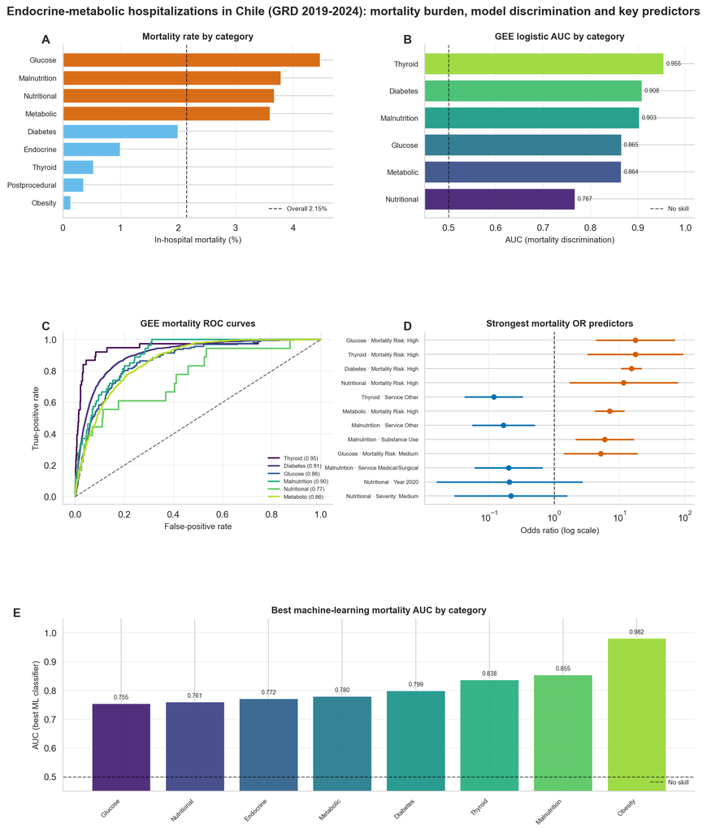

Figure 21: Composite mortality summary across endocrine-metabolic disease categories (GRD 2019-2024). (A) In-hospital mortality rate (%) by disease category relative to the overall cohort mean; (B) GEE logistic-regression discrimination (AUC) for in-hospital mortality per category; (C) ROC-curve overlay of the GEE mortality models; (D) strongest in-hospital mortality odds-ratio predictors across categories (forest plot, log scale, reference OR = 1); (E) best machine-learning classifier AUC for mortality per category with the no-skill reference at 0.5.

```python
import re as _re

# Okabe-Ito colorblind-safe categorical palette
_okabe_m = ['#E69F00', '#56B4E9', '#009E73', '#F0E442', '#0072B2', '#D55E00', '#CC79A7', '#000000']

def _short_cat_m(c):
    """Drop the 'Exx-Exx: ' code prefix for compact axis labels."""
    s = str(c)
    return s.split(':', 1)[1].strip() if ':' in s else s

def _parse_lead_m(txt):
    """Extract the leading numeric estimate from an 'OR [lo, hi]sig' string."""
    m = _re.match(r'\s*([0-9]*\.?[0-9]+)', str(txt))
    return float(m.group(1)) if m else np.nan

def _parse_ci_m(txt):
    """Extract (est, lo, hi) from an 'est [lo, hi]sig' string."""
    est = _parse_lead_m(txt)
    m = _re.search(r'\[\s*([0-9]*\.?[0-9]+)\s*,\s*([0-9]*\.?[0-9]+)\s*\]', str(txt))
    if m:
        return est, float(m.group(1)), float(m.group(2))
    return est, np.nan, np.nan

panel_labels_m = ['A', 'B', 'C', 'D', 'E']
fig = plt.figure(figsize=(11, 13))
gs = fig.add_gridspec(3, 2, hspace=0.66, wspace=0.34,
                      left=0.10, right=0.97, top=0.93, bottom=0.06)
axes = [fig.add_subplot(gs[0, 0]), fig.add_subplot(gs[0, 1]),
        fig.add_subplot(gs[1, 0]), fig.add_subplot(gs[1, 1]),
        fig.add_subplot(gs[2, :])]
for ax, lab in zip(axes, panel_labels_m):
    ax.text(-0.08, 1.06, lab, transform=ax.transAxes, fontsize=13,
            fontweight='bold', va='top')

# ---- Panel A: in-hospital mortality rate (%) by disease category ----
ax = axes[0]
try:
    mort = (df_endocrinas.groupby('endocrine_category')['mortality'].mean() * 100)
    mort = mort.dropna().sort_values(ascending=True)
    overall = df_endocrinas['mortality'].mean() * 100
    bar_colors = ['#D55E00' if v > overall else '#56B4E9' for v in mort.values]
    ax.barh(range(len(mort)), mort.values, color=bar_colors, alpha=0.9)
    ax.axvline(overall, color='black', ls='--', lw=1.0, alpha=0.7,
               label=f'Overall {overall:.2f}%')
    ax.set_yticks(range(len(mort)))
    ax.set_yticklabels([_short_cat_m(c) for c in mort.index], fontsize=8)
    ax.set_xlabel('In-hospital mortality (%)', fontsize=9)
    ax.set_title('Mortality rate by category', fontsize=10, fontweight='bold')
    ax.legend(fontsize=7, loc='lower right', frameon=False)
    sns.despine(ax=ax)
    ax.grid(True, axis='x', alpha=0.3)
except Exception as e:
    ax.axis('off'); ax.text(0.5, 0.5, 'panel unavailable', ha='center', va='center',
                            fontsize=8, transform=ax.transAxes)

# ---- Panel B: GEE mortality AUC per category ----
ax = axes[1]
try:
    rows_b = []
    for c in all_categories:
        if c not in gee_mortality_results:
            continue
        try:
            res = gee_mortality_results[c]
            df_g = gee_mortality_models[c][1]
            y_true = df_g['mortality'].values
            y_sc = np.asarray(res.fittedvalues, dtype=float)
            if len(np.unique(y_true)) < 2:
                continue
            rows_b.append((c, roc_auc_score(y_true, y_sc)))
        except Exception:
            continue
    if not rows_b:
        raise ValueError('no GEE AUCs')
    rows_b.sort(key=lambda r: r[1])
    cats_b = [r[0] for r in rows_b]
    aucs_b = [r[1] for r in rows_b]
    cmap_b = plt.cm.viridis(np.linspace(0.1, 0.85, len(cats_b)))
    ax.barh(range(len(cats_b)), aucs_b, color=cmap_b, alpha=0.95)
    ax.axvline(0.5, color='black', ls='--', lw=1.0, alpha=0.6, label='No skill')
    for yi, a in enumerate(aucs_b):
        ax.text(a + 0.005, yi, f'{a:.3f}', va='center', fontsize=6.5)
    ax.set_yticks(range(len(cats_b)))
    ax.set_yticklabels([_short_cat_m(c) for c in cats_b], fontsize=8)
    ax.set_xlim(0.45, 1.02)
    ax.set_xlabel('AUC (mortality discrimination)', fontsize=9)
    ax.set_title('GEE logistic AUC by category', fontsize=10, fontweight='bold')
    ax.legend(fontsize=7, loc='lower right', frameon=False)
    sns.despine(ax=ax)
    ax.grid(True, axis='x', alpha=0.3)
except Exception as e:
    ax.axis('off'); ax.text(0.5, 0.5, 'panel unavailable', ha='center', va='center',
                            fontsize=8, transform=ax.transAxes)

# ---- Panel C: ROC overlay of GEE mortality models ----
ax = axes[2]
try:
    cats_c = [c for c in all_categories if c in gee_mortality_results]
    cmap_c = plt.cm.viridis(np.linspace(0, 0.9, max(len(cats_c), 1)))
    plotted = 0
    for i, c in enumerate(cats_c):
        try:
            res = gee_mortality_results[c]
            df_g = gee_mortality_models[c][1]
            y_true = df_g['mortality'].values
            y_sc = np.asarray(res.fittedvalues, dtype=float)
            if len(np.unique(y_true)) < 2:
                continue
            fpr, tpr, _ = roc_curve(y_true, y_sc)
            a = roc_auc_score(y_true, y_sc)
            ax.plot(fpr, tpr, lw=1.6, color=cmap_c[i],
                    label=f'{_short_cat_m(c)} ({a:.2f})')
            plotted += 1
        except Exception:
            continue
    ax.plot([0, 1], [0, 1], 'k--', lw=1.0, alpha=0.6)
    ax.set_xlabel('False-positive rate', fontsize=9)
    ax.set_ylabel('True-positive rate', fontsize=9)
    ax.set_title('GEE mortality ROC curves', fontsize=10, fontweight='bold')
    if plotted:
        ax.legend(fontsize=6, loc='lower right', frameon=False, ncol=1)
    sns.despine(ax=ax)
    ax.grid(True, alpha=0.3)
except Exception as e:
    ax.axis('off'); ax.text(0.5, 0.5, 'panel unavailable', ha='center', va='center',
                            fontsize=8, transform=ax.transAxes)

# ---- Panel D: strongest mortality OR predictors (forest) ----
ax = axes[3]
try:
    or_rows = []
    for c in all_categories:
        cell_map = gee_or_table.get(c, {})
        for var, cell in cell_map.items():
            est, lo, hi = _parse_ci_m(cell)
            if not (np.isfinite(est) and np.isfinite(lo) and np.isfinite(hi)):
                continue
            if est <= 0 or est > 50:
                continue
            # strength = distance from OR = 1 on log scale, require finite CI
            or_rows.append((f'{_short_cat_m(c)} · {var}', est, lo, hi,
                            abs(np.log(est))))
    if not or_rows:
        raise ValueError('no OR predictors')
    or_rows.sort(key=lambda r: r[4])
    or_rows = or_rows[-12:]  # 12 strongest
    labels_d = [r[0] for r in or_rows]
    ests_d = np.array([r[1] for r in or_rows])
    los_d = np.array([r[2] for r in or_rows])
    his_d = np.array([r[3] for r in or_rows])
    for yi, (e, lo, hi) in enumerate(zip(ests_d, los_d, his_d)):
        col = '#D55E00' if e > 1 else '#0072B2'
        ax.plot([lo, hi], [yi, yi], color=col, lw=1.7, solid_capstyle='round', zorder=2)
        ax.plot([e], [yi], 'o', color=col, ms=5, zorder=3)
    ax.axvline(1.0, color='black', ls='--', lw=1.0, alpha=0.7, zorder=1)
    ax.set_xscale('log')
    ax.set_yticks(range(len(labels_d)))
    ax.set_yticklabels(labels_d, fontsize=6)
    ax.set_ylim(-0.6, len(labels_d) - 0.4)
    ax.set_xlabel('Odds ratio (log scale)', fontsize=9)
    ax.set_title('Strongest mortality OR predictors', fontsize=10, fontweight='bold')
    sns.despine(ax=ax)
    ax.grid(True, axis='x', alpha=0.3)
except Exception as e:
    ax.axis('off'); ax.text(0.5, 0.5, 'panel unavailable', ha='center', va='center',
                            fontsize=8, transform=ax.transAxes)

# ---- Panel E: best ML mortality AUC per category ----
ax = axes[4]
try:
    rows_e = []
    for c in all_categories:
        res = ml_models_by_cat.get(c)
        if not res:
            continue
        best_name = max(res, key=lambda k: res[k]['metrics']['AUC'])
        best_auc = res[best_name]['metrics']['AUC']
        if not np.isfinite(best_auc):
            continue
        rows_e.append((c, best_auc, best_name))
    if not rows_e:
        raise ValueError('no ML AUCs')
    rows_e.sort(key=lambda r: r[1])
    cats_e = [r[0] for r in rows_e]
    aucs_e = [r[1] for r in rows_e]
    x = np.arange(len(cats_e))
    cmap_e = plt.cm.viridis(np.linspace(0.1, 0.85, len(cats_e)))
    ax.bar(x, aucs_e, color=cmap_e, alpha=0.95)
    ax.axhline(0.5, color='black', ls='--', lw=1.0, alpha=0.6, label='No skill')
    for xi, a in enumerate(aucs_e):
        ax.text(xi, a + 0.01, f'{a:.3f}', ha='center', va='bottom', fontsize=6.5)
    ax.set_xticks(x)
    ax.set_xticklabels([_short_cat_m(c) for c in cats_e], rotation=45, ha='right', fontsize=7)
    ax.set_ylim(0.45, 1.05)
    ax.set_ylabel('AUC (best ML classifier)', fontsize=9)
    ax.set_title('Best machine-learning mortality AUC by category', fontsize=10, fontweight='bold')
    ax.legend(fontsize=7, loc='lower right', frameon=False)
    sns.despine(ax=ax)
    ax.grid(True, axis='y', alpha=0.3)
except Exception as e:
    ax.axis('off'); ax.text(0.5, 0.5, 'panel unavailable', ha='center', va='center',
                            fontsize=8, transform=ax.transAxes)

fig.suptitle('Endocrine-metabolic hospitalizations in Chile (GRD 2019-2024): '
             'mortality burden, model discrimination and key predictors',
             fontsize=13, fontweight='bold', y=0.975)

import os as _os
_os.makedirs('../data/output_files/endocrinas_parte2', exist_ok=True)
plt.savefig('../data/output_files/endocrinas_parte2/composite_mortality.png',
            dpi=1200, bbox_inches='tight', facecolor='white')
plt.show()
```

# 16 Composite Figure — Length of Stay and Comorbidity Burden

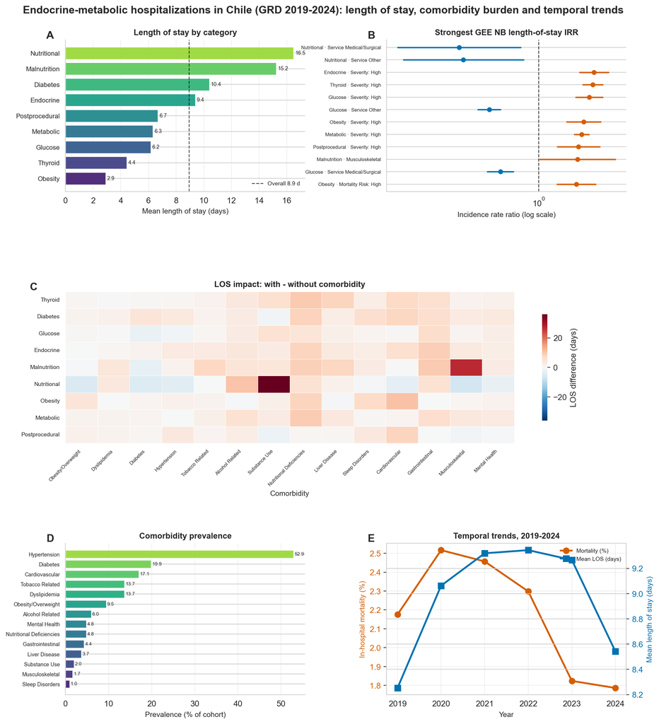

Figure 22: Composite length-of-stay and comorbidity summary across endocrine-metabolic disease categories (GRD 2019-2024). (A) Mean length of stay (days) by disease category; (B) GEE Negative-Binomial incidence-rate ratios for length of stay per category (forest plot, log scale, reference IRR = 1); (C) length-of-stay impact heatmap (mean days with minus without each comorbidity, by category); (D) comorbidity prevalence across the cohort (%); (E) temporal trends in overall in-hospital mortality and mean length of stay, 2019-2024.

```python
import re as _re2

_okabe_l = ['#E69F00', '#56B4E9', '#009E73', '#F0E442', '#0072B2', '#D55E00', '#CC79A7', '#000000']

def _short_cat_l(c):
    """Drop the 'Exx-Exx: ' code prefix for compact axis labels."""
    s = str(c)
    return s.split(':', 1)[1].strip() if ':' in s else s

def _parse_lead_l(txt):
    m = _re2.match(r'\s*([0-9]*\.?[0-9]+)', str(txt))
    return float(m.group(1)) if m else np.nan

def _parse_ci_l(txt):
    est = _parse_lead_l(txt)
    m = _re2.search(r'\[\s*([0-9]*\.?[0-9]+)\s*,\s*([0-9]*\.?[0-9]+)\s*\]', str(txt))
    if m:
        return est, float(m.group(1)), float(m.group(2))
    return est, np.nan, np.nan

panel_labels_l = ['A', 'B', 'C', 'D', 'E']
fig = plt.figure(figsize=(11, 13))
gs = fig.add_gridspec(3, 2, hspace=0.66, wspace=0.34,
                      left=0.10, right=0.97, top=0.93, bottom=0.07)
axes = [fig.add_subplot(gs[0, 0]), fig.add_subplot(gs[0, 1]),
        fig.add_subplot(gs[1, :]),
        fig.add_subplot(gs[2, 0]), fig.add_subplot(gs[2, 1])]
for ax, lab in zip(axes, panel_labels_l):
    ax.text(-0.08, 1.06, lab, transform=ax.transAxes, fontsize=13,
            fontweight='bold', va='top')

# ---- Panel A: mean LOS by disease category ----
ax = axes[0]
try:
    los = df_endocrinas.groupby('endocrine_category')['length_of_stay'].mean()
    los = los.dropna().sort_values(ascending=True)
    overall_los = df_endocrinas['length_of_stay'].mean()
    cmap_a = plt.cm.viridis(np.linspace(0.1, 0.85, len(los)))
    ax.barh(range(len(los)), los.values, color=cmap_a, alpha=0.95)
    ax.axvline(overall_los, color='black', ls='--', lw=1.0, alpha=0.7,
               label=f'Overall {overall_los:.1f} d')
    for yi, v in enumerate(los.values):
        ax.text(v + 0.1, yi, f'{v:.1f}', va='center', fontsize=6.5)
    ax.set_yticks(range(len(los)))
    ax.set_yticklabels([_short_cat_l(c) for c in los.index], fontsize=8)
    ax.set_xlabel('Mean length of stay (days)', fontsize=9)
    ax.set_title('Length of stay by category', fontsize=10, fontweight='bold')
    ax.legend(fontsize=7, loc='lower right', frameon=False)
    sns.despine(ax=ax)
    ax.grid(True, axis='x', alpha=0.3)
except Exception as e:
    ax.axis('off'); ax.text(0.5, 0.5, 'panel unavailable', ha='center', va='center',
                            fontsize=8, transform=ax.transAxes)

# ---- Panel B: GEE Negative-Binomial IRR by category (forest) ----
ax = axes[1]
try:
    irr_rows = []
    for c in all_categories:
        cell_map = gee_irr_table.get(c, {})
        for var, cell in cell_map.items():
            est, lo, hi = _parse_ci_l(cell)
            if not (np.isfinite(est) and np.isfinite(lo) and np.isfinite(hi)):
                continue
            if est <= 0 or est > 50:
                continue
            irr_rows.append((f'{_short_cat_l(c)} · {var}', est, lo, hi, abs(np.log(est))))
    if not irr_rows:
        raise ValueError('no IRR predictors')
    irr_rows.sort(key=lambda r: r[4])
    irr_rows = irr_rows[-12:]  # 12 strongest
    labels_b = [r[0] for r in irr_rows]
    ests_b = np.array([r[1] for r in irr_rows])
    los_b = np.array([r[2] for r in irr_rows])
    his_b = np.array([r[3] for r in irr_rows])
    for yi, (e, lo, hi) in enumerate(zip(ests_b, los_b, his_b)):
        col = '#D55E00' if e > 1 else '#0072B2'
        ax.plot([lo, hi], [yi, yi], color=col, lw=1.7, solid_capstyle='round', zorder=2)
        ax.plot([e], [yi], 'o', color=col, ms=5, zorder=3)
    ax.axvline(1.0, color='black', ls='--', lw=1.0, alpha=0.7, zorder=1)
    ax.set_xscale('log')
    ax.set_yticks(range(len(labels_b)))
    ax.set_yticklabels(labels_b, fontsize=6)
    ax.set_ylim(-0.6, len(labels_b) - 0.4)
    ax.set_xlabel('Incidence rate ratio (log scale)', fontsize=9)
    ax.set_title('Strongest GEE NB length-of-stay IRR', fontsize=10, fontweight='bold')
    sns.despine(ax=ax)
    ax.grid(True, axis='x', alpha=0.3)
except Exception as e:
    ax.axis('off'); ax.text(0.5, 0.5, 'panel unavailable', ha='center', va='center',
                            fontsize=8, transform=ax.transAxes)

# ---- Panel C: LOS-impact comorbidity heatmap ----
ax = axes[2]
try:
    hm = heatmap_los_impact_df.copy()
    hm.index = [_short_cat_l(c) for c in hm.index]
    vmax = float(np.nanmax(np.abs(hm.values))) if hm.size else 1.0
    vmax = vmax if np.isfinite(vmax) and vmax > 0 else 1.0
    sns.heatmap(hm, ax=ax, cmap='RdBu_r', center=0, vmin=-vmax, vmax=vmax,
                cbar_kws={'label': 'LOS difference (days)', 'shrink': 0.7},
                linewidths=0.3, linecolor='white')
    ax.set_title('LOS impact: with - without comorbidity', fontsize=10, fontweight='bold')
    ax.set_xlabel('Comorbidity', fontsize=9)
    ax.set_ylabel('')
    plt.setp(ax.get_xticklabels(), rotation=45, ha='right', fontsize=6)
    plt.setp(ax.get_yticklabels(), rotation=0, fontsize=7)
except Exception as e:
    ax.axis('off'); ax.text(0.5, 0.5, 'panel unavailable', ha='center', va='center',
                            fontsize=8, transform=ax.transAxes)

# ---- Panel D: comorbidity prevalence across cohort ----
ax = axes[3]
try:
    prev = comor_pct.copy()
    prev.index = [format_name('comor_' + str(i)) for i in prev.index]
    prev = prev.sort_values(ascending=True)
    cmap_d = plt.cm.viridis(np.linspace(0.1, 0.85, len(prev)))
    ax.barh(range(len(prev)), prev.values, color=cmap_d, alpha=0.95)
    for yi, v in enumerate(prev.values):
        ax.text(v + 0.2, yi, f'{v:.1f}', va='center', fontsize=6)
    ax.set_yticks(range(len(prev)))
    ax.set_yticklabels(prev.index, fontsize=6.5)
    ax.set_xlabel('Prevalence (% of cohort)', fontsize=9)
    ax.set_title('Comorbidity prevalence', fontsize=10, fontweight='bold')
    sns.despine(ax=ax)
    ax.grid(True, axis='x', alpha=0.3)
except Exception as e:
    ax.axis('off'); ax.text(0.5, 0.5, 'panel unavailable', ha='center', va='center',
                            fontsize=8, transform=ax.transAxes)

# ---- Panel E: temporal mortality and LOS trends ----
ax = axes[4]
try:
    mort_yr = df_endocrinas.groupby('year')['mortality'].mean() * 100
    los_yr = df_endocrinas.groupby('year')['length_of_stay'].mean()
    yrs = mort_yr.index.values
    ln1 = ax.plot(yrs, mort_yr.values, marker='o', lw=2.2, ms=7,
                  color='#D55E00', label='Mortality (%)')
    ax.set_xlabel('Year', fontsize=9)
    ax.set_ylabel('In-hospital mortality (%)', fontsize=9, color='#D55E00')
    ax.tick_params(axis='y', labelcolor='#D55E00')
    ax2 = ax.twinx()
    ln2 = ax2.plot(yrs, los_yr.values, marker='s', lw=2.2, ms=7,
                   color='#0072B2', label='Mean LOS (days)')
    ax2.set_ylabel('Mean length of stay (days)', fontsize=9, color='#0072B2')
    ax2.tick_params(axis='y', labelcolor='#0072B2')
    ax.set_title('Temporal trends, 2019-2024', fontsize=10, fontweight='bold')
    lns = ln1 + ln2
    ax.legend(lns, [l.get_label() for l in lns], fontsize=7, loc='best', frameon=False)
    ax.set_xticks(yrs)
    ax.grid(True, alpha=0.3)
    sns.despine(ax=ax, right=False)
except Exception as e:
    ax.axis('off'); ax.text(0.5, 0.5, 'panel unavailable', ha='center', va='center',
                            fontsize=8, transform=ax.transAxes)

fig.suptitle('Endocrine-metabolic hospitalizations in Chile (GRD 2019-2024): '
             'length of stay, comorbidity burden and temporal trends',
             fontsize=13, fontweight='bold', y=0.975)

import os as _os2
_os2.makedirs('../data/output_files/endocrinas_parte2', exist_ok=True)
plt.savefig('../data/output_files/endocrinas_parte2/composite_los_comorbidity.png',
            dpi=1200, bbox_inches='tight', facecolor='white')
plt.show()
```